# Match Dashboard

Brentford vs Everton - 23-11-2026

|  | Possession Possession % | Possession On Ball Time | Possession Touches | Possession PKBox Touches | Possession Field Tilt % | Shots Total Shots | Shots OFF Shots | Shots ONT Shots | Shots 6yrd box Shots | Shots PK Box Shots | Shots Outside Box Shots | Shots Blocked Shots | Shots BCs | Shots Goals | Shots xG | Shots NPxG | Shots xGOT | Threat EPV | Threat EPV % xG Con. | Threat EPV % NPxG Con. | Passes Attempted Passes | Passes Successful Passes | Passes Pass Success % | Passes Long Passes | Passes Long Ball Rate | Passes Crosses | Passes Cross Success % | Passes Corners | Passes Short Corners | … |
| --- | --- | --- | --- | --- | --- | --- | --- | --- | --- | --- | --- | --- | --- | --- | --- | --- | --- | --- | --- | --- | --- | --- | --- | --- | --- | --- | --- | --- | --- | --- |
| 1st Quarter |  |  |  |  |  |  |  |  |  |  |  |  |  |  |  |  |  |  |  |  |  |  |  |  |  |  |  |  |  | … |
| Brentford | 57.4% | 14.20 | 213 | 9 | 68.8% | 6 | 1 | 3 | 0 | 6 | 0 | 2 | 1 | 2 | 0.73 | 0.73 | 1.24 | 0.48 | 153.7% | 153.7% | 164 | 139 | 84.8% | 16 | 9.8% | 8 | 0.0% | 2 | 0 | … |
| Everton | 42.6% | 9.00 | 158 | 1 | 31.2% | 0 | 0 | 0 | 0 | 0 | 0 | 0 | 0 | 0 | 0.00 | 0.00 | 0.00 | 0.25 | 0.0% | 0.0% | 112 | 85 | 75.9% | 14 | 12.5% | 2 | 0.0% | 0 | 0 | … |
| 2nd Quarter |  |  |  |  |  |  |  |  |  |  |  |  |  |  |  |  |  |  |  |  |  |  |  |  |  |  |  |  |  | … |
| Brentford | 62.9% | 10.90 | 156 | 11 | 83.5% | 6 | 0 | 2 | 1 | 3 | 3 | 4 | 0 | 0 | 0.37 | 0.37 | 0.10 | 1.06 | 34.7% | 34.7% | 120 | 105 | 87.5% | 7 | 5.8% | 5 | 60.0% | 1 | 0 | … |
| Everton | 37.1% | 3.90 | 92 | 0 | 16.5% | 2 | 1 | 1 | 0 | 0 | 2 | 0 | 0 | 0 | 0.04 | 0.04 | 0.09 | 0.14 | 28.0% | 28.0% | 44 | 27 | 61.4% | 14 | 31.8% | 2 | 50.0% | 2 | 1 | … |
| 3rd Quarter |  |  |  |  |  |  |  |  |  |  |  |  |  |  |  |  |  |  |  |  |  |  |  |  |  |  |  |  |  | … |
| Brentford | 67.8% | 13.20 | 261 | 18 | 87.6% | 3 | 2 | 1 | 1 | 2 | 1 | 0 | 1 | 1 | 0.37 | 0.37 | 0.19 | 1.45 | 25.4% | 25.4% | 210 | 190 | 90.5% | 7 | 3.3% | 10 | 20.0% | 1 | 0 | … |
| Everton | 32.2% | 6.30 | 124 | 1 | 12.4% | 0 | 0 | 0 | 0 | 0 | 0 | 0 | 0 | 0 | 0.00 | 0.00 | 0.00 | 0.17 | 0.0% | 0.0% | 77 | 54 | 70.1% | 16 | 20.8% | 2 | 0.0% | 0 | 0 | … |
| 4th Quarter |  |  |  |  |  |  |  |  |  |  |  |  |  |  |  |  |  |  |  |  |  |  |  |  |  |  |  |  |  | … |
| Brentford | 77.5% | 15.80 | 268 | 13 | 95.7% | 5 | 1 | 1 | 1 | 5 | 0 | 3 | 1 | 1 | 1.00 | 1.00 | 0.85 | 1.76 | 56.9% | 56.9% | 234 | 218 | 93.2% | 11 | 4.7% | 6 | 33.3% | 2 | 0 | … |
| Everton | 22.5% | 4.30 | 78 | 1 | 4.3% | 1 | 0 | 0 | 0 | 1 | 0 | 1 | 0 | 0 | 0.08 | 0.08 | 0.00 | 0.08 | 98.8% | 98.8% | 46 | 26 | 56.5% | 12 | 26.1% | 0 | 0.0% | 0 | 0 | … |
| Injury Time |  |  |  |  |  |  |  |  |  |  |  |  |  |  |  |  |  |  |  |  |  |  |  |  |  |  |  |  |  | … |
| Brentford | 61.6% | 1.40 | 61 | 2 | 88.2% | 1 | 0 | 0 | 0 | 1 | 0 | 1 | 0 | 0 | 0.11 | 0.11 | 0.00 | 0.21 | 51.4% | 51.4% | 43 | 39 | 90.7% | 1 | 2.3% | 2 | 50.0% | 0 | 0 | … |
| Everton | 38.4% | 0.60 | 38 | 3 | 11.8% | 1 | 0 | 1 | 0 | 1 | 0 | 0 | 1 | 0 | 0.12 | 0.12 | 0.47 | 0.03 | 428.6% | 428.6% | 24 | 18 | 75.0% | 2 | 8.3% | 2 | 0.0% | 1 | 0 | … |

X @Barts78 · Bluesky @barts78 · Mastodon @DrBarts · GitHub Barts78 · LinkedIn Phil-barter · Data: Opta

**Match Summary - By Game State**

Brentford vs Everton - 23-11-2026

|  | Possession Possession % | Possession On Ball Time | Possession Touches | Possession PKBox Touches | Possession Field Tilt % | Shots Total Shots | Shots OFF Shots | Shots SoT | Shots 6yrd box Shots | Shots PK Box Shots | Shots Outside Box Shots | Shots Blocked Shots | Shots BCs | Shots Goals | Shots xG | Shots NPxG | Shots xGOT | Threat EPV | Threat EPV % xG Con. | Threat EPV % NPxG Con. | Passes Attempted Passes | Passes Successful Passes | Passes Pass Success % | Passes Long Passes | Passes Long Ball Rate | Passes Crosses | Passes Cross Success % | Passes Corners | Passes Short Corners | … |
| --- | --- | --- | --- | --- | --- | --- | --- | --- | --- | --- | --- | --- | --- | --- | --- | --- | --- | --- | --- | --- | --- | --- | --- | --- | --- | --- | --- | --- | --- | --- |
| Draw |  |  |  |  |  |  |  |  |  |  |  |  |  |  |  |  |  |  |  |  |  |  |  |  |  |  |  |  |  | … |
| Brentford | 57.5% | 12.80 | 207 | 7 | 66.1% | 4 | 1 | 2 | 0 | 4 | 0 | 1 | 1 | 1 | 0.45 | 0.45 | 0.56 | 0.47 | 95.1% | 95.1% | 164 | 139 | 84.8% | 16 | 9.8% | 7 | 0.0% | 2 | 0 | … |
| Everton | 42.5% | 8.80 | 153 | 1 | 33.9% | 0 | 0 | 0 | 0 | 0 | 0 | 0 | 0 | 0 | 0.00 | 0.00 | 0.00 | 0.25 | 0.0% | 0.0% | 110 | 84 | 76.4% | 13 | 11.8% | 2 | 0.0% | 0 | 0 | … |
| Home Garbage Time |  |  |  |  |  |  |  |  |  |  |  |  |  |  |  |  |  |  |  |  |  |  |  |  |  |  |  |  |  | … |
| Brentford | 69.2% | 41.30 | 746 | 44 | 88.9% | 15 | 3 | 4 | 3 | 11 | 4 | 8 | 2 | 2 | 1.85 | 1.85 | 1.14 | 4.49 | 41.2% | 41.2% | 607 | 552 | 90.9% | 26 | 4.3% | 23 | 34.8% | 4 | 0 | … |
| Everton | 30.8% | 15.00 | 332 | 5 | 11.1% | 4 | 1 | 2 | 0 | 2 | 2 | 1 | 1 | 0 | 0.24 | 0.24 | 0.56 | 0.42 | 57.6% | 57.6% | 191 | 125 | 65.4% | 44 | 23.0% | 6 | 16.7% | 3 | 1 | … |
| Home Lead |  |  |  |  |  |  |  |  |  |  |  |  |  |  |  |  |  |  |  |  |  |  |  |  |  |  |  |  |  | … |
| Brentford | 54.5% | 1.40 | 6 | 2 | 100.0% | 2 | 0 | 1 | 0 | 2 | 0 | 1 | 0 | 1 | 0.28 | 0.28 | 0.68 | 0.00 | 14,000.0% | 14,000.0% | 0 | 0 | 0.0% | 0 | 0.0% | 1 | 0.0% | 0 | 0 | … |
| Everton | 45.5% | 0.20 | 5 | 0 | 0.0% | 0 | 0 | 0 | 0 | 0 | 0 | 0 | 0 | 0 | 0.00 | 0.00 | 0.00 | 0.01 | 0.0% | 0.0% | 2 | 1 | 50.0% | 1 | 50.0% | 0 | 0.0% | 0 | 0 | … |

X @Barts78 · Bluesky @barts78 · Mastodon @DrBarts · GitHub Barts78 · LinkedIn Phil-barter · Data: Opta

**Season Summary Tables**

**Season Summary - Full Games**

Up to Brentford vs Everton - 23-11-2026

| Possession % | Touches | PKBox Touches | Field Tilt % | Total Shots | OFF Shots | SoT | 6yrd box Shots | PK Box Shots | Outside Box Shots | BCs | Goals | xG | NPxG | xGOT | EPV | EPV % xG Con. | Attempted Passes | Successful Passes | Pass Success % | Long Passes | Long Ball Rate | Crosses | Cross Success % | Corners | Short Corners | Possession Control | Poss Control /100 Touches | EPV % NPxG Con. |
| --- | --- | --- | --- | --- | --- | --- | --- | --- | --- | --- | --- | --- | --- | --- | --- | --- | --- | --- | --- | --- | --- | --- | --- | --- | --- | --- | --- | --- |
| All Oppo |  |  |  |  |  |  |  |  |  |  |  |  |  |  |  |  |  |  |  |  |  |  |  |  |  |  |  |  |
| 53.6% | 7,816 | 337 | 55.3% | 169 | 58 | 45 | 21 | 107 | 62 | 29 | 14 | 17.00 | 17.00 | 13.37 | 28.88 | 58.9% | 5613 | 4777 | 85.1% | 529 | 9.4% | 210 | 23.3% | 60 | 6 | -928 | -11.9 | 58.9% |
| Everton |  |  |  |  |  |  |  |  |  |  |  |  |  |  |  |  |  |  |  |  |  |  |  |  |  |  |  |  |
| 46.4% | 6,766 | 270 | 44.7% | 144 | 54 | 50 | 15 | 103 | 41 | 32 | 12 | 14.12 | 14.12 | 14.14 | 22.62 | 62.4% | 4554 | 3741 | 82.1% | 563 | 12.4% | 196 | 20.4% | 49 | 9 | -718 | -10.6 | 62.4% |

X @Barts78 · Bluesky @barts78 · Mastodon @DrBarts · GitHub Barts78 · LinkedIn Phil-barter · Data: Opta

**Season Summary - By Half**

Up to Brentford vs Everton - 23-11-2026

|  | Possession Possession % | Possession Touches | Possession PKBox Touches | Possession Field Tilt % | Shots Total Shots | Shots OFF Shots | Shots SoT | Shots 6yrd box Shots | Shots PK Box Shots | Shots Outside Box Shots | Shots BCs | Shots Goals | Shots xG | Shots NPxG | Shots xGOT | Threat EPV | Threat EPV % xG Con. | Threat EPV % NPxG Con. | Passes Attempted Passes | Passes Successful Passes | Passes Pass Success % | Passes Long Passes | Passes Long Ball Rate | Passes Crosses | Passes Cross Success % | Passes Corners | Passes Short Corners | Possession Control | Poss Control /100 Touches | … |
| --- | --- | --- | --- | --- | --- | --- | --- | --- | --- | --- | --- | --- | --- | --- | --- | --- | --- | --- | --- | --- | --- | --- | --- | --- | --- | --- | --- | --- | --- | --- |
| First Half |  |  |  |  |  |  |  |  |  |  |  |  |  |  |  |  |  |  |  |  |  |  |  |  |  |  |  |  |  | … |
| All Oppo | 52.8% | 3,857 | 157 | 55.1% | 82 | 28 | 21 | 11 | 53 | 29 | 12 | 4 | 7.98 | 7.98 | 5.13 | 13.12 | 60.8% | 60.8% | 2765 | 2350 | 85.0% | 256 | 9.3% | 104 | 21.1% | 35 | 2 |  |  | … |
| Everton | 47.2% | 3,445 | 121 | 44.9% | 67 | 27 | 20 | 5 | 42 | 25 | 15 | 2 | 6.11 | 6.11 | 4.47 | 10.20 | 59.9% | 59.9% | 2325 | 1923 | 82.7% | 275 | 11.8% | 96 | 19.8% | 24 | 6 | -368 | -10.7 | … |
| Second Half |  |  |  |  |  |  |  |  |  |  |  |  |  |  |  |  |  |  |  |  |  |  |  |  |  |  |  |  |  | … |
| All Oppo | 54.4% | 3,959 | 180 | 55.5% | 87 | 30 | 24 | 10 | 54 | 33 | 17 | 10 | 9.02 | 9.02 | 8.24 | 15.76 | 57.2% | 57.2% | 2848 | 2427 | 85.2% | 273 | 9.6% | 106 | 25.5% | 25 | 4 | -462 | -11.7 | … |
| Everton | 45.6% | 3,321 | 149 | 44.5% | 77 | 27 | 30 | 10 | 61 | 16 | 17 | 10 | 8.01 | 8.01 | 9.67 | 12.41 | 64.5% | 64.5% | 2229 | 1818 | 81.6% | 288 | 12.9% | 100 | 21.0% | 25 | 3 | -350 | -10.5 | … |

X @Barts78 · Bluesky @barts78 · Mastodon @DrBarts · GitHub Barts78 · LinkedIn Phil-barter · Data: Opta

**Season Summary - By Game Period**

Up to Brentford vs Everton - 23-11-2026

|  | Possession Possession % | Possession Touches | Possession PKBox Touches | Possession Field Tilt % | Shots Total Shots | Shots OFF Shots | Shots ONT Shots | Shots 6yrd box Shots | Shots PK Box Shots | Shots Outside Box Shots | Shots BCs | Shots Goals | Shots xG | Shots NPxG | Shots xGOT | Threat EPV | Threat EPV % xG Con. | Threat EPV % NPxG Con. | Passes Attempted Passes | Passes Successful Passes | Passes Pass Success % | Passes Long Passes | Passes Long Ball Rate | Passes Crosses | Passes Cross Success % | Passes Corners | Passes Short Corners | Possession Control | Poss Control /100 Touches | … |
| --- | --- | --- | --- | --- | --- | --- | --- | --- | --- | --- | --- | --- | --- | --- | --- | --- | --- | --- | --- | --- | --- | --- | --- | --- | --- | --- | --- | --- | --- | --- |
| 0 - 15 |  |  |  |  |  |  |  |  |  |  |  |  |  |  |  |  |  |  |  |  |  |  |  |  |  |  |  |  |  | … |
| All Oppo | 51.4% | 1,339 | 45 | 50.3% | 19 | 4 | 7 | 5 | 13 | 6 | 4 | 1 | 1.69 | 1.69 | 1.92 | 3.66 | 46.2% | 46.2% | 995 | 827 | 83.1% | 101 | 10.2% | 32 | 18.8% | 9 | 0 |  |  | … |
| Everton | 48.6% | 1,265 | 29 | 49.7% | 18 | 8 | 6 | 1 | 7 | 11 | 3 | 1 | 1.45 | 1.45 | 1.64 | 3.00 | 48.4% | 48.4% | 891 | 742 | 83.3% | 112 | 12.6% | 27 | 11.1% | 6 | 2 | -135 | -10.7 | … |
| 16 - 30 |  |  |  |  |  |  |  |  |  |  |  |  |  |  |  |  |  |  |  |  |  |  |  |  |  |  |  |  |  | … |
| All Oppo | 54.0% | 1,230 | 50 | 56.8% | 30 | 11 | 8 | 2 | 20 | 10 | 2 | 2 | 2.86 | 2.86 | 1.87 | 3.76 | 76.1% | 76.1% | 887 | 784 | 88.4% | 74 | 8.3% | 28 | 14.3% | 8 | 1 | -132 | -10.7 | … |
| Everton | 46.0% | 1,047 | 44 | 43.2% | 21 | 10 | 7 | 2 | 13 | 8 | 5 | 0 | 2.08 | 2.08 | 1.20 | 3.56 | 58.5% | 58.5% | 719 | 590 | 82.1% | 82 | 11.4% | 27 | 18.5% | 8 | 2 | -135 | -12.9 | … |
| 31 - 45 |  |  |  |  |  |  |  |  |  |  |  |  |  |  |  |  |  |  |  |  |  |  |  |  |  |  |  |  |  | … |
| All Oppo | 53.2% | 1,288 | 62 | 57.6% | 33 | 13 | 6 | 4 | 20 | 13 | 6 | 1 | 3.43 | 3.43 | 1.34 | 5.70 | 60.2% | 60.2% | 883 | 739 | 83.7% | 81 | 9.2% | 44 | 27.3% | 18 | 1 | -179 | -13.9 | … |
| Everton | 46.8% | 1,133 | 48 | 42.4% | 28 | 9 | 7 | 2 | 22 | 6 | 7 | 1 | 2.58 | 2.58 | 1.63 | 3.65 | 70.7% | 70.7% | 715 | 591 | 82.7% | 81 | 11.3% | 42 | 26.2% | 10 | 2 | -98 | -8.6 | … |
| 46 - 60 |  |  |  |  |  |  |  |  |  |  |  |  |  |  |  |  |  |  |  |  |  |  |  |  |  |  |  |  |  | … |
| All Oppo | 55.8% | 1,340 | 56 | 55.4% | 23 | 6 | 9 | 1 | 11 | 12 | 5 | 4 | 2.11 | 2.11 | 2.95 | 4.23 | 49.9% | 49.9% | 990 | 837 | 84.5% | 99 | 10.0% | 33 | 12.1% | 9 | 1 | -171 | -12.8 | … |
| Everton | 44.2% | 1,060 | 52 | 44.6% | 26 | 3 | 14 | 8 | 22 | 4 | 11 | 5 | 4.45 | 4.45 | 5.82 | 4.79 | 93.0% | 93.0% | 675 | 534 | 79.1% | 91 | 13.5% | 42 | 23.8% | 10 | 1 | -106 | -10.0 | … |
| 61 - 75 |  |  |  |  |  |  |  |  |  |  |  |  |  |  |  |  |  |  |  |  |  |  |  |  |  |  |  |  |  | … |
| All Oppo | 55.7% | 1,072 | 52 | 58.9% | 25 | 11 | 5 | 4 | 14 | 11 | 4 | 3 | 2.56 | 2.56 | 2.09 | 4.86 | 52.7% | 52.7% | 775 | 677 | 87.4% | 59 | 7.6% | 25 | 40.0% | 6 | 1 | -118 | -11.0 | … |
| Everton | 44.3% | 853 | 38 | 41.1% | 23 | 13 | 6 | 2 | 20 | 3 | 5 | 1 | 2.10 | 2.10 | 1.86 | 3.11 | 67.5% | 67.5% | 578 | 483 | 83.6% | 62 | 10.7% | 28 | 17.9% | 6 | 1 | -72 | -8.4 | … |
| 76 - 90 |  |  |  |  |  |  |  |  |  |  |  |  |  |  |  |  |  |  |  |  |  |  |  |  |  |  |  |  |  | … |
| All Oppo | 53.8% | 1,126 | 62 | 59.0% | 32 | 8 | 9 | 4 | 23 | 9 | 8 | 3 | 3.58 | 3.58 | 3.09 | 5.50 | 65.1% | 65.1% | 795 | 696 | 87.5% | 67 | 8.4% | 40 | 27.5% | 10 | 2 | -109 | -9.7 | … |
| Everton | 46.2% | 967 | 35 | 41.0% | 20 | 8 | 7 | 0 | 13 | 7 | 1 | 3 | 1.01 | 1.01 | 1.53 | 2.96 | 34.1% | 34.1% | 667 | 560 | 84.0% | 86 | 12.9% | 19 | 26.3% | 7 | 1 | -110 | -11.4 | … |
| 90 + |  |  |  |  |  |  |  |  |  |  |  |  |  |  |  |  |  |  |  |  |  |  |  |  |  |  |  |  |  | … |
| All Oppo | 48.8% | 421 | 10 | 38.1% | 7 | 5 | 1 | 1 | 6 | 1 | 0 | 0 | 0.77 | 0.77 | 0.11 | 1.18 | 65.4% | 65.4% | 288 | 217 | 75.3% | 48 | 16.7% | 8 | 25.0% | 0 | 0 | -64 | -15.2 | … |
| Everton | 51.2% | 441 | 24 | 61.9% | 8 | 3 | 3 | 0 | 6 | 2 | 0 | 1 | 0.45 | 0.45 | 0.46 | 1.55 | 28.9% | 28.9% | 309 | 241 | 78.0% | 49 | 15.9% | 11 | 9.1% | 2 | 0 | -62 | -14.1 | … |

X @Barts78 · Bluesky @barts78 · Mastodon @DrBarts · GitHub Barts78 · LinkedIn Phil-barter · Data: Opta

**Season Summary - By Game State**

Up to Brentford vs Everton - 23-11-2026

|  | Possession Possession % | Possession Touches | Possession PKBox Touches | Possession Field Tilt % | Shots Total Shots | Shots OFF Shots | Shots SoT | Shots 6yrd box Shots | Shots PK Box Shots | Shots Outside Box Shots | Shots BCs | Shots Goals | Shots xG | Shots NPxG | Shots xGOT | Threat EPV | Threat EPV % xG Con. | Threat EPV % NPxG Con. | Passes Attempted Passes | Passes Successful Passes | Passes Pass Success % | Passes Long Passes | Passes Long Ball Rate | Passes Crosses | Passes Cross Success % | Passes Corners | Passes Short Corners | Possession Control | Poss Control /100 Touches | … |
| --- | --- | --- | --- | --- | --- | --- | --- | --- | --- | --- | --- | --- | --- | --- | --- | --- | --- | --- | --- | --- | --- | --- | --- | --- | --- | --- | --- | --- | --- | --- |
| Away Garbage Time |  |  |  |  |  |  |  |  |  |  |  |  |  |  |  |  |  |  |  |  |  |  |  |  |  |  |  |  |  | … |
| All Oppo | 39.9% | 69 | 0 | 37.5% | 0 | 0 | 0 | 0 | 0 | 0 | 0 | 0 | 0.00 | 0.00 | 0.00 | 0.12 | 0.0% | 0.0% | 47 | 33 | 70.2% | 12 | 25.5% | 0 | 0.0% | 0 | 0 |  |  | … |
| Everton | 60.1% | 104 | 1 | 62.5% | 0 | 0 | 0 | 0 | 0 | 0 | 0 | 0 | 0.00 | 0.00 | 0.00 | 0.33 | 0.0% | 0.0% | 80 | 62 | 77.5% | 10 | 12.5% | 4 | 0.0% | 1 | 0 | -18 | -17.3 | … |
| Away Lead |  |  |  |  |  |  |  |  |  |  |  |  |  |  |  |  |  |  |  |  |  |  |  |  |  |  |  |  |  | … |
| All Oppo | 52.0% | 885 | 46 | 46.5% | 30 | 15 | 6 | 3 | 15 | 15 | 4 | 2 | 2.16 | 2.16 | 1.76 | 2.91 | 74.1% | 74.1% | 592 | 505 | 85.3% | 56 | 9.5% | 24 | 29.2% | 6 | 2 | -100 | -11.3 | … |
| Everton | 48.0% | 816 | 47 | 53.5% | 20 | 5 | 10 | 2 | 16 | 4 | 1 | 3 | 1.16 | 1.16 | 2.84 | 3.40 | 34.1% | 34.1% | 557 | 457 | 82.0% | 72 | 12.9% | 29 | 24.1% | 10 | 2 | -104 | -12.7 | … |
| Draw |  |  |  |  |  |  |  |  |  |  |  |  |  |  |  |  |  |  |  |  |  |  |  |  |  |  |  |  |  | … |
| All Oppo | 52.0% | 3,786 | 153 | 52.7% | 74 | 22 | 25 | 8 | 46 | 28 | 13 | 8 | 7.20 | 7.20 | 7.37 | 12.07 | 59.7% | 59.7% | 2710 | 2287 | 84.4% | 277 | 10.2% | 100 | 19.0% | 29 | 2 | -471 | -12.4 | … |
| Everton | 48.0% | 3,493 | 141 | 47.3% | 72 | 30 | 23 | 10 | 52 | 20 | 20 | 5 | 7.98 | 7.98 | 6.98 | 11.59 | 68.8% | 68.8% | 2372 | 1977 | 83.3% | 271 | 11.4% | 98 | 22.4% | 19 | 4 | -364 | -10.4 | … |
| Home Garbage Time |  |  |  |  |  |  |  |  |  |  |  |  |  |  |  |  |  |  |  |  |  |  |  |  |  |  |  |  |  | … |
| All Oppo | 61.9% | 1,377 | 55 | 71.6% | 23 | 7 | 6 | 3 | 15 | 8 | 2 | 2 | 2.52 | 2.52 | 1.27 | 6.22 | 40.5% | 40.5% | 1075 | 964 | 89.7% | 54 | 5.0% | 35 | 28.6% | 4 | 0 | -124 | -9.0 | … |
| Everton | 38.1% | 849 | 31 | 28.4% | 17 | 6 | 7 | 0 | 13 | 4 | 3 | 0 | 1.08 | 1.08 | 1.14 | 2.13 | 50.7% | 50.7% | 554 | 432 | 78.0% | 92 | 16.6% | 15 | 26.7% | 3 | 1 | -83 | -9.8 | … |
| Home Lead |  |  |  |  |  |  |  |  |  |  |  |  |  |  |  |  |  |  |  |  |  |  |  |  |  |  |  |  |  | … |
| All Oppo | 53.0% | 1,699 | 83 | 54.4% | 42 | 14 | 8 | 7 | 31 | 11 | 10 | 2 | 5.12 | 5.12 | 2.97 | 7.56 | 67.7% | 67.7% | 1189 | 988 | 83.1% | 130 | 10.9% | 51 | 25.5% | 21 | 2 | -224 | -13.2 | … |
| Everton | 47.0% | 1,504 | 50 | 45.6% | 35 | 13 | 10 | 3 | 22 | 13 | 8 | 4 | 3.90 | 3.90 | 3.18 | 5.16 | 75.5% | 75.5% | 991 | 813 | 82.0% | 118 | 11.9% | 50 | 14.0% | 16 | 2 | -149 | -9.9 | … |

X @Barts78 · Bluesky @barts78 · Mastodon @DrBarts · GitHub Barts78 · LinkedIn Phil-barter · Data: Opta

**Season Summary - By Match Day**

Up to Brentford vs Everton - 23-11-2026

|  | Fixture | Possession Possession % | Possession Touches | Possession PKBox Touches | Possession Field Tilt % | Shots Total Shots | Shots OFF Shots | Shots SoT | Shots 6yrd box Shots | Shots PK Box Shots | Shots Outside Box Shots | Shots BCs | Shots Goals | Shots xG | Shots NPxG | Shots xGOT | Threat EPV | Threat EPV % xG Con. | Threat EPV % NPxG Con. | Passes Attempted Passes | Passes Successful Passes | Passes Pass Success % | Passes Long Passes | Passes Long Ball Rate | Passes Crosses | Passes Cross Success % | Passes Corners | Passes Short Corners | Possession Control | … |
| --- | --- | --- | --- | --- | --- | --- | --- | --- | --- | --- | --- | --- | --- | --- | --- | --- | --- | --- | --- | --- | --- | --- | --- | --- | --- | --- | --- | --- | --- | --- |
| 1 |  |  |  |  |  |  |  |  |  |  |  |  |  |  |  |  |  |  |  |  |  |  |  |  |  |  |  |  |  | … |
| All Oppo | Everton vs Crystal Palace | 55.5% | 807 | 16 | 48.4% | 11 | 4 | 4 | 1 | 8 | 3 | 4 | 0 | 1.96 | 1.96 | 0.94 | 2.20 | 89.2% | 89.2% | 581 | 505 | 86.9% | 32 | 5.5% | 12 | 16.7% | 0 | 0 |  | … |
| Everton | Everton vs Crystal Palace | 44.5% | 647 | 36 | 51.6% | 16 | 4 | 5 | 1 | 11 | 5 | 1 | 2 | 1.10 | 1.10 | 1.67 | 2.21 | 49.9% | 49.9% | 417 | 343 | 82.3% | 55 | 13.2% | 14 | 14.3% | 4 | 1 | -68 | … |
| 2 |  |  |  |  |  |  |  |  |  |  |  |  |  |  |  |  |  |  |  |  |  |  |  |  |  |  |  |  |  | … |
| All Oppo | Bournemouth vs Everton | 55.4% | 674 | 31 | 52.9% | 17 | 5 | 5 | 4 | 13 | 4 | 6 | 1 | 2.18 | 2.18 | 1.89 | 3.30 | 66.1% | 66.1% | 453 | 374 | 82.6% | 57 | 12.6% | 23 | 26.1% | 10 | 1 | -67 | … |
| Everton | Bournemouth vs Everton | 44.6% | 542 | 22 | 47.1% | 13 | 6 | 6 | 2 | 7 | 6 | 3 | 1 | 1.86 | 1.86 | 1.41 | 1.44 | 129.1% | 129.1% | 313 | 242 | 77.3% | 50 | 16.0% | 20 | 10.0% | 7 | 0 | -78 | … |
| 3 |  |  |  |  |  |  |  |  |  |  |  |  |  |  |  |  |  |  |  |  |  |  |  |  |  |  |  |  |  | … |
| All Oppo | Everton vs Man Utd | 53.7% | 711 | 27 | 40.5% | 14 | 5 | 3 | 0 | 6 | 8 | 1 | 2 | 0.69 | 0.69 | 0.93 | 2.16 | 32.0% | 32.0% | 526 | 457 | 86.9% | 38 | 7.2% | 11 | 36.4% | 3 | 1 | -63 | … |
| Everton | Everton vs Man Utd | 46.3% | 613 | 32 | 59.5% | 18 | 5 | 6 | 0 | 14 | 4 | 1 | 2 | 1.00 | 1.00 | 1.09 | 2.09 | 47.9% | 47.9% | 418 | 361 | 86.4% | 42 | 10.1% | 21 | 19.1% | 4 | 1 | -55 | … |
| 4 |  |  |  |  |  |  |  |  |  |  |  |  |  |  |  |  |  |  |  |  |  |  |  |  |  |  |  |  |  | … |
| All Oppo | Tottenham vs Everton | 60.1% | 863 | 41 | 71.4% | 14 | 4 | 2 | 1 | 8 | 6 | 1 | 0 | 0.69 | 0.69 | 0.25 | 2.91 | 23.7% | 23.7% | 644 | 599 | 93.0% | 25 | 3.9% | 23 | 21.7% | 5 | 1 | -72 | … |
| Everton | Tottenham vs Everton | 39.9% | 574 | 20 | 28.6% | 12 | 3 | 3 | 2 | 9 | 3 | 2 | 0 | 1.13 | 1.13 | 0.68 | 1.89 | 59.7% | 59.7% | 381 | 319 | 83.7% | 48 | 12.6% | 17 | 23.5% | 6 | 1 | -56 | … |
| 5 |  |  |  |  |  |  |  |  |  |  |  |  |  |  |  |  |  |  |  |  |  |  |  |  |  |  |  |  |  | … |
| All Oppo | Everton vs Ipswich | 48.3% | 651 | 19 | 42.7% | 13 | 5 | 4 | 1 | 9 | 4 | 1 | 0 | 1.46 | 1.46 | 0.53 | 2.08 | 70.3% | 70.3% | 472 | 386 | 81.8% | 61 | 12.9% | 13 | 23.1% | 4 | 0 | -73 | … |
| Everton | Everton vs Ipswich | 51.7% | 696 | 25 | 57.3% | 21 | 11 | 2 | 1 | 13 | 8 | 5 | 1 | 2.22 | 2.22 | 1.37 | 2.42 | 91.7% | 91.7% | 513 | 430 | 83.8% | 51 | 9.9% | 16 | 25.0% | 4 | 1 | -69 | … |
| 6 |  |  |  |  |  |  |  |  |  |  |  |  |  |  |  |  |  |  |  |  |  |  |  |  |  |  |  |  |  | … |
| All Oppo | Hull vs Everton | 38.1% | 490 | 25 | 39.8% | 9 | 2 | 4 | 1 | 9 | 0 | 2 | 2 | 1.34 | 1.34 | 1.17 | 1.70 | 79.0% | 79.0% | 306 | 223 | 72.9% | 75 | 24.5% | 23 | 13.0% | 7 | 0 | -85 | … |
| Everton | Hull vs Everton | 61.9% | 797 | 27 | 60.2% | 15 | 5 | 6 | 3 | 11 | 4 | 7 | 2 | 1.73 | 1.73 | 1.70 | 3.27 | 52.8% | 52.8% | 595 | 519 | 87.2% | 48 | 8.1% | 22 | 22.7% | 6 | 1 | -58 | … |
| 7 |  |  |  |  |  |  |  |  |  |  |  |  |  |  |  |  |  |  |  |  |  |  |  |  |  |  |  |  |  | … |
| All Oppo | Everton vs Chelsea | 53.0% | 668 | 21 | 50.8% | 18 | 6 | 6 | 2 | 10 | 8 | 3 | 2 | 1.47 | 1.47 | 2.13 | 2.28 | 64.5% | 64.5% | 463 | 391 | 84.4% | 57 | 12.3% | 14 | 21.4% | 7 | 2 | -76 | … |
| Everton | Everton vs Chelsea | 47.0% | 593 | 18 | 49.2% | 6 | 1 | 5 | 0 | 6 | 0 | 1 | 0 | 0.42 | 0.42 | 0.70 | 1.95 | 21.5% | 21.5% | 408 | 329 | 80.6% | 55 | 13.5% | 20 | 15.0% | 5 | 1 | -102 | … |
| 8 |  |  |  |  |  |  |  |  |  |  |  |  |  |  |  |  |  |  |  |  |  |  |  |  |  |  |  |  |  | … |
| All Oppo | Arsenal vs Everton | 55.9% | 718 | 48 | 64.9% | 20 | 6 | 4 | 5 | 12 | 8 | 3 | 2 | 1.98 | 1.98 | 2.26 | 3.46 | 57.2% | 57.2% | 518 | 449 | 86.7% | 36 | 7.0% | 23 | 21.7% | 12 | 1 | -98 | … |
| Everton | Arsenal vs Everton | 44.1% | 567 | 18 | 35.1% | 8 | 3 | 3 | 0 | 6 | 2 | 2 | 0 | 0.63 | 0.63 | 0.49 | 1.73 | 36.4% | 36.4% | 372 | 317 | 85.2% | 48 | 12.9% | 16 | 12.5% | 3 | 0 | -42 | … |
| 9 |  |  |  |  |  |  |  |  |  |  |  |  |  |  |  |  |  |  |  |  |  |  |  |  |  |  |  |  |  | … |
| All Oppo | Newcastle vs Everton | 51.3% | 621 | 28 | 49.4% | 17 | 9 | 2 | 3 | 7 | 10 | 2 | 0 | 1.49 | 1.49 | 0.20 | 1.90 | 78.5% | 78.5% | 428 | 342 | 79.9% | 55 | 12.8% | 24 | 29.2% | 4 | 0 | -121 | … |
| Everton | Newcastle vs Everton | 48.7% | 590 | 32 | 50.6% | 16 | 10 | 5 | 4 | 11 | 5 | 4 | 1 | 2.28 | 2.28 | 2.35 | 2.37 | 96.2% | 96.2% | 396 | 315 | 79.5% | 63 | 15.9% | 22 | 31.8% | 5 | 1 | -70 | … |
| 10 |  |  |  |  |  |  |  |  |  |  |  |  |  |  |  |  |  |  |  |  |  |  |  |  |  |  |  |  |  | … |
| All Oppo | Everton vs Coventry | 49.9% | 654 | 28 | 52.0% | 15 | 8 | 4 | 0 | 8 | 7 | 3 | 1 | 1.16 | 1.16 | 0.69 | 1.94 | 59.9% | 59.9% | 451 | 360 | 79.8% | 51 | 11.3% | 13 | 23.1% | 2 | 0 | -108 | … |
| Everton | Everton vs Coventry | 50.1% | 657 | 34 | 48.0% | 15 | 5 | 7 | 2 | 13 | 2 | 5 | 3 | 1.51 | 1.51 | 2.12 | 2.57 | 58.6% | 58.6% | 438 | 356 | 81.3% | 45 | 10.3% | 20 | 30.0% | 2 | 1 | -64 | … |
| 11 |  |  |  |  |  |  |  |  |  |  |  |  |  |  |  |  |  |  |  |  |  |  |  |  |  |  |  |  |  | … |
| All Oppo | Brentford vs Everton | 66.2% | 959 | 53 | 85.6% | 21 | 4 | 7 | 3 | 17 | 4 | 3 | 4 | 2.58 | 2.58 | 2.38 | 4.97 | 51.9% | 51.9% | 771 | 691 | 89.6% | 42 | 5.5% | 31 | 25.8% | 6 | 0 | -101 | … |
| Everton | Brentford vs Everton | 33.8% | 490 | 6 | 14.4% | 4 | 1 | 2 | 0 | 2 | 2 | 1 | 0 | 0.24 | 0.24 | 0.56 | 0.67 | 35.9% | 35.9% | 303 | 210 | 69.3% | 58 | 19.1% | 8 | 12.5% | 3 | 1 | -56 | … |

X @Barts78 · Bluesky @barts78 · Mastodon @DrBarts · GitHub Barts78 · LinkedIn Phil-barter · Data: Opta

**Match Goals Probablity xG only**

[figure not shown]

**Match Goals Probablity Blended**

[figure not shown]

**Match Goals Probablity Optimistic**

[figure not shown]

**Match Goals Probablity Pessimistic**

[figure not shown]

**Match Result Probablity - All Models**

[figure not shown]

**Match Result Probablity xG only**

[figure not shown]

**Match Result Probablity Blended**

[figure not shown]

**Match Result Probablity Optimistic**

[figure not shown]

**Match Result Probablity Pessimistic**

[figure not shown]

Home Match territory plot

[figure not shown]

Away Match teratitory plot

[figure not shown]

Substitution Impact

**Substitution Impact - Before and After Each Sub Window**

Brentford vs Everton - 23-11-2026 | xG and EPV per 10 minutes, field tilt and PPDA within each window

|  | Mins | Subs on | Score | Brentford xG/10 | Brentford EPV/10 | Brentford Field tilt % | Brentford PPDA | Everton xG/10 | Everton EPV/10 | Everton Field tilt % | Everton PPDA |
| --- | --- | --- | --- | --- | --- | --- | --- | --- | --- | --- | --- |
| 0'-57' | 57 | Starting XIs | 0-0 | 0.21 | 0.31 | 79% | 21.57 | 0.03 | 0.07 | 21% | 17.50 |
| 57'-77' | 20 | EVE: Grealish | 2-0 | 0.18 | 0.67 | 88% | 31.50 | 0.00 | 0.07 | 12% | 82.00 |
| 77'-85' | 8 | BRE: Schade \| EVE: Hackney, Johnson, Keane | 2-0 | 0.21 | 0.47 | 88% | 7.00 | 0.00 | 0.04 | 12% | 45.00 |
| 85'-92' | 7 | BRE: Diouf, Jensen | 3-0 | 0.14 | 0.42 | 92% | - | 0.11 | 0.04 | 8% | - |
| 92'-96' | 4 | BRE: Carvalho, Sangaré | 3-0 | 0.00 | 0.66 | 100% | 7.00 | 0.00 | 0.03 | 0% | - |
| 96'-106' | 11 | EVE: Nørgaard | 3-0 | 0.68 | 0.85 | 95% | 5.00 | 0.00 | 0.04 | 5% | 18.67 |

Windows split at each substitution (subs within 3 minutes are grouped). Short windows are noisy, so read alongside the minutes column.  
X @Barts78 · Bluesky @barts78 · Mastodon @DrBarts · GitHub Barts78 · LinkedIn Phil-barter · Data: Opta

Match vs Season Average

[figure not shown]

Home Pass Maps

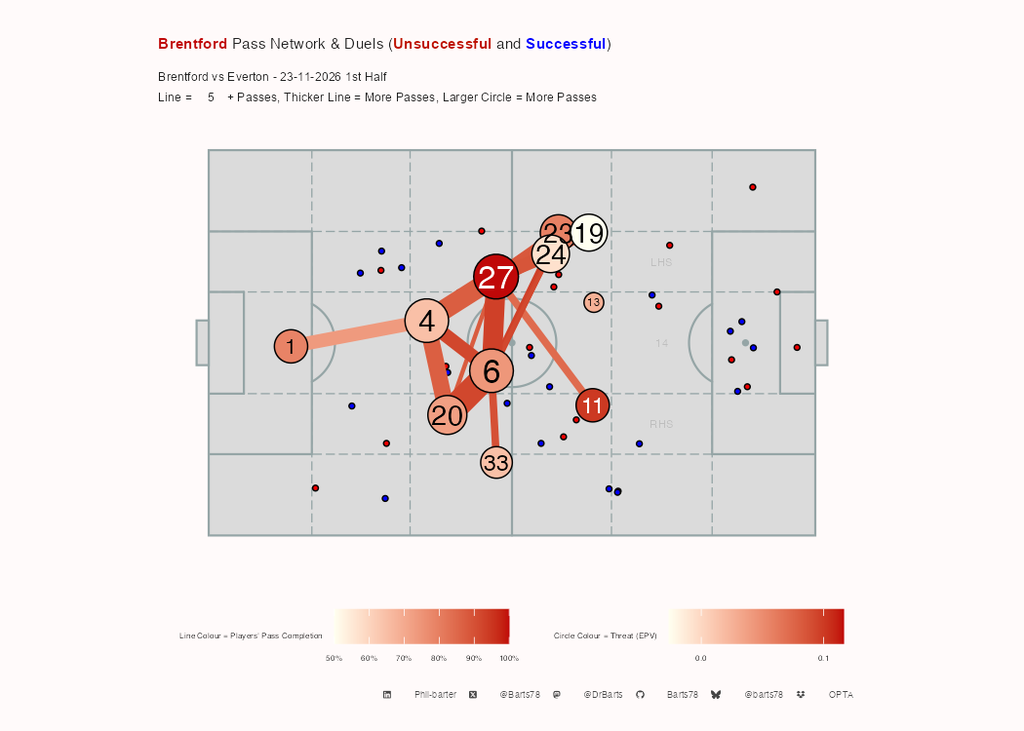

Away Pass Maps

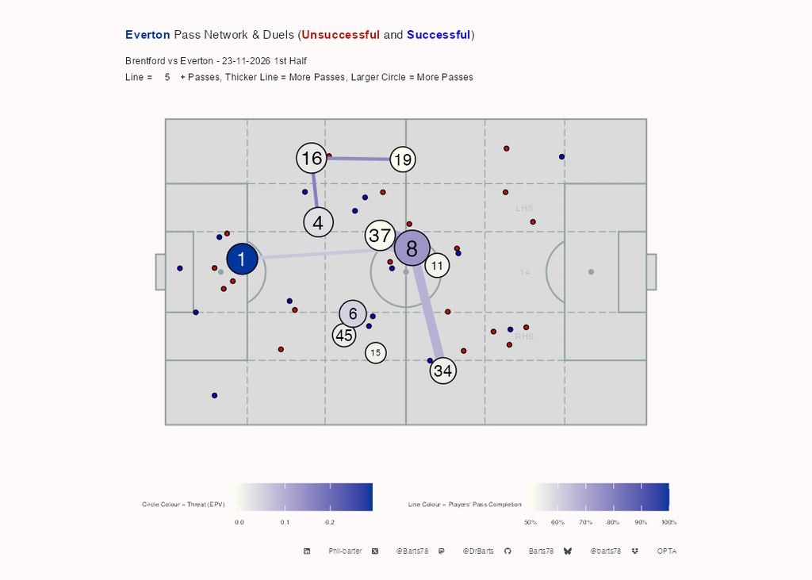

Home Pass Maps by Time

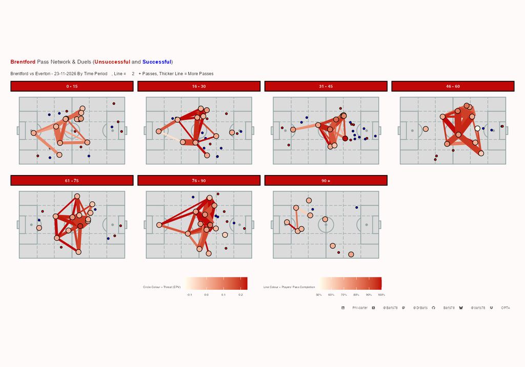

Away Pass Maps by Time

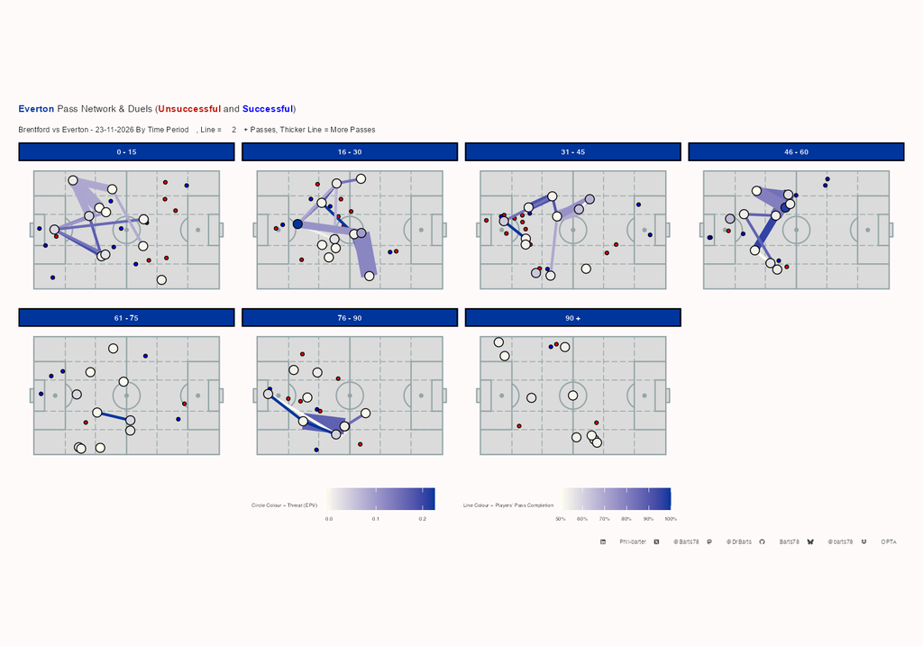

Home Attacking Pass Maps

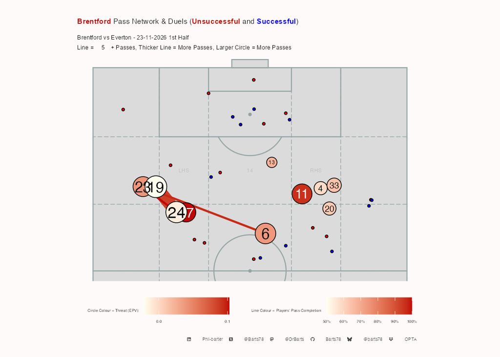

Away Attacking Pass Maps

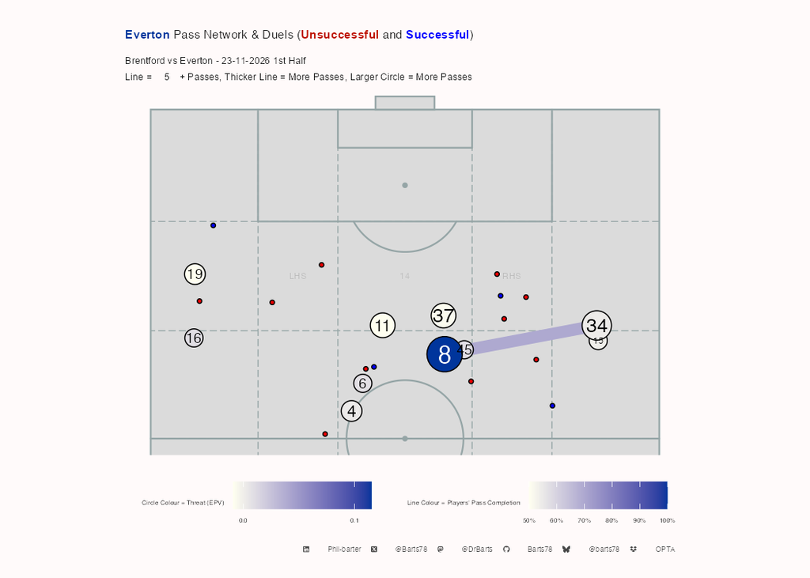

Home Attacking Pass Maps by Time

[figure not shown]

Away Attacking Pass Maps by Time

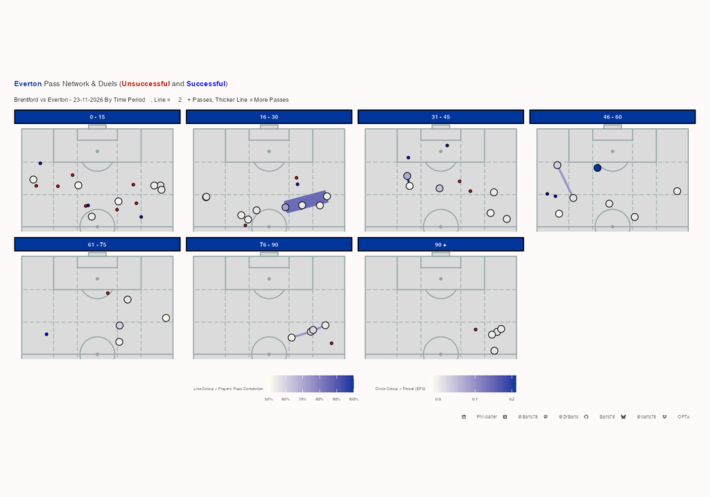

**Pass Connections by Passer**

Brentford Open Play Passing connections

Brentford vs Everton - 23-11-2026 | Completed passes only, min 5 per pair. Passer Completion % = all of the passer's attempts

|  | Completed Passes | % of Passer's Completions | % of Receiver's Receptions | Passer Completion % | Long Passes | Final Third Passes | PK Box Passes | Crosses | Key Passes | Prog Passes | EPV | EPV / Pass | Pass Time |
| --- | --- | --- | --- | --- | --- | --- | --- | --- | --- | --- | --- | --- | --- |
| Caoimhín Kelleher |  |  |  |  |  |  |  |  |  |  |  |  |  |
| Sepp van den Berg | 9 | 36% | 14% | 78% | 0 | 0 | 0 | 0 | 0 | 0 | 0.010 | 0.001 | 3.78 |
| El Hadji Malick Diouf |  |  |  |  |  |  |  |  |  |  |  |  |  |
| Mathias Jensen | 9 | 45% | 33% | 100% | 0 | 4 | 0 | 0 | 0 | 0 | 0.025 | 0.003 | 2.56 |
| Jaidon Anthony |  |  |  |  |  |  |  |  |  |  |  |  |  |
| Keane Lewis-Potter | 12 | 23% | 25% | 87% | 0 | 6 | 1 | 0 | 1 | 2 | 0.114 | 0.010 | 2.08 |
| Mikkel Damsgaard | 13 | 25% | 13% | 87% | 0 | 9 | 1 | 0 | 0 | 2 | 0.078 | 0.006 | 2.23 |
| Sepp van den Berg | 7 | 14% | 11% | 87% | 1 | 0 | 0 | 0 | 0 | 0 | 0.013 | 0.002 | 3.00 |
| Vitaly Janelt | 12 | 23% | 14% | 87% | 0 | 6 | 1 | 0 | 1 | 2 | 0.042 | 0.004 | 2.67 |
| Yehor Yarmoliuk | 5 | 10% | 6% | 87% | 0 | 3 | 0 | 0 | 0 | 0 | 0.016 | 0.003 | 2.00 |
| Keane Lewis-Potter |  |  |  |  |  |  |  |  |  |  |  |  |  |
| Jaidon Anthony | 12 | 29% | 20% | 88% | 0 | 8 | 0 | 0 | 0 | 2 | 0.096 | 0.008 | 2.25 |
| Mikkel Damsgaard | 9 | 21% | 9% | 88% | 0 | 6 | 1 | 0 | 1 | 1 | 0.066 | 0.007 | 2.22 |
| Vitaly Janelt | 8 | 19% | 9% | 88% | 0 | 2 | 0 | 0 | 0 | 1 | 0.040 | 0.005 | 2.12 |
| Yehor Yarmoliuk | 7 | 17% | 8% | 88% | 0 | 3 | 0 | 0 | 0 | 1 | 0.021 | 0.003 | 3.29 |
| Kristoffer Ajer |  |  |  |  |  |  |  |  |  |  |  |  |  |
| Caoimhín Kelleher | 6 | 10% | 23% | 91% | 0 | 0 | 0 | 0 | 0 | 0 | 0.005 | 0.001 | 2.50 |
| Dango Ouattara | 7 | 12% | 25% | 91% | 1 | 1 | 0 | 0 | 0 | 4 | 0.058 | 0.008 | 3.00 |
| Michael Kayode | 8 | 14% | 19% | 91% | 0 | 2 | 0 | 0 | 0 | 0 | 0.027 | 0.003 | 2.75 |
| Sepp van den Berg | 10 | 17% | 16% | 91% | 0 | 0 | 0 | 0 | 0 | 0 | 0.006 | 0.001 | 3.10 |
| Yehor Yarmoliuk | 14 | 24% | 16% | 91% | 0 | 1 | 0 | 0 | 0 | 0 | 0.027 | 0.002 | 3.43 |
| Mamadou Sangaré |  |  |  |  |  |  |  |  |  |  |  |  |  |
| Mikkel Damsgaard | 5 | 22% | 5% | 100% | 0 | 1 | 0 | 0 | 0 | 0 | 0.010 | 0.002 | 1.60 |
| Mathias Jensen |  |  |  |  |  |  |  |  |  |  |  |  |  |
| Mikkel Damsgaard | 9 | 33% | 9% | 79% | 0 | 3 | 0 | 0 | 0 | 0 | 0.023 | 0.003 | 2.56 |
| Michael Kayode |  |  |  |  |  |  |  |  |  |  |  |  |  |
| Caoimhín Kelleher | 7 | 17% | 27% | 85% | 1 | 0 | 0 | 0 | 0 | 0 | 0.011 | 0.002 | 3.14 |
| Mamadou Sangaré | 5 | 12% | 23% | 85% | 0 | 0 | 0 | 0 | 0 | 1 | 0.008 | 0.002 | 2.00 |
| Yehor Yarmoliuk | 12 | 29% | 14% | 85% | 0 | 8 | 0 | 0 | 0 | 0 | 0.057 | 0.005 | 2.50 |
| Mikkel Damsgaard |  |  |  |  |  |  |  |  |  |  |  |  |  |
| Jaidon Anthony | 21 | 21% | 34% | 94% | 0 | 11 | 1 | 0 | 1 | 3 | 0.144 | 0.007 | 3.29 |
| Keane Lewis-Potter | 7 | 7% | 15% | 94% | 0 | 4 | 0 | 0 | 1 | 2 | 0.089 | 0.013 | 2.71 |
| Mamadou Sangaré | 7 | 7% | 32% | 94% | 0 | 2 | 0 | 0 | 0 | 1 | 0.031 | 0.004 | 3.00 |
| Mathias Jensen | 5 | 5% | 18% | 94% | 0 | 3 | 0 | 0 | 0 | 1 | 0.030 | 0.006 | 2.40 |
| Sepp van den Berg | 7 | 7% | 11% | 94% | 1 | 2 | 0 | 0 | 0 | 0 | 0.017 | 0.002 | 3.43 |
| Vitaly Janelt | 19 | 19% | 22% | 94% | 0 | 8 | 1 | 0 | 0 | 2 | 0.178 | 0.009 | 2.68 |
| Yehor Yarmoliuk | 14 | 14% | 16% | 94% | 0 | 7 | 0 | 0 | 0 | 3 | 0.044 | 0.003 | 3.29 |
| Sepp van den Berg |  |  |  |  |  |  |  |  |  |  |  |  |  |
| Caoimhín Kelleher | 7 | 9% | 27% | 93% | 0 | 0 | 0 | 0 | 0 | 0 | 0.008 | 0.001 | 2.86 |
| Keane Lewis-Potter | 7 | 9% | 15% | 93% | 0 | 0 | 0 | 0 | 0 | 1 | 0.018 | 0.003 | 2.43 |
| Kristoffer Ajer | 11 | 14% | 25% | 93% | 0 | 0 | 0 | 0 | 0 | 0 | 0.013 | 0.001 | 5.09 |
| Mikkel Damsgaard | 9 | 11% | 9% | 93% | 0 | 0 | 0 | 0 | 0 | 2 | 0.028 | 0.003 | 3.11 |
| Vitaly Janelt | 16 | 20% | 18% | 93% | 0 | 0 | 0 | 0 | 0 | 1 | 0.019 | 0.001 | 3.06 |
| Yehor Yarmoliuk | 13 | 16% | 15% | 93% | 1 | 0 | 0 | 0 | 0 | 2 | 0.025 | 0.002 | 2.62 |
| Vitaly Janelt |  |  |  |  |  |  |  |  |  |  |  |  |  |
| Dango Ouattara | 5 | 6% | 18% | 92% | 2 | 2 | 0 | 0 | 0 | 4 | 0.071 | 0.014 | 2.00 |
| Jaidon Anthony | 9 | 10% | 15% | 92% | 0 | 2 | 0 | 0 | 0 | 1 | 0.036 | 0.004 | 2.33 |
| Keane Lewis-Potter | 9 | 10% | 19% | 92% | 0 | 2 | 0 | 0 | 0 | 1 | 0.031 | 0.003 | 2.44 |
| Kristoffer Ajer | 5 | 6% | 11% | 92% | 2 | 1 | 0 | 0 | 0 | 0 | 0.027 | 0.005 | 4.00 |
| Michael Kayode | 5 | 6% | 12% | 92% | 0 | 3 | 0 | 0 | 0 | 1 | 0.035 | 0.007 | 2.40 |
| Mikkel Damsgaard | 20 | 23% | 21% | 92% | 0 | 2 | 0 | 0 | 0 | 6 | 0.076 | 0.004 | 2.15 |
| Sepp van den Berg | 6 | 7% | 9% | 92% | 0 | 0 | 0 | 0 | 0 | 0 | 0.009 | 0.002 | 2.67 |
| Yehor Yarmoliuk | 16 | 19% | 18% | 92% | 0 | 2 | 0 | 0 | 0 | 1 | 0.026 | 0.002 | 2.50 |
| Yehor Yarmoliuk |  |  |  |  |  |  |  |  |  |  |  |  |  |
| Dango Ouattara | 8 | 8% | 29% | 97% | 1 | 1 | 0 | 0 | 0 | 3 | 0.062 | 0.008 | 3.25 |
| Jaidon Anthony | 7 | 7% | 12% | 97% | 0 | 3 | 0 | 0 | 0 | 2 | 0.051 | 0.007 | 2.57 |
| Keane Lewis-Potter | 8 | 8% | 17% | 97% | 2 | 2 | 0 | 0 | 0 | 0 | 0.019 | 0.002 | 2.88 |
| Kristoffer Ajer | 11 | 12% | 25% | 97% | 0 | 1 | 0 | 0 | 0 | 0 | 0.023 | 0.002 | 3.91 |
| Michael Kayode | 12 | 13% | 29% | 97% | 0 | 1 | 0 | 0 | 0 | 1 | 0.045 | 0.004 | 2.75 |
| Mikkel Damsgaard | 17 | 18% | 18% | 97% | 0 | 6 | 0 | 0 | 0 | 5 | 0.053 | 0.003 | 2.24 |
| Sepp van den Berg | 11 | 12% | 17% | 97% | 0 | 1 | 0 | 0 | 0 | 1 | 0.018 | 0.002 | 3.09 |
| Vitaly Janelt | 16 | 17% | 18% | 97% | 0 | 2 | 0 | 0 | 0 | 2 | 0.031 | 0.002 | 2.62 |

X @Barts78 · Bluesky @barts78 · Mastodon @DrBarts · GitHub Barts78 · LinkedIn Phil-barter · Data: Opta

**Pass Connections by Receiver**

Brentford Open Play Passing connections

Brentford vs Everton - 23-11-2026 | Completed passes only, min 5 per pair. Passer Completion % = all of the passer's attempts

|  | Completed Passes | % of Passer's Completions | % of Receiver's Receptions | Passer Completion % | Long Passes | Final Third Passes | PK Box Passes | Crosses | Key Passes | Prog Passes | EPV | EPV / Pass | Pass Time |
| --- | --- | --- | --- | --- | --- | --- | --- | --- | --- | --- | --- | --- | --- |
| Sepp van den Berg |  |  |  |  |  |  |  |  |  |  |  |  |  |
| Caoimhín Kelleher | 9 | 36% | 14% | 78% | 0 | 0 | 0 | 0 | 0 | 0 | 0.010 | 0.001 | 3.78 |
| Jaidon Anthony | 7 | 14% | 11% | 87% | 1 | 0 | 0 | 0 | 0 | 0 | 0.013 | 0.002 | 3.00 |
| Kristoffer Ajer | 10 | 17% | 16% | 91% | 0 | 0 | 0 | 0 | 0 | 0 | 0.006 | 0.001 | 3.10 |
| Mikkel Damsgaard | 7 | 7% | 11% | 94% | 1 | 2 | 0 | 0 | 0 | 0 | 0.017 | 0.002 | 3.43 |
| Vitaly Janelt | 6 | 7% | 9% | 92% | 0 | 0 | 0 | 0 | 0 | 0 | 0.009 | 0.002 | 2.67 |
| Yehor Yarmoliuk | 11 | 12% | 17% | 97% | 0 | 1 | 0 | 0 | 0 | 1 | 0.018 | 0.002 | 3.09 |
| Mathias Jensen |  |  |  |  |  |  |  |  |  |  |  |  |  |
| El Hadji Malick Diouf | 9 | 45% | 33% | 100% | 0 | 4 | 0 | 0 | 0 | 0 | 0.025 | 0.003 | 2.56 |
| Mikkel Damsgaard | 5 | 5% | 18% | 94% | 0 | 3 | 0 | 0 | 0 | 1 | 0.030 | 0.006 | 2.40 |
| Keane Lewis-Potter |  |  |  |  |  |  |  |  |  |  |  |  |  |
| Jaidon Anthony | 12 | 23% | 25% | 87% | 0 | 6 | 1 | 0 | 1 | 2 | 0.114 | 0.010 | 2.08 |
| Mikkel Damsgaard | 7 | 7% | 15% | 94% | 0 | 4 | 0 | 0 | 1 | 2 | 0.089 | 0.013 | 2.71 |
| Sepp van den Berg | 7 | 9% | 15% | 93% | 0 | 0 | 0 | 0 | 0 | 1 | 0.018 | 0.003 | 2.43 |
| Vitaly Janelt | 9 | 10% | 19% | 92% | 0 | 2 | 0 | 0 | 0 | 1 | 0.031 | 0.003 | 2.44 |
| Yehor Yarmoliuk | 8 | 8% | 17% | 97% | 2 | 2 | 0 | 0 | 0 | 0 | 0.019 | 0.002 | 2.88 |
| Mikkel Damsgaard |  |  |  |  |  |  |  |  |  |  |  |  |  |
| Jaidon Anthony | 13 | 25% | 13% | 87% | 0 | 9 | 1 | 0 | 0 | 2 | 0.078 | 0.006 | 2.23 |
| Keane Lewis-Potter | 9 | 21% | 9% | 88% | 0 | 6 | 1 | 0 | 1 | 1 | 0.066 | 0.007 | 2.22 |
| Mamadou Sangaré | 5 | 22% | 5% | 100% | 0 | 1 | 0 | 0 | 0 | 0 | 0.010 | 0.002 | 1.60 |
| Mathias Jensen | 9 | 33% | 9% | 79% | 0 | 3 | 0 | 0 | 0 | 0 | 0.023 | 0.003 | 2.56 |
| Sepp van den Berg | 9 | 11% | 9% | 93% | 0 | 0 | 0 | 0 | 0 | 2 | 0.028 | 0.003 | 3.11 |
| Vitaly Janelt | 20 | 23% | 21% | 92% | 0 | 2 | 0 | 0 | 0 | 6 | 0.076 | 0.004 | 2.15 |
| Yehor Yarmoliuk | 17 | 18% | 18% | 97% | 0 | 6 | 0 | 0 | 0 | 5 | 0.053 | 0.003 | 2.24 |
| Vitaly Janelt |  |  |  |  |  |  |  |  |  |  |  |  |  |
| Jaidon Anthony | 12 | 23% | 14% | 87% | 0 | 6 | 1 | 0 | 1 | 2 | 0.042 | 0.004 | 2.67 |
| Keane Lewis-Potter | 8 | 19% | 9% | 88% | 0 | 2 | 0 | 0 | 0 | 1 | 0.040 | 0.005 | 2.12 |
| Mikkel Damsgaard | 19 | 19% | 22% | 94% | 0 | 8 | 1 | 0 | 0 | 2 | 0.178 | 0.009 | 2.68 |
| Sepp van den Berg | 16 | 20% | 18% | 93% | 0 | 0 | 0 | 0 | 0 | 1 | 0.019 | 0.001 | 3.06 |
| Yehor Yarmoliuk | 16 | 17% | 18% | 97% | 0 | 2 | 0 | 0 | 0 | 2 | 0.031 | 0.002 | 2.62 |
| Yehor Yarmoliuk |  |  |  |  |  |  |  |  |  |  |  |  |  |
| Jaidon Anthony | 5 | 10% | 6% | 87% | 0 | 3 | 0 | 0 | 0 | 0 | 0.016 | 0.003 | 2.00 |
| Keane Lewis-Potter | 7 | 17% | 8% | 88% | 0 | 3 | 0 | 0 | 0 | 1 | 0.021 | 0.003 | 3.29 |
| Kristoffer Ajer | 14 | 24% | 16% | 91% | 0 | 1 | 0 | 0 | 0 | 0 | 0.027 | 0.002 | 3.43 |
| Michael Kayode | 12 | 29% | 14% | 85% | 0 | 8 | 0 | 0 | 0 | 0 | 0.057 | 0.005 | 2.50 |
| Mikkel Damsgaard | 14 | 14% | 16% | 94% | 0 | 7 | 0 | 0 | 0 | 3 | 0.044 | 0.003 | 3.29 |
| Sepp van den Berg | 13 | 16% | 15% | 93% | 1 | 0 | 0 | 0 | 0 | 2 | 0.025 | 0.002 | 2.62 |
| Vitaly Janelt | 16 | 19% | 18% | 92% | 0 | 2 | 0 | 0 | 0 | 1 | 0.026 | 0.002 | 2.50 |
| Jaidon Anthony |  |  |  |  |  |  |  |  |  |  |  |  |  |
| Keane Lewis-Potter | 12 | 29% | 20% | 88% | 0 | 8 | 0 | 0 | 0 | 2 | 0.096 | 0.008 | 2.25 |
| Mikkel Damsgaard | 21 | 21% | 34% | 94% | 0 | 11 | 1 | 0 | 1 | 3 | 0.144 | 0.007 | 3.29 |
| Vitaly Janelt | 9 | 10% | 15% | 92% | 0 | 2 | 0 | 0 | 0 | 1 | 0.036 | 0.004 | 2.33 |
| Yehor Yarmoliuk | 7 | 7% | 12% | 97% | 0 | 3 | 0 | 0 | 0 | 2 | 0.051 | 0.007 | 2.57 |
| Caoimhín Kelleher |  |  |  |  |  |  |  |  |  |  |  |  |  |
| Kristoffer Ajer | 6 | 10% | 23% | 91% | 0 | 0 | 0 | 0 | 0 | 0 | 0.005 | 0.001 | 2.50 |
| Michael Kayode | 7 | 17% | 27% | 85% | 1 | 0 | 0 | 0 | 0 | 0 | 0.011 | 0.002 | 3.14 |
| Sepp van den Berg | 7 | 9% | 27% | 93% | 0 | 0 | 0 | 0 | 0 | 0 | 0.008 | 0.001 | 2.86 |
| Dango Ouattara |  |  |  |  |  |  |  |  |  |  |  |  |  |
| Kristoffer Ajer | 7 | 12% | 25% | 91% | 1 | 1 | 0 | 0 | 0 | 4 | 0.058 | 0.008 | 3.00 |
| Vitaly Janelt | 5 | 6% | 18% | 92% | 2 | 2 | 0 | 0 | 0 | 4 | 0.071 | 0.014 | 2.00 |
| Yehor Yarmoliuk | 8 | 8% | 29% | 97% | 1 | 1 | 0 | 0 | 0 | 3 | 0.062 | 0.008 | 3.25 |
| Michael Kayode |  |  |  |  |  |  |  |  |  |  |  |  |  |
| Kristoffer Ajer | 8 | 14% | 19% | 91% | 0 | 2 | 0 | 0 | 0 | 0 | 0.027 | 0.003 | 2.75 |
| Vitaly Janelt | 5 | 6% | 12% | 92% | 0 | 3 | 0 | 0 | 0 | 1 | 0.035 | 0.007 | 2.40 |
| Yehor Yarmoliuk | 12 | 13% | 29% | 97% | 0 | 1 | 0 | 0 | 0 | 1 | 0.045 | 0.004 | 2.75 |
| Mamadou Sangaré |  |  |  |  |  |  |  |  |  |  |  |  |  |
| Michael Kayode | 5 | 12% | 23% | 85% | 0 | 0 | 0 | 0 | 0 | 1 | 0.008 | 0.002 | 2.00 |
| Mikkel Damsgaard | 7 | 7% | 32% | 94% | 0 | 2 | 0 | 0 | 0 | 1 | 0.031 | 0.004 | 3.00 |
| Kristoffer Ajer |  |  |  |  |  |  |  |  |  |  |  |  |  |
| Sepp van den Berg | 11 | 14% | 25% | 93% | 0 | 0 | 0 | 0 | 0 | 0 | 0.013 | 0.001 | 5.09 |
| Vitaly Janelt | 5 | 6% | 11% | 92% | 2 | 1 | 0 | 0 | 0 | 0 | 0.027 | 0.005 | 4.00 |
| Yehor Yarmoliuk | 11 | 12% | 25% | 97% | 0 | 1 | 0 | 0 | 0 | 0 | 0.023 | 0.002 | 3.91 |

X @Barts78 · Bluesky @barts78 · Mastodon @DrBarts · GitHub Barts78 · LinkedIn Phil-barter · Data: Opta

**Away Pass Connections by Passer**

Everton Open Play Passing connections

Brentford vs Everton - 23-11-2026 | Completed passes only, min 5 per pair. Passer Completion % = all of the passer's attempts

|  | Completed Passes | % of Passer's Completions | % of Receiver's Receptions | Passer Completion % | Long Passes | Final Third Passes | PK Box Passes | Crosses | Key Passes | Prog Passes | EPV | EPV / Pass | Pass Time |
| --- | --- | --- | --- | --- | --- | --- | --- | --- | --- | --- | --- | --- | --- |
| James Garner |  |  |  |  |  |  |  |  |  |  |  |  |  |
| Kiernan Dewsbury-Hall | 9 | 32% | 35% | 80% | 1 | 1 | 0 | 0 | 1 | 0 | 0.015 | 0.002 | 1.78 |
| Jarrad Branthwaite |  |  |  |  |  |  |  |  |  |  |  |  |  |
| Jordan Pickford | 5 | 22% | 24% | 85% | 0 | 0 | 0 | 0 | 0 | 0 | 0.007 | 0.001 | 2.60 |
| Vitalii Mykolenko | 5 | 22% | 21% | 85% | 0 | 0 | 0 | 0 | 0 | 0 | 0.003 | 0.001 | 2.80 |
| Vitalii Mykolenko |  |  |  |  |  |  |  |  |  |  |  |  |  |
| Jarrad Branthwaite | 5 | 23% | 29% | 76% | 0 | 0 | 0 | 0 | 0 | 0 | 0.005 | 0.001 | 1.40 |

X @Barts78 · Bluesky @barts78 · Mastodon @DrBarts · GitHub Barts78 · LinkedIn Phil-barter · Data: Opta

**Away Pass Connections by Receiver**

Everton Open Play Passing connections

Brentford vs Everton - 23-11-2026 | Completed passes only, min 5 per pair. Passer Completion % = all of the passer's attempts

|  | Completed Passes | % of Passer's Completions | % of Receiver's Receptions | Passer Completion % | Long Passes | Final Third Passes | PK Box Passes | Crosses | Key Passes | Prog Passes | EPV | EPV / Pass | Pass Time |
| --- | --- | --- | --- | --- | --- | --- | --- | --- | --- | --- | --- | --- | --- |
| Kiernan Dewsbury-Hall |  |  |  |  |  |  |  |  |  |  |  |  |  |
| James Garner | 9 | 32% | 35% | 80% | 1 | 1 | 0 | 0 | 1 | 0 | 0.015 | 0.002 | 1.78 |
| Jordan Pickford |  |  |  |  |  |  |  |  |  |  |  |  |  |
| Jarrad Branthwaite | 5 | 22% | 24% | 85% | 0 | 0 | 0 | 0 | 0 | 0 | 0.007 | 0.001 | 2.60 |
| Vitalii Mykolenko |  |  |  |  |  |  |  |  |  |  |  |  |  |
| Jarrad Branthwaite | 5 | 22% | 21% | 85% | 0 | 0 | 0 | 0 | 0 | 0 | 0.003 | 0.001 | 2.80 |
| Jarrad Branthwaite |  |  |  |  |  |  |  |  |  |  |  |  |  |
| Vitalii Mykolenko | 5 | 23% | 29% | 76% | 0 | 0 | 0 | 0 | 0 | 0 | 0.005 | 0.001 | 1.40 |

X @Barts78 · Bluesky @barts78 · Mastodon @DrBarts · GitHub Barts78 · LinkedIn Phil-barter · Data: Opta

Home Passing Tree Plot

[figure not shown]

Away Passing Tree Plot

[figure not shown]

Home wave plot

[figure not shown]

Away wave plot

[figure not shown]

**Home 1st Half Pass receiving Areas**

[figure not shown]

**Home 2nd Half Pass receiving Areas**

[figure not shown]

**Home Up to 1st Sub Pass receiving Areas**

[figure not shown]

**Away 1st Half Pass receiving Areas**

[figure not shown]

**Away 2nd Half Pass receiving Areas**

[figure not shown]

**Away Up to 1st Sub Pass receiving Areas**

[figure not shown]

Home Passing chains

[figure not shown]

Away Passing Chains

[figure not shown]

**Full time**

Brentford FT Passing Chain Length (5, 6-10, 11-15, 16 +) & Distance (m)

Brentford vs Everton - 23-11-2026

|  | Pass Chain Length | Total Chain Passes | Max Chain Length | Average Chain Length | Percent of Teams Passes | Total Chain Distance | Max Chain Distance | Average Chain Distance | Percent of Teams Passing Distance |
| --- | --- | --- | --- | --- | --- | --- | --- | --- | --- |
|  | VLow | 193 | 5 | 3 | 27% | 2,589.85 | 125.82 | 13.40 | 25% |
|  | Low | 159 | 10 | 7 | 22% | 2,463.04 | 231.39 | 15.50 | 24% |
|  | Medium | 169 | 15 | 13 | 24% | 2,478.72 | 240.53 | 14.70 | 24% |
|  | High | 196 | 34 | 26 | 27% | 2,667.43 | 563.45 | 13.60 | 26% |
| Overall Totals | — | 717 | 64 | 49 | — | 10,199 | 1,161 | 57 | — |
| Overall Average | — | 179 | 16 | 12 | — | 2,550 | 290 | 14 | — |

X @Barts78 · Bluesky @barts78 · Mastodon @DrBarts · GitHub Barts78 · LinkedIn Phil-barter · Data: Opta

**1st Half**

Brentford 1st Half Passing Chain Length (5, 6-10, 11-15, 16 +) & Distance (m)

Brentford vs Everton - 23-11-2026

|  | Pass Chain Length | Total Chain Passes | Max Chain Length | Average Chain Length | Percent of Teams Passes | Total Chain Distance | Max Chain Distance | Average Chain Distance | Percent of Teams Passing Distance |
| --- | --- | --- | --- | --- | --- | --- | --- | --- | --- |
|  | VLow | 85 | 4 | 2 | 29% | 1,193.86 | 125.82 | 14.00 | 27% |
|  | Low | 82 | 9 | 7 | 28% | 1,330.29 | 231.39 | 16.20 | 30% |
|  | Medium | 103 | 15 | 13 | 35% | 1,565.22 | 240.53 | 15.20 | 35% |
|  | High | 24 | 24 | 24 | 8% | 337.40 | 337.40 | 14.10 | 8% |
| Overall Totals | — | 294 | 52 | 46 | — | 4,427 | 935 | 60 | — |
| Overall Average | — | 74 | 13 | 12 | — | 1,107 | 234 | 15 | — |

X @Barts78 · Bluesky @barts78 · Mastodon @DrBarts · GitHub Barts78 · LinkedIn Phil-barter · Data: Opta

**2nd Half**

Brentford 2nd Half Passing Chain Length (5, 6-10, 11-15, 16 +) & Distance (m)

Brentford vs Everton - 23-11-2026

|  | Pass Chain Length | Total Chain Passes | Max Chain Length | Average Chain Length | Percent of Teams Passes | Total Chain Distance | Max Chain Distance | Average Chain Distance | Percent of Teams Passing Distance |
| --- | --- | --- | --- | --- | --- | --- | --- | --- | --- |
|  | VLow | 108 | 5 | 3 | 26% | 1,395.99 | 115.88 | 12.90 | 24% |
|  | Low | 77 | 10 | 8 | 18% | 1,132.75 | 168.83 | 14.70 | 20% |
|  | Medium | 66 | 15 | 13 | 16% | 913.50 | 231.11 | 13.80 | 16% |
|  | High | 172 | 34 | 26 | 41% | 2,330.03 | 563.45 | 13.50 | 40% |
| Overall Totals | — | 423 | 64 | 50 | — | 5,772 | 1,079 | 55 | — |
| Overall Average | — | 106 | 16 | 12 | — | 1,443 | 270 | 14 | — |

X @Barts78 · Bluesky @barts78 · Mastodon @DrBarts · GitHub Barts78 · LinkedIn Phil-barter · Data: Opta

**Away Full time**

Everton FT Passing Chain Length (5, 6-10, 11-15, 16 +) & Distance (m)

Brentford vs Everton - 23-11-2026

|  | Pass Chain Length | Total Chain Passes | Max Chain Length | Average Chain Length | Percent of Teams Passes | Total Chain Distance | Max Chain Distance | Average Chain Distance | Percent of Teams Passing Distance |
| --- | --- | --- | --- | --- | --- | --- | --- | --- | --- |
|  | VLow | 128 | 5 | 2 | 58% | 2,128.61 | 98.26 | 16.60 | 63% |
|  | Low | 62 | 9 | 8 | 28% | 803.41 | 165.61 | 13.00 | 24% |
|  | Medium | 11 | 11 | 11 | 5% | 112.51 | 112.51 | 10.20 | 3% |
|  | High | 19 | 19 | 19 | 9% | 314.22 | 314.22 | 16.50 | 9% |
| Overall Totals | — | 220 | 44 | 40 | — | 3,359 | 691 | 56 | — |
| Overall Average | — | 55 | 11 | 10 | — | 840 | 173 | 14 | — |

X @Barts78 · Bluesky @barts78 · Mastodon @DrBarts · GitHub Barts78 · LinkedIn Phil-barter · Data: Opta

**Away 1st Half**

Everton 1st Half Passing Chain Length (5, 6-10, 11-15, 16 +) & Distance (m)

Brentford vs Everton - 23-11-2026

|  | Pass Chain Length | Total Chain Passes | Max Chain Length | Average Chain Length | Percent of Teams Passes | Total Chain Distance | Max Chain Distance | Average Chain Distance | Percent of Teams Passing Distance |
| --- | --- | --- | --- | --- | --- | --- | --- | --- | --- |
|  | VLow | 67 | 5 | 2 | 49% | 1,063.47 | 93.44 | 15.90 | 52% |
|  | Low | 39 | 9 | 8 | 29% | 567.48 | 165.61 | 14.60 | 28% |
|  | Medium | 11 | 11 | 11 | 8% | 112.51 | 112.51 | 10.20 | 5% |
|  | High | 19 | 19 | 19 | 14% | 314.22 | 314.22 | 16.50 | 15% |
| Overall Totals | — | 136 | 44 | 40 | — | 2,058 | 686 | 57 | — |
| Overall Average | — | 34 | 11 | 10 | — | 514 | 171 | 14 | — |

X @Barts78 · Bluesky @barts78 · Mastodon @DrBarts · GitHub Barts78 · LinkedIn Phil-barter · Data: Opta

**Away 2nd Half**

Everton 2nd Half Passing Chain Length (5, 6-10, 11-15, 16 +) & Distance (m)

Brentford vs Everton - 23-11-2026

|  | Pass Chain Length | Total Chain Passes | Max Chain Length | Average Chain Length | Percent of Teams Passes | Total Chain Distance | Max Chain Distance | Average Chain Distance | Percent of Teams Passing Distance |
| --- | --- | --- | --- | --- | --- | --- | --- | --- | --- |
|  | VLow | 61 | 5 | 3 | 73% | 1,065.14 | 98.26 | 17.50 | 82% |
|  | Low | 23 | 9 | 7 | 27% | 235.93 | 92.98 | 10.30 | 18% |
| Overall Totals | — | 84 | 14 | 10 | — | 1,301 | 191 | 28 | — |
| Overall Average | — | 42 | 7 | 5 | — | 651 | 96 | 14 | — |

X @Barts78 · Bluesky @barts78 · Mastodon @DrBarts · GitHub Barts78 · LinkedIn Phil-barter · Data: Opta

**Home Z14 RS By Half**

[figure not shown]

**Home Z14 RS By Game Period**

[figure not shown]

**Away Z14 RS By Half**

[figure not shown]

**Away Z14 RS By Game Period**

[figure not shown]

**Home Long Passes By half**

[figure not shown]

**Home Long Passes By Game Period**

[figure not shown]

**Away Long Passes By Half**

[figure not shown]

**Away Long Passes By Game period**

[figure not shown]

Set-Piece Summary

**Set Pieces**

Brentford vs Everton - 23-11-2026

|  | Brentford | Everton |
| --- | --- | --- |
| Corners |  |  |
| Corners taken | 6 | 3 |
| Short | 0 | 1 |
| Direct | 6 | 2 |
| Direct - first contact won | 2 (33%) | 0 (0%) |
| Free kicks |  |  |
| Free kicks (passes) | 7 | 10 |
| Into final third / box | 3 | 5 |
| Into box | 2 | 1 |
| Throw-ins |  |  |
| Throw-ins | 17 | 8 |
| Retained (first touch) | 76% | 75% |
| Shots by situation |  |  |
| Open-play shots | 15 | 2 |
| Open-play xG | 1.42 | 0.20 |
| Open-play goals | 2 | 0 |
| Set-piece shots | 6 | 2 |
| Set-piece xG | 1.16 | 0.04 |
| Set-piece goals | 2 | 0 |
| Penalties | 0 | 0 |
| Penalty xG | 0.00 | 0.00 |
| Set-piece share of xG | 45% | 17% |

First contact: the team that touches the ball first after the delivery (aerial duels go to the winner). Throw-ins retained = first touch by the taking team.  
X @Barts78 · Bluesky @barts78 · Mastodon @DrBarts · GitHub Barts78 · LinkedIn Phil-barter · Data: Opta

**Corners**

[figure not shown]

**Free Kicks**

[figure not shown]

**Corners**

[figure not shown]

**Free Kicks**

[figure not shown]

**Sequence Map**

[figure not shown]

**Sequence Table**

**Brentford - Shot-Creating Sequences**

Brentford vs Everton - 23-11-2026

| Min | Shooter | Result | xG | Situation | Started by | Started from | Start zone | Passes | Duration (s) |
| --- | --- | --- | --- | --- | --- | --- | --- | --- | --- |
| 8' | Anthony | Blocked | 0.04 | Open play | Wilson | Open-play regain | Att third, Central | 2 | 5 |
| 15' | Damsgaard | Saved | 0.04 | Open play | Damsgaard | Open-play regain | Mid third, Central | 0 | 7 |
| 19' | Kayode | Off target | 0.15 | Open play | Janelt | Open-play regain | Def third, Left wing | 14 | 42 |
| 23' | Lewis-Potter | Goal | 0.22 | Open play | Anthony | Open-play regain | Att third, Left half-space | 1 | 1 |
| 25' | Lewis-Potter | Blocked | 0.11 | Set piece | Damsgaard | Free kick | Att third, Right wing | 1 | 3 |
| 26' | Lewis-Potter | Goal | 0.17 | Set piece | Damsgaard | Free kick | Att third, Right wing | 1 | 4 |
| 31' | Lewis-Potter | Blocked | 0.06 | Open play | Lewis-Potter | Open-play regain | Mid third, Left wing | 5 | 9 |
| 31' | Wilson | Saved | 0.06 | Open play | Lewis-Potter | Open-play regain | Mid third, Left wing | 5 | 14 |
| 42' | Lewis-Potter | Blocked | 0.06 | Set piece | Lewis-Potter | Open-play regain | Att third, Central | 0 | 0 |
| 45' | Damsgaard | Saved | 0.02 | Open play | Damsgaard | Open-play regain | Mid third, Central | 11 | 153 |
| 45+1' | Lewis-Potter | Blocked | 0.10 | Set piece | Janelt | Corner | Att third, Right wing | 1 | 3 |
| 45+6' | Ouattara | Blocked | 0.07 | Set piece | Kayode | Open-play regain | Att third, Left wing | 13 | 120 |
| 45+8' | Ouattara | Blocked | 0.11 | Open play | van den Berg | Open-play regain | Mid third, Left wing | 9 | 22 |
| 46' | Lewis-Potter | Off target | 0.08 | Open play | Damsgaard | Open-play regain | Att third, Left half-space | 1 | 2 |
| 55' | Kayode | Off target | 0.27 | Open play | Damsgaard | Open-play regain | Att third, Left half-space | 1 | 2 |
| 67' | Janelt | Goal | 0.02 | Open play | Ajer | Throw-in | Mid third, Right wing | 5 | 14 |
| 73' | Wilson | Blocked | 0.15 | Open play | Lewis-Potter | Open-play regain | Mid third, Left wing | 36 | 108 |
| 75' | Schade | Off target | 0.03 | Open play | Kayode | Open-play regain | Mid third, Right wing | 6 | 22 |
| 78' | Schade | Blocked | 0.07 | Open play | Kelleher | Goal kick | Def third, Central | 12 | 24 |
| 87' | Carvalho | Blocked | 0.10 | Open play | Jensen | Open-play regain | Att third, Central | 3 | 8 |
| 90' | Carvalho | Goal | 0.65 | Set piece | Jensen | Corner | Att third, Left wing | 1 | 2 |

X @Barts78 · Bluesky @barts78 · Mastodon @DrBarts · GitHub Barts78 · LinkedIn Phil-barter · Data: Opta

**Sequence Map**

[figure not shown]

**Sequence Table**

**Everton - Shot-Creating Sequences**

Brentford vs Everton - 23-11-2026

| Min | Shooter | Result | xG | Situation | Started by | Started from | Start zone | Passes | Duration (s) |
| --- | --- | --- | --- | --- | --- | --- | --- | --- | --- |
| 28' | Dewsbury-Hall | Off target | 0.02 | Set piece | Garner | Free kick | Att third, Right half-space | 1 | 3 |
| 35' | Armstrong | Saved | 0.02 | Set piece | Garner | Corner | Att third, Left wing | 2 | 5 |
| 45+11' | Barry | Saved | 0.12 | Open play | Barry | Open-play regain | Att third, Central | 0 | 0 |
| 77' | Johnson | Blocked | 0.08 | Open play | Grealish | Open-play regain | Def third, Left half-space | 1 | 8 |

X @Barts78 · Bluesky @barts78 · Mastodon @DrBarts · GitHub Barts78 · LinkedIn Phil-barter · Data: Opta

Entries by Channel

**Box and Final-Third Entries (open play)**

Brentford vs Everton - 23-11-2026

|  | Box entries Passes | Box entries Carries | Box entries Total | Box entries Success % | Final-third entries Passes | Final-third entries Carries | Final-third entries Total | Final-third entries Success % |
| --- | --- | --- | --- | --- | --- | --- | --- | --- |
| Brentford |  |  |  |  |  |  |  |  |
| Left wing | 13 | 1 | 14 | 43% | 22 | 3 | 25 | 84% |
| Left half-space | 12 | 2 | 14 | 64% | 25 | 2 | 27 | 81% |
| Central | 6 | 3 | 9 | 89% | 15 | 6 | 21 | 81% |
| Right half-space | 5 | 0 | 5 | 40% | 15 | 3 | 18 | 72% |
| Right wing | 6 | 1 | 7 | 14% | 18 | 2 | 20 | 80% |
| Total | 42 | 7 | 49 | 53% | 95 | 16 | 111 | 80% |
| Everton |  |  |  |  |  |  |  |  |
| Left wing | 3 | 2 | 5 | 40% | 3 | 2 | 5 | 20% |
| Left half-space | 0 | 0 | 0 | - | 5 | 0 | 5 | 40% |
| Central | 5 | 0 | 5 | 0% | 9 | 2 | 11 | 55% |
| Right half-space | 0 | 0 | 0 | - | 5 | 0 | 5 | 40% |
| Right wing | 2 | 0 | 2 | 0% | 8 | 1 | 9 | 33% |
| Total | 10 | 2 | 12 | 17% | 30 | 5 | 35 | 40% |

Channel = where the pass or carry started. Left/right from the attacking team's view. Set pieces excluded.  
X @Barts78 · Bluesky @barts78 · Mastodon @DrBarts · GitHub Barts78 · LinkedIn Phil-barter · Data: Opta

**Box**

[figure not shown]

**Final Third**

[figure not shown]

**Box**

[figure not shown]

**Final Third**

[figure not shown]

**Match Stats**

**Passing stats**

Brentford vs Everton - 23-11-2026

|  | Name | Mins | % of Team Possession | xA | xT | Attempted Passes | Successful Passes | Pass Success % | Assists | BCs | Key Passes | Long Ps | Final 3rd P | Prog Ps | PK Box P | Pass Received | PPs Received | KPs Recieved | Recieveing Suc | EPV Recieved | EPV Created | % of Team EPV |
| --- | --- | --- | --- | --- | --- | --- | --- | --- | --- | --- | --- | --- | --- | --- | --- | --- | --- | --- | --- | --- | --- | --- |
| Keeper | Caoimhín Kelleher | 106 | 0.04 | 0 | 0.01 | 32 | 25 | 0.78 | 0 | 0 | 0 | 11 | 0 | 0 | 0 | 32 | 0 | 0 | 0.8125 | 0.445 | 0.05 | 0.01 |
| Defender | Kristoffer Ajer | 106 | 0.08 | 0 | 0.1 | 65 | 59 | 0.91 | 0 | 0 | 0 | 4 | 6 | 9 | 1 | 58 | 0 | 0 | 0.758620689655172 | 0.272 | 0.175 | 0.04 |
| Defender | Michael Kayode | 106 | 0.07 | 0.3 | 0.12 | 48 | 41 | 0.85 | 0 | 2 | 0 | 2 | 17 | 4 | 1 | 51 | 2 | 1 | 0.843137254901961 | 0.341 | 0.175 | 0.04 |
| Defender | Sepp van den Berg | 106 | 0.1 | 0 | 0.07 | 86 | 80 | 0.93 | 0 | 0 | 0 | 4 | 1 | 8 | 1 | 81 | 1 | 0 | 0.790123456790123 | 0.526 | 0.175 | 0.04 |
| Defender | Keane Lewis-Potter | 85 | 0.07 | 0.1 | 0.23 | 48 | 42 | 0.88 | 0 | 0 | 2 | 2 | 23 | 6 | 2 | 52 | 6 | 2 | 0.923076923076923 | 0.326 | 0.264 | 0.05 |
| Defender | El Hadji Malick Diouf | 21 | 0.03 | 0 | 0.14 | 20 | 20 | 1 | 0 | 0 | 1 | 0 | 9 | 2 | 0 | 25 | 2 | 0 | 0.88 | 0.168 | 0.16 | 0.03 |
| Midfielder | Mikkel Damsgaard | 106 | 0.13 | 0.03 | 0.82 | 106 | 100 | 0.94 | 0 | 0 | 4 | 1 | 50 | 17 | 2 | 105 | 20 | 1 | 0.933333333333333 | 0.421 | 0.92 | 0.19 |
| Midfielder | Vitaly Janelt | 93 | 0.12 | 0 | 0.56 | 94 | 86 | 0.91 | 0 | 0 | 1 | 5 | 19 | 17 | 2 | 95 | 9 | 1 | 0.91578947368421 | 0.424 | 0.66 | 0.13 |
| Midfielder | Jaidon Anthony | 92 | 0.09 | 0.02 | 0.41 | 60 | 52 | 0.87 | 1 | 0 | 3 | 3 | 28 | 6 | 5 | 66 | 11 | 1 | 0.924242424242424 | 0.385 | 0.461 | 0.09 |
| Midfielder | Yehor Yarmoliuk | 85 | 0.12 | 0 | 0.62 | 98 | 95 | 0.97 | 0 | 0 | 1 | 4 | 21 | 15 | 0 | 96 | 7 | 0 | 0.90625 | 0.257 | 0.701 | 0.14 |

[output cut: 6 more lines]

X @Barts78 · Bluesky @barts78 · Mastodon @DrBarts · GitHub Barts78 · LinkedIn Phil-barter · Data: Opta

**Touches and Carries**

Brentford vs Everton - 23-11-2026

|  | Name | Mins | Touches | Def 3rd | Mid 3rd | Final 3rd | PK Box | Total / Min | Def 3rd % TT | Mid Third % TT | Final 3rd % TT | PK Box % TT | Carries | % Carries Prog | % Carries F 3rd | % Carries D Prog | Total Dribbles | Dribbles Won | Dribbles Lost | Dribble Success |
| --- | --- | --- | --- | --- | --- | --- | --- | --- | --- | --- | --- | --- | --- | --- | --- | --- | --- | --- | --- | --- |
| Keeper | Caoimhín Kelleher | 106 | 39 | 38 | 1 | 0 | 0 | 0.367924528301887 | 0.974358974358974 | 0.0256410256410256 | 0 | 0 | 14 | 0 | 0 | 0 | 0 | 0 | 0 | 0 |
| Defender | Kristoffer Ajer | 106 | 73 | 29 | 35 | 9 | 2 | 0.688679245283019 | 0.397260273972603 | 0.479452054794521 | 0.123287671232877 | 0.0273972602739726 | 13 | 0.153846153846154 | 0.153846153846154 | 0.139402800427374 | 1 | 1 | 0 | 1 |
| Defender | Michael Kayode | 106 | 67 | 12 | 24 | 31 | 6 | 0.632075471698113 | 0.17910447761194 | 0.358208955223881 | 0.462686567164179 | 0.0895522388059701 | 7 | 0 | 0.285714285714286 | 0 | 0 | 0 | 0 | 0 |
| Defender | Sepp van den Berg | 106 | 95 | 43 | 49 | 3 | 1 | 0.89622641509434 | 0.452631578947368 | 0.515789473684211 | 0.0315789473684211 | 0.0105263157894737 | 22 | 0.136363636363636 | 0.181818181818182 | 0.239179362880886 | 0 | 0 | 0 | 0 |
| Defender | Keane Lewis-Potter | 85 | 68 | 10 | 22 | 36 | 8 | 0.8 | 0.147058823529412 | 0.323529411764706 | 0.529411764705882 | 0.117647058823529 | 11 | 0.181818181818182 | 0.454545454545455 | 0.121178919688835 | 1 | 0 | 1 | 0 |
| Defender | El Hadji Malick Diouf | 21 | 25 | 4 | 8 | 13 | 1 | 1.19047619047619 | 0.16 | 0.32 | 0.52 | 0.04 | 5 | 0.2 | 0 | 0.377675199328577 | 0 | 0 | 0 | 0 |
| Midfielder | Mikkel Damsgaard | 106 | 126 | 8 | 56 | 62 | 3 | 1.18867924528302 | 0.0634920634920635 | 0.444444444444444 | 0.492063492063492 | 0.0238095238095238 | 27 | 0.185185185185185 | 0.481481481481481 | 0.181512818075229 | 1 | 1 | 0 | 1 |
| Midfielder | Vitaly Janelt | 93 | 111 | 18 | 66 | 27 | 3 | 1.19354838709677 | 0.162162162162162 | 0.594594594594595 | 0.243243243243243 | 0.027027027027027 | 18 | 0.0555555555555556 | 0.333333333333333 | 0.0353541489490949 | 1 | 1 | 0 | 1 |
| Midfielder | Jaidon Anthony | 92 | 84 | 5 | 32 | 47 | 9 | 0.91304347826087 | 0.0595238095238095 | 0.380952380952381 | 0.55952380952381 | 0.107142857142857 | 11 | 0.0909090909090909 | 0.545454545454545 | 0.217622080679406 | 4 | 0 | 4 | 0 |
| Midfielder | Yehor Yarmoliuk | 85 | 111 | 18 | 66 | 27 | 1 | 1.30588235294118 | 0.162162162162162 | 0.594594594594595 | 0.243243243243243 | 0.00900900900900901 | 19 | 0.0526315789473684 | 0.315789473684211 | 0.049919563203822 | 1 | 1 | 0 | 1 |

[output cut: 6 more lines]

X @Barts78 · Bluesky @barts78 · Mastodon @DrBarts · GitHub Barts78 · LinkedIn Phil-barter · Data: Opta

**Shooting stats**

Brentford vs Everton - 23-11-2026

|  | Name | Mins | Total Shots | SoT | 6 yard box | PK Box Shot | Out Box Shots | Blocked Shot | Goals | xG | xGOT | xG/Shot | Shot Accuracy | Shot Quality |
| --- | --- | --- | --- | --- | --- | --- | --- | --- | --- | --- | --- | --- | --- | --- |
| Keeper | Caoimhín Kelleher | 106 | 0 | 0 | 0 | 0 | 0 | 0 | 0 | 0 | 0 | 0 | 0 | 0 |
| Defender | Kristoffer Ajer | 106 | 0 | 0 | 0 | 0 | 0 | 0 | 0 | 0 | 0 | 0 | 0 | 0 |
| Defender | Michael Kayode | 106 | 2 | 0 | 1 | 2 | 0 | 0 | 0 | 0.42 | 0 | 0.21 | 0 | -1 |
| Defender | Sepp van den Berg | 106 | 0 | 0 | 0 | 0 | 0 | 0 | 0 | 0 | 0 | 0 | 0 | 0 |
| Defender | Keane Lewis-Potter | 85 | 7 | 2 | 1 | 6 | 1 | 4 | 2 | 0.8 | 1.06 | 0.114285714285714 | 0.285714285714286 | 0.325 |
| Defender | El Hadji Malick Diouf | 21 | 0 | 0 | 0 | 0 | 0 | 0 | 0 | 0 | 0 | 0 | 0 | 0 |
| Midfielder | Mikkel Damsgaard | 106 | 2 | 2 | 0 | 1 | 1 | 0 | 0 | 0.06 | 0.28 | 0.03 | 1 | 3.66666666666667 |
| Midfielder | Vitaly Janelt | 93 | 1 | 1 | 0 | 0 | 1 | 0 | 1 | 0.02 | 0.19 | 0.02 | 1 | 8.5 |
| Midfielder | Jaidon Anthony | 92 | 1 | 0 | 0 | 1 | 0 | 1 | 0 | 0.04 | 0 | 0.04 | 0 | -1 |
| Midfielder | Yehor Yarmoliuk | 85 | 0 | 0 | 0 | 0 | 0 | 0 | 0 | 0 | 0 | 0 | 0 | 0 |

[output cut: 6 more lines]

X @Barts78 · Bluesky @barts78 · Mastodon @DrBarts · GitHub Barts78 · LinkedIn Phil-barter · Data: Opta

**Defensive stats**

Brentford vs Everton - 23-11-2026

|  | Name | Mins | Aerials Total | Aerials Won | Aerial Success % | Duels Total | Duels Won | Duel Success | Tackles Total | Tackles Won | Tackles Lost | Interceptions Total | Recoverys Total | Clearances Total | Fouls Total | Fouls Conceeded | Fouls Received | Offside Won | Offside Lost | EPV Faced | EPV Won | EPV Lost | Possession Control | Poss Control /100 Touches |
| --- | --- | --- | --- | --- | --- | --- | --- | --- | --- | --- | --- | --- | --- | --- | --- | --- | --- | --- | --- | --- | --- | --- | --- | --- |
| Keeper | Caoimhín Kelleher | 106 | 0 | 0 | 0 | 0 | 0 | 0 | 0 | 0 | 0 | 0 | 3 | 0 | 0 | 0 | 0 | 0 | 0 | 0.003 | 1 | 0 | -4 | -10.3 |
| Defender | Kristoffer Ajer | 106 | 3 | 0 | 0 | 2 | 1 | 0.5 | 0 | 0 | 0 | 1 | 6 | 1 | 1 | 1 | 0 | 0 | 0 | 0.032 | 0.75 | 0.25 | -3 | -4.1 |
| Defender | Michael Kayode | 106 | 0 | 0 | 0 | 4 | 1 | 0.25 | 2 | 1 | 1 | 0 | 1 | 1 | 1 | 1 | 0 | 0 | 0 | 0.006 | 1 | 0 | -11 | -16.4 |
| Defender | Sepp van den Berg | 106 | 7 | 4 | 0.571428571428571 | 1 | 1 | 1 | 0 | 0 | 0 | 0 | 8 | 5 | 1 | 0 | 1 | 0 | 0 | 0.018 | 1 | 0 | 2 | 2.1 |
| Defender | Keane Lewis-Potter | 85 | 2 | 2 | 1 | 2 | 0 | 0 | 0 | 0 | 0 | 0 | 3 | 2 | 0 | 0 | 0 | 0 | 0 | 0.022 | 1 | 0 | -12 | -17.6 |
| Defender | El Hadji Malick Diouf | 21 | 1 | 1 | 1 | 0 | 0 | 0 | 0 | 0 | 0 | 0 | 0 | 0 | 0 | 0 | 0 | 0 | 1 | 0 | 0 | 0 | -2 | -8 |
| Midfielder | Mikkel Damsgaard | 106 | 1 | 0 | 0 | 5 | 2 | 0.4 | 2 | 0 | 2 | 3 | 5 | 0 | 2 | 1 | 1 | 0 | 1 | 0.004 | 1 | 0 | -8 | -6.3 |
| Midfielder | Vitaly Janelt | 93 | 0 | 0 | 0 | 4 | 3 | 0.75 | 1 | 1 | 0 | 2 | 2 | 0 | 2 | 1 | 1 | 0 | 0 | 0.012 | 1 | 0 | -7 | -6.3 |
| Midfielder | Jaidon Anthony | 92 | 2 | 2 | 1 | 8 | 1 | 0.125 | 0 | 0 | 0 | 0 | 3 | 0 | 3 | 2 | 1 | 0 | 0 | 0.032 | 0.96875 | 0.03125 | -17 | -20.2 |
| Midfielder | Yehor Yarmoliuk | 85 | 3 | 2 | 0.666666666666667 | 5 | 4 | 0.8 | 0 | 0 | 0 | 2 | 8 | 1 | 3 | 0 | 3 | 0 | 0 | 0.031 | 1 | 0 | 4 | 3.6 |

[output cut: 6 more lines]

Greyed Poss Control /100 Touches = fewer than 20 touches. | X @Barts78 · Bluesky @barts78 · Mastodon @DrBarts · GitHub Barts78 · LinkedIn Phil-barter · Data: Opta

**Match Stats**

**Passing stats**

Brentford vs Everton - 23-11-2026

|  | Name | Mins | % of Team Possession | xA | xT | Attempted Passes | Successful Passes | Pass Success % | Assists | BCs | Key Passes | Long Ps | Final 3rd P | Prog Ps | PK Box P | Pass Received | PPs Received | KPs Recieved | Recieveing Suc | EPV Recieved | EPV Created | % of Team EPV |
| --- | --- | --- | --- | --- | --- | --- | --- | --- | --- | --- | --- | --- | --- | --- | --- | --- | --- | --- | --- | --- | --- | --- |
| Keeper | Jordan Pickford | 106 | 0.1 | 0 | 0.1 | 37 | 20 | 0.54 | 0 | 0 | 0 | 30 | 0 | 1 | 0 | 25 | 0 | 0 | 0.88 | 0.275 | 0.115 | 0.17 |
| Defender | Jake O'Brien | 106 | 0.08 | 0 | 0 | 22 | 15 | 0.68 | 0 | 0 | 0 | 2 | 1 | 0 | 0 | 24 | 0 | 0 | 0.541666666666667 | 0.129 | 0.021 | 0.03 |
| Defender | James Tarkowski | 106 | 0.04 | 0 | 0.02 | 12 | 7 | 0.58 | 0 | 0 | 0 | 3 | 0 | 2 | 0 | 11 | 0 | 0 | 0.454545454545455 | 0.068 | 0.017 | 0.03 |
| Defender | Jarrad Branthwaite | 106 | 0.1 | 0 | 0 | 27 | 23 | 0.85 | 0 | 0 | 0 | 3 | 0 | 1 | 0 | 27 | 1 | 1 | 0.666666666666667 | 0.204 | 0.041 | 0.06 |
| Defender | Vitalii Mykolenko | 106 | 0.1 | 0 | 0.02 | 29 | 22 | 0.76 | 0 | 0 | 0 | 5 | 1 | 0 | 0 | 32 | 0 | 0 | 0.75 | 0.209 | 0.076 | 0.11 |
| Defender | Michael Keane | 26 | 0.03 | 0 | 0 | 10 | 8 | 0.8 | 0 | 0 | 0 | 1 | 1 | 0 | 0 | 7 | 1 | 0 | 0.428571428571429 | 0.081 | 0.011 | 0.02 |
| Midfielder | Harrison Armstrong | 106 | 0.07 | 0.01 | 0.03 | 22 | 14 | 0.64 | 0 | 0 | 0 | 2 | 2 | 2 | 0 | 18 | 1 | 1 | 0.777777777777778 | 0.05 | 0.03 | 0.04 |
| Midfielder | James Garner | 96 | 0.13 | 0 | 0.11 | 35 | 28 | 0.8 | 0 | 0 | 1 | 2 | 4 | 2 | 0 | 31 | 1 | 0 | 0.774193548387097 | 0.082 | 0.141 | 0.21 |
| Midfielder | Kiernan Dewsbury-Hall | 80 | 0.11 | 0 | 0.07 | 40 | 27 | 0.68 | 0 | 0 | 0 | 1 | 7 | 0 | 1 | 33 | 1 | 1 | 0.818181818181818 | 0.069 | 0.079 | 0.12 |
| Midfielder | Merlin Röhl | 80 | 0.08 | 0 | 0.03 | 21 | 13 | 0.62 | 0 | 0 | 0 | 5 | 5 | 1 | 0 | 24 | 2 | 0 | 0.666666666666667 | 0.202 | 0.033 | 0.05 |

[output cut: 6 more lines]

X @Barts78 · Bluesky @barts78 · Mastodon @DrBarts · GitHub Barts78 · LinkedIn Phil-barter · Data: Opta

**Touches and Carries**

Brentford vs Everton - 23-11-2026

|  | Name | Mins | Touches | Def 3rd | Mid 3rd | Final 3rd | PK Box | Total / Min | Def 3rd % TT | Mid Third % TT | Final 3rd % TT | PK Box % TT | Carries | % Carries Prog | % Carries F 3rd | % Carries D Prog | Total Dribbles | Dribbles Won | Dribbles Lost | Dribble Success |
| --- | --- | --- | --- | --- | --- | --- | --- | --- | --- | --- | --- | --- | --- | --- | --- | --- | --- | --- | --- | --- |
| Keeper | Jordan Pickford | 106 | 47 | 45 | 2 | 0 | 0 | 0.443396226415094 | 0.957446808510638 | 0.0425531914893617 | 0 | 0 | 4 | 0 | 0.25 | 0 | 0 | 0 | 0 | 0 |
| Defender | Jake O'Brien | 106 | 39 | 25 | 12 | 2 | 0 | 0.367924528301887 | 0.641025641025641 | 0.307692307692308 | 0.0512820512820513 | 0 | 10 | 0 | 0 | 0 | 1 | 1 | 0 | 1 |
| Defender | James Tarkowski | 106 | 20 | 11 | 9 | 0 | 0 | 0.188679245283019 | 0.55 | 0.45 | 0 | 0 | 2 | 0 | 0.5 | 0 | 0 | 0 | 0 | 0 |
| Defender | Jarrad Branthwaite | 106 | 49 | 39 | 9 | 1 | 0 | 0.462264150943396 | 0.795918367346939 | 0.183673469387755 | 0.0204081632653061 | 0 | 5 | 0 | 0 | 0 | 0 | 0 | 0 | 0 |
| Defender | Vitalii Mykolenko | 106 | 48 | 32 | 15 | 1 | 0 | 0.452830188679245 | 0.666666666666667 | 0.3125 | 0.0208333333333333 | 0 | 2 | 0 | 1 | 0 | 0 | 0 | 0 | 0 |
| Defender | Michael Keane | 26 | 17 | 15 | 1 | 1 | 0 | 0.653846153846154 | 0.882352941176471 | 0.0588235294117647 | 0.0588235294117647 | 0 | 0 | 0 | 0 | 0 | 0 | 0 | 0 | 0 |
| Midfielder | Harrison Armstrong | 106 | 32 | 14 | 13 | 5 | 0 | 0.30188679245283 | 0.4375 | 0.40625 | 0.15625 | 0 | 1 | 0 | 0 | 0 | 1 | 1 | 0 | 1 |
| Midfielder | James Garner | 96 | 62 | 32 | 22 | 8 | 0 | 0.645833333333333 | 0.516129032258065 | 0.354838709677419 | 0.129032258064516 | 0 | 6 | 0 | 0.166666666666667 | 0 | 3 | 2 | 1 | 0.666666666666667 |
| Midfielder | Kiernan Dewsbury-Hall | 80 | 54 | 14 | 27 | 13 | 3 | 0.675 | 0.259259259259259 | 0.5 | 0.240740740740741 | 0.0555555555555556 | 5 | 0 | 0.2 | 0 | 1 | 1 | 0 | 1 |
| Midfielder | Merlin Röhl | 80 | 40 | 20 | 11 | 9 | 0 | 0.5 | 0.5 | 0.275 | 0.225 | 0 | 2 | 0 | 0 | 0 | 0 | 0 | 0 | 0 |

[output cut: 6 more lines]

X @Barts78 · Bluesky @barts78 · Mastodon @DrBarts · GitHub Barts78 · LinkedIn Phil-barter · Data: Opta

**Shooting stats**

Brentford vs Everton - 23-11-2026

|  | Name | Mins | Total Shots | SoT | 6 yard box | PK Box Shot | Out Box Shots | Blocked Shot | Goals | xG | xGOT | xG/Shot | Shot Accuracy | Shot Quality |
| --- | --- | --- | --- | --- | --- | --- | --- | --- | --- | --- | --- | --- | --- | --- |
| Keeper | Jordan Pickford | 106 | 0 | 0 | 0 | 0 | 0 | 0 | 0 | 0 | 0 | 0 | 0 | 0 |
| Defender | Jake O'Brien | 106 | 0 | 0 | 0 | 0 | 0 | 0 | 0 | 0 | 0 | 0 | 0 | 0 |
| Defender | James Tarkowski | 106 | 0 | 0 | 0 | 0 | 0 | 0 | 0 | 0 | 0 | 0 | 0 | 0 |
| Defender | Jarrad Branthwaite | 106 | 0 | 0 | 0 | 0 | 0 | 0 | 0 | 0 | 0 | 0 | 0 | 0 |
| Defender | Vitalii Mykolenko | 106 | 0 | 0 | 0 | 0 | 0 | 0 | 0 | 0 | 0 | 0 | 0 | 0 |
| Defender | Michael Keane | 26 | 0 | 0 | 0 | 0 | 0 | 0 | 0 | 0 | 0 | 0 | 0 | 0 |
| Midfielder | Harrison Armstrong | 106 | 1 | 1 | 0 | 0 | 1 | 0 | 0 | 0.02 | 0.09 | 0.02 | 1 | 3.5 |
| Midfielder | James Garner | 96 | 0 | 0 | 0 | 0 | 0 | 0 | 0 | 0 | 0 | 0 | 0 | 0 |
| Midfielder | Kiernan Dewsbury-Hall | 80 | 1 | 0 | 0 | 0 | 1 | 0 | 0 | 0.02 | 0 | 0.02 | 0 | -1 |
| Midfielder | Merlin Röhl | 80 | 0 | 0 | 0 | 0 | 0 | 0 | 0 | 0 | 0 | 0 | 0 | 0 |

[output cut: 6 more lines]

X @Barts78 · Bluesky @barts78 · Mastodon @DrBarts · GitHub Barts78 · LinkedIn Phil-barter · Data: Opta

**Defensive stats**

Brentford vs Everton - 23-11-2026

|  | Name | Mins | Aerials Total | Aerials Won | Aerial Success % | Duels Total | Duels Won | Duel Success | Tackles Total | Tackles Won | Tackles Lost | Interceptions Total | Recoverys Total | Clearances Total | Fouls Total | Fouls Conceeded | Fouls Received | Offside Won | Offside Lost | EPV Faced | EPV Won | EPV Lost | Possession Control | Poss Control /100 Touches |
| --- | --- | --- | --- | --- | --- | --- | --- | --- | --- | --- | --- | --- | --- | --- | --- | --- | --- | --- | --- | --- | --- | --- | --- | --- |
| Keeper | Jordan Pickford | 106 | 0 | 0 | 0 | 1 | 1 | 1 | 0 | 0 | 0 | 0 | 1 | 1 | 1 | 0 | 1 | 0 | 0 | 0.001 | 1 | 0 | -16 | -34 |
| Defender | Jake O'Brien | 106 | 1 | 1 | 1 | 4 | 2 | 0.5 | 3 | 2 | 1 | 2 | 2 | 6 | 0 | 0 | 0 | 1 | 0 | 0.017 | 1 | 0 | -1 | -2.6 |
| Defender | James Tarkowski | 106 | 3 | 3 | 1 | 1 | 0 | 0 | 0 | 0 | 0 | 2 | 1 | 2 | 1 | 1 | 0 | 0 | 0 | 0.015 | 1 | 0 | 1 | 5 |
| Defender | Jarrad Branthwaite | 106 | 5 | 3 | 0.6 | 4 | 1 | 0.25 | 2 | 1 | 1 | 2 | 3 | 12 | 2 | 1 | 1 | 1 | 0 | 0.157 | 0.980891719745223 | 0.0191082802547771 | 2 | 4.1 |
| Defender | Vitalii Mykolenko | 106 | 3 | 0 | 0 | 5 | 2 | 0.4 | 3 | 3 | 0 | 2 | 2 | 6 | 2 | 1 | 1 | 0 | 0 | 0.026 | 0.846153846153846 | 0.153846153846154 | -4 | -8.3 |
| Defender | Michael Keane | 26 | 3 | 2 | 0.666666666666667 | 1 | 0 | 0 | 1 | 1 | 0 | 1 | 3 | 2 | 0 | 0 | 0 | 0 | 0 | 0.077 | 1 | 0 | 4 | 23.5 |
| Midfielder | Harrison Armstrong | 106 | 3 | 1 | 0.333333333333333 | 3 | 2 | 0.666666666666667 | 1 | 1 | 0 | 0 | 6 | 2 | 1 | 0 | 1 | 0 | 0 | 0.034 | 0.970588235294118 | 0.0294117647058824 | -2 | -6.2 |
| Midfielder | James Garner | 96 | 2 | 0 | 0 | 12 | 6 | 0.5 | 5 | 5 | 0 | 2 | 8 | 4 | 4 | 3 | 1 | 0 | 0 | 0.054 | 0.851851851851852 | 0.148148148148148 | 1 | 1.6 |
| Midfielder | Kiernan Dewsbury-Hall | 80 | 0 | 0 | 0 | 3 | 1 | 0.333333333333333 | 2 | 0 | 2 | 1 | 3 | 4 | 0 | 0 | 0 | 0 | 0 | 0.02 | 1 | 0 | -18 | -33.3 |
| Midfielder | Merlin Röhl | 80 | 0 | 0 | 0 | 2 | 2 | 1 | 2 | 2 | 0 | 1 | 3 | 5 | 0 | 0 | 0 | 0 | 0 | 0.078 | 1 | 0 | -5 | -12.5 |

[output cut: 6 more lines]

Greyed Poss Control /100 Touches = fewer than 20 touches. | X @Barts78 · Bluesky @barts78 · Mastodon @DrBarts · GitHub Barts78 · LinkedIn Phil-barter · Data: Opta

**Season Totals**

**Passing stats**

Season totals up to Brentford vs Everton - 23-11-2026

|  | Name | Mins | % of Team Possession | xA | xT | Attempted Passes | Successful Passes | Pass Success % | Assists | BCs | Key Passes | Long Ps | Final 3rd P | Prog Ps | PK Box P | Pass Received | PPs Received | KPs Recieved | Recieveing Suc | EPV Recieved | EPV Created | % of Team EPV |
| --- | --- | --- | --- | --- | --- | --- | --- | --- | --- | --- | --- | --- | --- | --- | --- | --- | --- | --- | --- | --- | --- | --- |
| Keeper | Jordan Pickford | 1105 | 0.08 | 0 | 0.62 | 431 | 267 | 0.62 | 0 | 0 | 0 | 241 | 0 | 4 | 0 | 349 | 0 | 0 | 0.842406876790831 | 4.07399999999998 | 1.076 | 0.05 |
| Defender | James Tarkowski | 1105 | 0.1 | 0 | 0.66 | 489 | 405 | 0.83 | 0 | 0 | 4 | 71 | 22 | 21 | 3 | 433 | 6 | 2 | 0.706697459584296 | 3.66799999999998 | 1.139 | 0.05 |
| Defender | Vitalii Mykolenko | 980 | 0.1 | 0.03 | 1.77 | 405 | 338 | 0.83 | 1 | 0 | 6 | 38 | 66 | 22 | 6 | 433 | 12 | 1 | 0.748267898383372 | 2.01699999999999 | 2.378 | 0.11 |
| Defender | Jarrad Branthwaite | 979 | 0.09 | 0 | 0.59 | 467 | 403 | 0.86 | 0 | 2 | 3 | 52 | 24 | 27 | 6 | 451 | 6 | 2 | 0.731707317073171 | 3.39099999999998 | 1.297 | 0.06 |
| Defender | Merlin Röhl | 730 | 0.06 | 0.05 | 0.68 | 213 | 172 | 0.81 | 0 | 0 | 4 | 14 | 59 | 20 | 3 | 248 | 14 | 2 | 0.75 | 1.428 | 0.856 | 0.04 |
| Defender | Jake O'Brien | 375 | 0.03 | 0.23 | 0.29 | 110 | 83 | 0.75 | 0 | 1 | 1 | 9 | 13 | 4 | 0 | 126 | 2 | 0 | 0.722222222222222 | 1.145 | 0.313 | 0.01 |
| Defender | Ainsley Maitland-Niles | 329 | 0.03 | 0 | 0.95 | 118 | 99 | 0.84 | 1 | 0 | 5 | 8 | 37 | 16 | 0 | 130 | 4 | 0 | 0.776923076923077 | 0.65 | 1.098 | 0.05 |
| Defender | Michael Keane | 151 | 0.02 | 0 | 0.05 | 88 | 79 | 0.9 | 0 | 0 | 0 | 6 | 3 | 8 | 2 | 81 | 1 | 0 | 0.802469135802469 | 0.344 | 0.173 | 0.01 |
| Defender | Tim Iroegbunam | 9 | 0 | 0 | 0 | 0 | 0 | 0 | 0 | 0 | 0 | 0 | 0 | 0 | 0 | 0 | 0 | 0 | 0 | 0 | 0 | 0 |
| Midfielder | Kiernan Dewsbury-Hall | 1056 | 0.1 | 0.83 | 3.19 | 445 | 380 | 0.85 | 0 | 3 | 22 | 26 | 165 | 39 | 8 | 443 | 65 | 15 | 0.91196388261851 | 1.88999999999999 | 3.534 | 0.16 |

[output cut: 12 more lines]

X @Barts78 · Bluesky @barts78 · Mastodon @DrBarts · GitHub Barts78 · LinkedIn Phil-barter · Data: Opta

**Touches and Carries**

Season totals up to Brentford vs Everton - 23-11-2026

|  | Name | Mins | Touches | Def 3rd | Mid 3rd | Final 3rd | PK Box | Total / Min | Def 3rd % TT | Mid Third % TT | Final 3rd % TT | PK Box % TT | Carries | % Carries Prog | % Carries F 3rd | % Carries D Prog | Total Dribbles | Dribbles Won | Dribbles Lost | Dribble Success |
| --- | --- | --- | --- | --- | --- | --- | --- | --- | --- | --- | --- | --- | --- | --- | --- | --- | --- | --- | --- | --- |
| Keeper | Jordan Pickford | 1105 | 548 | 529 | 19 | 0 | 0 | 0.495927601809955 | 0.965328467153285 | 0.0346715328467153 | 0 | 0 | 129 | 0 | 0.0232558139534884 | 0 | 1 | 1 | 0 | 1 |
| Defender | James Tarkowski | 1105 | 650 | 324 | 291 | 35 | 9 | 0.588235294117647 | 0.498461538461538 | 0.447692307692308 | 0.0538461538461538 | 0.0138461538461538 | 97 | 0.0618556701030928 | 0.257731958762887 | 0.102864538395168 | 3 | 2 | 1 | 0.666666666666667 |
| Defender | Vitalii Mykolenko | 980 | 652 | 241 | 281 | 130 | 12 | 0.66530612244898 | 0.369631901840491 | 0.430981595092025 | 0.199386503067485 | 0.0184049079754601 | 83 | 0.120481927710843 | 0.325301204819277 | 0.191932619033977 | 8 | 4 | 4 | 0.5 |
| Defender | Jarrad Branthwaite | 979 | 637 | 318 | 274 | 45 | 17 | 0.650663942798774 | 0.499215070643642 | 0.430141287284144 | 0.0706436420722135 | 0.0266875981161695 | 102 | 0.0686274509803922 | 0.196078431372549 | 0.0914306866555617 | 2 | 1 | 1 | 0.5 |
| Defender | Merlin Röhl | 730 | 374 | 101 | 157 | 116 | 10 | 0.512328767123288 | 0.270053475935829 | 0.419786096256685 | 0.310160427807487 | 0.0267379679144385 | 65 | 0.0923076923076923 | 0.353846153846154 | 0.120276437605946 | 9 | 4 | 5 | 0.444444444444444 |
| Defender | Jake O'Brien | 375 | 181 | 78 | 70 | 33 | 5 | 0.482666666666667 | 0.430939226519337 | 0.386740331491713 | 0.18232044198895 | 0.0276243093922652 | 35 | 0 | 0.0571428571428571 | 0 | 4 | 1 | 3 | 0.25 |
| Defender | Ainsley Maitland-Niles | 329 | 194 | 63 | 65 | 66 | 0 | 0.589665653495441 | 0.324742268041237 | 0.335051546391753 | 0.34020618556701 | 0 | 16 | 0.1875 | 0.4375 | 0.261495105309997 | 5 | 3 | 2 | 0.6 |
| Defender | Michael Keane | 151 | 108 | 43 | 60 | 5 | 4 | 0.71523178807947 | 0.398148148148148 | 0.555555555555556 | 0.0462962962962963 | 0.037037037037037 | 23 | 0.0434782608695652 | 0 | 0.0448132043659597 | 0 | 0 | 0 | 0 |
| Defender | Tim Iroegbunam | 9 | 2 | 0 | 1 | 1 | 0 | 0.222222222222222 | 0 | 0.5 | 0.5 | 0 | 0 | 0 | 0 | 0 | 0 | 0 | 0 | 0 |
| Midfielder | Kiernan Dewsbury-Hall | 1056 | 676 | 94 | 288 | 294 | 36 | 0.640151515151515 | 0.13905325443787 | 0.42603550295858 | 0.43491124260355 | 0.0532544378698225 | 102 | 0.254901960784314 | 0.617647058823529 | 0.284087278630206 | 25 | 12 | 13 | 0.48 |

[output cut: 12 more lines]

X @Barts78 · Bluesky @barts78 · Mastodon @DrBarts · GitHub Barts78 · LinkedIn Phil-barter · Data: Opta

**Shooting stats**

Season totals up to Brentford vs Everton - 23-11-2026

|  | Name | Mins | Total Shots | SoT | 6 yard box | PK Box Shot | Out Box Shots | Blocked Shot | Goals | xG | xGOT | xG/Shot | Shot Accuracy | Shot Quality |
| --- | --- | --- | --- | --- | --- | --- | --- | --- | --- | --- | --- | --- | --- | --- |
| Keeper | Jordan Pickford | 1105 | 0 | 0 | 0 | 0 | 0 | 0 | 0 | 0 | 0 | 0 | 0 | 0 |
| Defender | James Tarkowski | 1105 | 4 | 1 | 0 | 3 | 1 | 0 | 1 | 0.18 | 0.31 | 0.045 | 0.25 | 0.722222222222222 |
| Defender | Vitalii Mykolenko | 980 | 2 | 1 | 0 | 2 | 0 | 1 | 0 | 0.18 | 0.26 | 0.09 | 0.5 | 0.444444444444444 |
| Defender | Jarrad Branthwaite | 979 | 6 | 4 | 2 | 6 | 0 | 0 | 0 | 0.34 | 0.72 | 0.0566666666666667 | 0.666666666666667 | 1.11764705882353 |
| Defender | Merlin Röhl | 730 | 2 | 1 | 0 | 2 | 0 | 0 | 0 | 0.08 | 0.04 | 0.04 | 0.5 | -0.5 |
| Defender | Jake O'Brien | 375 | 2 | 1 | 2 | 2 | 0 | 0 | 0 | 0.21 | 0.67 | 0.105 | 0.5 | 2.19047619047619 |
| Defender | Ainsley Maitland-Niles | 329 | 2 | 1 | 0 | 0 | 2 | 0 | 1 | 0.06 | 0.42 | 0.03 | 0.5 | 6 |
| Defender | Michael Keane | 151 | 1 | 0 | 0 | 1 | 0 | 1 | 0 | 0.01 | 0 | 0.01 | 0 | -1 |
| Defender | Tim Iroegbunam | 9 | 0 | 0 | 0 | 0 | 0 | 0 | 0 | 0 | 0 | 0 | 0 | 0 |
| Midfielder | Kiernan Dewsbury-Hall | 1056 | 26 | 7 | 2 | 16 | 10 | 10 | 3 | 1.65 | 1.55 | 0.0634615384615385 | 0.269230769230769 | -0.0606060606060604 |

[output cut: 12 more lines]

X @Barts78 · Bluesky @barts78 · Mastodon @DrBarts · GitHub Barts78 · LinkedIn Phil-barter · Data: Opta

**Defensive stats**

Season totals up to Brentford vs Everton - 23-11-2026

|  | Name | Mins | Aerials Total | Aerials Won | Aerial Success % | Duels Total | Duels Won | Duel Success | Tackles Total | Tackles Won | Tackles Lost | Interceptions Total | Recoverys Total | Clearances Total | Fouls Total | Fouls Conceeded | Fouls Received | Offside Won | Offside Lost | EPV Faced | EPV Won | EPV Lost | Possession Control | Poss Control /100 Touches |
| --- | --- | --- | --- | --- | --- | --- | --- | --- | --- | --- | --- | --- | --- | --- | --- | --- | --- | --- | --- | --- | --- | --- | --- | --- |
| Keeper | Jordan Pickford | 1105 | 2 | 2 | 1 | 6 | 6 | 1 | 0 | 0 | 0 | 0 | 32 | 6 | 5 | 0 | 5 | 0 | 0 | 0.028 | 1 | 0 | -130 | -23.7 |
| Defender | James Tarkowski | 1105 | 50 | 38 | 0.76 | 42 | 29 | 0.69047619047619 | 17 | 15 | 2 | 25 | 33 | 53 | 22 | 7 | 15 | 0 | 1 | 0.598 | 0.95819397993311 | 0.0418060200668896 | 1 | 0.2 |
| Defender | Vitalii Mykolenko | 980 | 38 | 23 | 0.605263157894737 | 54 | 31 | 0.574074074074074 | 28 | 21 | 7 | 12 | 50 | 39 | 17 | 5 | 12 | 0 | 2 | 0.478 | 0.956066945606694 | 0.0439330543933054 | -20 | -3.1 |
| Defender | Jarrad Branthwaite | 979 | 55 | 38 | 0.690909090909091 | 35 | 15 | 0.428571428571429 | 15 | 11 | 4 | 15 | 32 | 65 | 16 | 7 | 9 | 2 | 2 | 0.582 | 0.984536082474226 | 0.0154639175257732 | -3 | -0.5 |
| Defender | Merlin Röhl | 730 | 22 | 10 | 0.454545454545455 | 37 | 19 | 0.513513513513513 | 16 | 13 | 3 | 6 | 29 | 17 | 11 | 5 | 6 | 2 | 0 | 0.185 | 0.789189189189189 | 0.210810810810811 | -38 | -10.2 |
| Defender | Jake O'Brien | 375 | 13 | 10 | 0.769230769230769 | 12 | 3 | 0.25 | 5 | 4 | 1 | 3 | 11 | 22 | 3 | 2 | 1 | 1 | 1 | 0.128 | 0.78125 | 0.21875 | -15 | -8.3 |
| Defender | Ainsley Maitland-Niles | 329 | 9 | 3 | 0.333333333333333 | 19 | 8 | 0.421052631578947 | 10 | 6 | 4 | 1 | 11 | 14 | 3 | 2 | 1 | 2 | 3 | 0.525 | 0.977142857142857 | 0.0228571428571429 | -24 | -12.4 |
| Defender | Michael Keane | 151 | 11 | 8 | 0.727272727272727 | 4 | 1 | 0.25 | 3 | 3 | 0 | 1 | 9 | 8 | 1 | 1 | 0 | 0 | 0 | 0.093 | 0.946236559139785 | 0.053763440860215 | 7 | 6.5 |
| Defender | Tim Iroegbunam | 9 | 0 | 0 | 0 | 1 | 0 | 0 | 0 | 0 | 0 | 0 | 0 | 0 | 1 | 1 | 0 | 0 | 0 | 0.001 | 0 | 1 | 0 | 0 |
| Midfielder | Kiernan Dewsbury-Hall | 1056 | 8 | 3 | 0.375 | 94 | 38 | 0.404255319148936 | 28 | 20 | 8 | 4 | 48 | 12 | 19 | 3 | 16 | 0 | 3 | 0.192 | 0.817708333333333 | 0.182291666666667 | -112 | -16.6 |

[output cut: 12 more lines]

Greyed Poss Control /100 Touches = fewer than 20 touches. | X @Barts78 · Bluesky @barts78 · Mastodon @DrBarts · GitHub Barts78 · LinkedIn Phil-barter · Data: Opta

**Season P90**

**Passing stats**

Season per 90 up to Brentford vs Everton - 23-11-2026 | greyed rows < 90 mins

|  | Name | Mins | % of Team Possession | xA | xT | Attempted Passes | Successful Passes | Pass Success % | Assists | BCs | Key Passes | Long Ps | Final 3rd P | Prog Ps | PK Box P | Pass Received | PPs Received | KPs Recieved | Recieveing Suc | EPV Recieved | EPV Created | % of Team EPV |
| --- | --- | --- | --- | --- | --- | --- | --- | --- | --- | --- | --- | --- | --- | --- | --- | --- | --- | --- | --- | --- | --- | --- |
| Keeper | Jordan Pickford | 1105 | 0.08 | 0 | 0.05 | 35.1 | 21.75 | 0.62 | 0 | 0 | 0 | 19.63 | 0 | 0.33 | 0 | 28.43 | 0 | 0 | 0.842406876790831 | 0.33 | 0.09 | 0.05 |
| Defender | James Tarkowski | 1105 | 0.1 | 0 | 0.05 | 39.83 | 32.99 | 0.83 | 0 | 0 | 0.33 | 5.78 | 1.79 | 1.71 | 0.24 | 35.27 | 0.49 | 0.16 | 0.706697459584296 | 0.3 | 0.09 | 0.05 |
| Defender | Vitalii Mykolenko | 980 | 0.1 | 0 | 0.16 | 37.19 | 31.04 | 0.83 | 0.09 | 0 | 0.55 | 3.49 | 6.06 | 2.02 | 0.55 | 39.77 | 1.1 | 0.09 | 0.748267898383372 | 0.19 | 0.22 | 0.11 |
| Defender | Jarrad Branthwaite | 979 | 0.09 | 0 | 0.05 | 42.93 | 37.05 | 0.86 | 0 | 0.18 | 0.28 | 4.78 | 2.21 | 2.48 | 0.55 | 41.46 | 0.55 | 0.18 | 0.731707317073171 | 0.31 | 0.12 | 0.06 |
| Defender | Merlin Röhl | 730 | 0.06 | 0.01 | 0.08 | 26.26 | 21.21 | 0.81 | 0 | 0 | 0.49 | 1.73 | 7.27 | 2.47 | 0.37 | 30.58 | 1.73 | 0.25 | 0.75 | 0.18 | 0.11 | 0.04 |
| Defender | Jake O'Brien | 375 | 0.03 | 0.06 | 0.07 | 26.4 | 19.92 | 0.75 | 0 | 0.24 | 0.24 | 2.16 | 3.12 | 0.96 | 0 | 30.24 | 0.48 | 0 | 0.722222222222222 | 0.27 | 0.08 | 0.01 |
| Defender | Ainsley Maitland-Niles | 329 | 0.03 | 0 | 0.26 | 32.28 | 27.08 | 0.84 | 0.27 | 0 | 1.37 | 2.19 | 10.12 | 4.38 | 0 | 35.56 | 1.09 | 0 | 0.776923076923077 | 0.18 | 0.3 | 0.05 |
| Defender | Michael Keane | 151 | 0.02 | 0 | 0.03 | 52.45 | 47.09 | 0.9 | 0 | 0 | 0 | 3.58 | 1.79 | 4.77 | 1.19 | 48.28 | 0.6 | 0 | 0.802469135802469 | 0.21 | 0.1 | 0.01 |
| Defender | Tim Iroegbunam | 9 | 0 | 0 | 0 | 0 | 0 | 0 | 0 | 0 | 0 | 0 | 0 | 0 | 0 | 0 | 0 | 0 | 0 | 0 | 0 | 0 |
| Midfielder | Kiernan Dewsbury-Hall | 1056 | 0.1 | 0.07 | 0.27 | 37.93 | 32.39 | 0.85 | 0 | 0.26 | 1.88 | 2.22 | 14.06 | 3.32 | 0.68 | 37.76 | 5.54 | 1.28 | 0.91196388261851 | 0.16 | 0.3 | 0.16 |

[output cut: 12 more lines]

X @Barts78 · Bluesky @barts78 · Mastodon @DrBarts · GitHub Barts78 · LinkedIn Phil-barter · Data: Opta

**Touches and Carries**

Season per 90 up to Brentford vs Everton - 23-11-2026 | greyed rows < 90 mins

|  | Name | Mins | Touches | Def 3rd | Mid 3rd | Final 3rd | PK Box | Total / Min | Def 3rd % TT | Mid Third % TT | Final 3rd % TT | PK Box % TT | Carries | % Carries Prog | % Carries F 3rd | % Carries D Prog | Total Dribbles | Dribbles Won | Dribbles Lost | Dribble Success |
| --- | --- | --- | --- | --- | --- | --- | --- | --- | --- | --- | --- | --- | --- | --- | --- | --- | --- | --- | --- | --- |
| Keeper | Jordan Pickford | 1105 | 44.63 | 43.09 | 1.55 | 0 | 0 | 0.495927601809955 | 0.965328467153285 | 0.0346715328467153 | 0 | 0 | 10.51 | 0 | 0.0232558139534884 | 0 | 0.08 | 0.08 | 0 | 1 |
| Defender | James Tarkowski | 1105 | 52.94 | 26.39 | 23.7 | 2.85 | 0.73 | 0.588235294117647 | 0.498461538461538 | 0.447692307692308 | 0.0538461538461538 | 0.0138461538461538 | 7.9 | 0.0618556701030928 | 0.257731958762887 | 0.102864538395168 | 0.24 | 0.16 | 0.08 | 0.666666666666667 |
| Defender | Vitalii Mykolenko | 980 | 59.88 | 22.13 | 25.81 | 11.94 | 1.1 | 0.66530612244898 | 0.369631901840491 | 0.430981595092025 | 0.199386503067485 | 0.0184049079754601 | 7.62 | 0.120481927710843 | 0.325301204819277 | 0.191932619033977 | 0.73 | 0.37 | 0.37 | 0.5 |
| Defender | Jarrad Branthwaite | 979 | 58.56 | 29.23 | 25.19 | 4.14 | 1.56 | 0.650663942798774 | 0.499215070643642 | 0.430141287284144 | 0.0706436420722135 | 0.0266875981161695 | 9.38 | 0.0686274509803922 | 0.196078431372549 | 0.0914306866555617 | 0.18 | 0.09 | 0.09 | 0.5 |
| Defender | Merlin Röhl | 730 | 46.11 | 12.45 | 19.36 | 14.3 | 1.23 | 0.512328767123288 | 0.270053475935829 | 0.419786096256685 | 0.310160427807487 | 0.0267379679144385 | 8.01 | 0.0923076923076923 | 0.353846153846154 | 0.120276437605946 | 1.11 | 0.49 | 0.62 | 0.444444444444444 |
| Defender | Jake O'Brien | 375 | 43.44 | 18.72 | 16.8 | 7.92 | 1.2 | 0.482666666666667 | 0.430939226519337 | 0.386740331491713 | 0.18232044198895 | 0.0276243093922652 | 8.4 | 0 | 0.0571428571428571 | 0 | 0.96 | 0.24 | 0.72 | 0.25 |
| Defender | Ainsley Maitland-Niles | 329 | 53.07 | 17.23 | 17.78 | 18.05 | 0 | 0.589665653495441 | 0.324742268041237 | 0.335051546391753 | 0.34020618556701 | 0 | 4.38 | 0.1875 | 0.4375 | 0.261495105309997 | 1.37 | 0.82 | 0.55 | 0.6 |
| Defender | Michael Keane | 151 | 64.37 | 25.63 | 35.76 | 2.98 | 2.38 | 0.71523178807947 | 0.398148148148148 | 0.555555555555556 | 0.0462962962962963 | 0.037037037037037 | 13.71 | 0.0434782608695652 | 0 | 0.0448132043659597 | 0 | 0 | 0 | 0 |
| Defender | Tim Iroegbunam | 9 | 20 | 0 | 10 | 10 | 0 | 0.222222222222222 | 0 | 0.5 | 0.5 | 0 | 0 | 0 | 0 | 0 | 0 | 0 | 0 | 0 |
| Midfielder | Kiernan Dewsbury-Hall | 1056 | 57.61 | 8.01 | 24.55 | 25.06 | 3.07 | 0.640151515151515 | 0.13905325443787 | 0.42603550295858 | 0.43491124260355 | 0.0532544378698225 | 8.69 | 0.254901960784314 | 0.617647058823529 | 0.284087278630206 | 2.13 | 1.02 | 1.11 | 0.48 |

[output cut: 12 more lines]

X @Barts78 · Bluesky @barts78 · Mastodon @DrBarts · GitHub Barts78 · LinkedIn Phil-barter · Data: Opta

**Shooting stats**

Season per 90 up to Brentford vs Everton - 23-11-2026 | greyed rows < 90 mins

|  | Name | Mins | Total Shots | SoT | 6 yard box | PK Box Shot | Out Box Shots | Blocked Shot | Goals | xG | xGOT | xG/Shot | Shot Accuracy | Shot Quality |
| --- | --- | --- | --- | --- | --- | --- | --- | --- | --- | --- | --- | --- | --- | --- |
| Keeper | Jordan Pickford | 1105 | 0 | 0 | 0 | 0 | 0 | 0 | 0 | 0 | 0 | 0 | 0 | 0 |
| Defender | James Tarkowski | 1105 | 0.33 | 0.08 | 0 | 0.24 | 0.08 | 0 | 0.08 | 0.01 | 0.03 | 0.045 | 0.25 | 0.722222222222222 |
| Defender | Vitalii Mykolenko | 980 | 0.18 | 0.09 | 0 | 0.18 | 0 | 0.09 | 0 | 0.02 | 0.02 | 0.09 | 0.5 | 0.444444444444444 |
| Defender | Jarrad Branthwaite | 979 | 0.55 | 0.37 | 0.18 | 0.55 | 0 | 0 | 0 | 0.03 | 0.07 | 0.0566666666666667 | 0.666666666666667 | 1.11764705882353 |
| Defender | Merlin Röhl | 730 | 0.25 | 0.12 | 0 | 0.25 | 0 | 0 | 0 | 0.01 | 0 | 0.04 | 0.5 | -0.5 |
| Defender | Jake O'Brien | 375 | 0.48 | 0.24 | 0.48 | 0.48 | 0 | 0 | 0 | 0.05 | 0.16 | 0.105 | 0.5 | 2.19047619047619 |
| Defender | Ainsley Maitland-Niles | 329 | 0.55 | 0.27 | 0 | 0 | 0.55 | 0 | 0.27 | 0.02 | 0.11 | 0.03 | 0.5 | 6 |
| Defender | Michael Keane | 151 | 0.6 | 0 | 0 | 0.6 | 0 | 0.6 | 0 | 0.01 | 0 | 0.01 | 0 | -1 |
| Defender | Tim Iroegbunam | 9 | 0 | 0 | 0 | 0 | 0 | 0 | 0 | 0 | 0 | 0 | 0 | 0 |
| Midfielder | Kiernan Dewsbury-Hall | 1056 | 2.22 | 0.6 | 0.17 | 1.36 | 0.85 | 0.85 | 0.26 | 0.14 | 0.13 | 0.0634615384615385 | 0.269230769230769 | -0.0606060606060604 |

[output cut: 12 more lines]

X @Barts78 · Bluesky @barts78 · Mastodon @DrBarts · GitHub Barts78 · LinkedIn Phil-barter · Data: Opta

**Defensive stats**

Season per 90 up to Brentford vs Everton - 23-11-2026 | greyed rows < 90 mins

|  | Name | Mins | Aerials Total | Aerials Won | Aerial Success % | Duels Total | Duels Won | Duel Success | Tackles Total | Tackles Won | Tackles Lost | Interceptions Total | Recoverys Total | Clearances Total | Fouls Total | Fouls Conceeded | Fouls Received | Offside Won | Offside Lost | EPV Faced | EPV Won | EPV Lost | Possession Control | Poss Control /100 Touches |
| --- | --- | --- | --- | --- | --- | --- | --- | --- | --- | --- | --- | --- | --- | --- | --- | --- | --- | --- | --- | --- | --- | --- | --- | --- |
| Keeper | Jordan Pickford | 1105 | 0.16 | 0.16 | 1 | 0.49 | 0.49 | 1 | 0 | 0 | 0 | 0 | 2.61 | 0.49 | 0.41 | 0 | 0.41 | 0 | 0 | 0 | 1 | 0 | -10.59 | -23.7 |
| Defender | James Tarkowski | 1105 | 4.07 | 3.1 | 0.76 | 3.42 | 2.36 | 0.69047619047619 | 1.38 | 1.22 | 0.16 | 2.04 | 2.69 | 4.32 | 1.79 | 0.57 | 1.22 | 0 | 0.08 | 0.05 | 0.95819397993311 | 0.0418060200668896 | 0.08 | 0.2 |
| Defender | Vitalii Mykolenko | 980 | 3.49 | 2.11 | 0.605263157894737 | 4.96 | 2.85 | 0.574074074074074 | 2.57 | 1.93 | 0.64 | 1.1 | 4.59 | 3.58 | 1.56 | 0.46 | 1.1 | 0 | 0.18 | 0.04 | 0.956066945606694 | 0.0439330543933054 | -1.84 | -3.1 |
| Defender | Jarrad Branthwaite | 979 | 5.06 | 3.49 | 0.690909090909091 | 3.22 | 1.38 | 0.428571428571429 | 1.38 | 1.01 | 0.37 | 1.38 | 2.94 | 5.98 | 1.47 | 0.64 | 0.83 | 0.18 | 0.18 | 0.05 | 0.984536082474226 | 0.0154639175257732 | -0.28 | -0.5 |
| Defender | Merlin Röhl | 730 | 2.71 | 1.23 | 0.454545454545455 | 4.56 | 2.34 | 0.513513513513513 | 1.97 | 1.6 | 0.37 | 0.74 | 3.58 | 2.1 | 1.36 | 0.62 | 0.74 | 0.25 | 0 | 0.02 | 0.789189189189189 | 0.210810810810811 | -4.68 | -10.2 |
| Defender | Jake O'Brien | 375 | 3.12 | 2.4 | 0.769230769230769 | 2.88 | 0.72 | 0.25 | 1.2 | 0.96 | 0.24 | 0.72 | 2.64 | 5.28 | 0.72 | 0.48 | 0.24 | 0.24 | 0.24 | 0.03 | 0.78125 | 0.21875 | -3.6 | -8.3 |
| Defender | Ainsley Maitland-Niles | 329 | 2.46 | 0.82 | 0.333333333333333 | 5.2 | 2.19 | 0.421052631578947 | 2.74 | 1.64 | 1.09 | 0.27 | 3.01 | 3.83 | 0.82 | 0.55 | 0.27 | 0.55 | 0.82 | 0.14 | 0.977142857142857 | 0.0228571428571429 | -6.57 | -12.4 |
| Defender | Michael Keane | 151 | 6.56 | 4.77 | 0.727272727272727 | 2.38 | 0.6 | 0.25 | 1.79 | 1.79 | 0 | 0.6 | 5.36 | 4.77 | 0.6 | 0.6 | 0 | 0 | 0 | 0.06 | 0.946236559139785 | 0.053763440860215 | 4.17 | 6.5 |
| Defender | Tim Iroegbunam | 9 | 0 | 0 | 0 | 10 | 0 | 0 | 0 | 0 | 0 | 0 | 0 | 0 | 10 | 10 | 0 | 0 | 0 | 0.01 | 0 | 1 | 0 | 0 |
| Midfielder | Kiernan Dewsbury-Hall | 1056 | 0.68 | 0.26 | 0.375 | 8.01 | 3.24 | 0.404255319148936 | 2.39 | 1.7 | 0.68 | 0.34 | 4.09 | 1.02 | 1.62 | 0.26 | 1.36 | 0 | 0.26 | 0.02 | 0.817708333333333 | 0.182291666666667 | -9.55 | -16.6 |

[output cut: 12 more lines]

Greyed Poss Control /100 Touches = fewer than 20 touches. | X @Barts78 · Bluesky @barts78 · Mastodon @DrBarts · GitHub Barts78 · LinkedIn Phil-barter · Data: Opta

**Home player touch plot 1st Subs**

[figure not shown]

**Home player touch plot 1st Half**

[figure not shown]

**Home player touch plot 2nd Half**

[figure not shown]

**On ball touch plot 1st subs**

[figure not shown]

**On ball touch plot 1st Half**

[figure not shown]

**On ball touch plot 2nd Half**

[figure not shown]

**Away player touch plot 1st Subs**

[figure not shown]

**Away player touch plot 1st Half**

[figure not shown]

**Away player touch plot 2nd Half**

[figure not shown]

**On ball touch plot 1st subs**

[figure not shown]

**On ball touch plot 1st Half**

[figure not shown]

**On ball touch plot 2nd Half**

[figure not shown]

**Home Dribbles by Game Period**

[figure not shown]

**Home Dules by Game Period**

[figure not shown]

**Away Dribbles by Game Period**

[figure not shown]

**Away Duels by Game Period**

[figure not shown]

**Home Dribbles by Player**

[figure not shown]

**Home Duels by Player**

[figure not shown]

**Away Dribbles by Player**

[figure not shown]

**Away Duels by Player**

[figure not shown]

**Home Whole Team**

[figure not shown]

**Home Defenders**

[figure not shown]

**Home Midfielders**

[figure not shown]

**Home Forwards**

[figure not shown]

**Away Whole team**

[figure not shown]

**Away Defenders**

[figure not shown]

**Away Midfielders**

[figure not shown]

**Away Forwards**

[figure not shown]

EPV Plot Home

[figure not shown]

EPV PLot Away

[figure not shown]

EPV Home Conversion

[figure not shown]

EPV away Conversion

[figure not shown]

**Home Threat plot FT**

[figure not shown]

**Home Threat 1st Half**

[figure not shown]

**Home Threat 2nd Half**

[figure not shown]

**Away Threat plot FT**

[figure not shown]

**Away Threat 1st Half**

[figure not shown]

**Threat 2nd Half**

[figure not shown]

**Threat to 1st Sub**

[figure not shown]

**Threat Post 1st Sub**

[figure not shown]

**Threat to 1st Sub**

[figure not shown]

**Threat Post 1st Sub**

[figure not shown]

**EPV Passing Events - Top 5 Home**

Brentford Open Play Threat Events

Brentford vs Everton - 23-11-2026 Top 5 Events

|  | Successful Passes | UnSuccessful_Passes | Long Passes | Crosses | PK Box Passes | Key Passes | Prog Passes | Final Third Passes | BCs | EPV | xT | Game Min |
| --- | --- | --- | --- | --- | --- | --- | --- | --- | --- | --- | --- | --- |
| Yehor Yarmoliuk |  |  |  |  |  |  |  |  |  |  |  |  |
| Callum Wilson | 1 | 0 | 0 | 0 | 0 | 1 | 1 | 1 | 0 | 0.169 | 0.229 | 84 |
| Fábio Carvalho |  |  |  |  |  |  |  |  |  |  |  |  |
| Callum Wilson | 1 | 0 | 0 | 0 | 0 | 0 | 1 | 1 | 0 | 0.062 | 0.073 | 97 |
| Mikkel Damsgaard |  |  |  |  |  |  |  |  |  |  |  |  |
| Vitaly Janelt | 1 | 0 | 0 | 0 | 0 | 0 | 1 | 1 | 0 | 0.057 | 0.031 | 47 |
| Vitaly Janelt |  |  |  |  |  |  |  |  |  |  |  |  |
| Dango Ouattara | 1 | 0 | 1 | 0 | 0 | 0 | 1 | 1 | 0 | 0.054 | 0.031 | 41 |
| Jaidon Anthony |  |  |  |  |  |  |  |  |  |  |  |  |
| Keane Lewis-Potter | 1 | 0 | 0 | 0 | 1 | 1 | 1 | 1 | 0 | 0.052 | 0.067 | 22 |

X @Barts78 · Bluesky @barts78 · Mastodon @DrBarts · GitHub Barts78 · LinkedIn Phil-barter · Data: Opta

**EPV Passing Events - Bottom 5 Home**

Brentford Open Play Threat Events

Brentford vs Everton - 23-11-2026 Bottom 5 Events

|  | Successful Passes | UnSuccessful_Passes | Long Passes | Crosses | PK Box Passes | Key Passes | Prog Passes | Final Third Passes | BCs | EPV | xT | Game Min |
| --- | --- | --- | --- | --- | --- | --- | --- | --- | --- | --- | --- | --- |
| Callum Wilson |  |  |  |  |  |  |  |  |  |  |  |  |
| Michael Kayode | 1 | 0 | 0 | 0 | 1 | 0 | 0 | 1 | 0 | −0.126 | −0.149 | 59 |
| El Hadji Malick Diouf | 1 | 0 | 1 | 0 | 1 | 0 | 0 | 1 | 0 | −0.058 | −0.017 | 94 |
| Jaidon Anthony |  |  |  |  |  |  |  |  |  |  |  |  |
| Kristoffer Ajer | 1 | 0 | 0 | 0 | 1 | 0 | 0 | 1 | 0 | −0.069 | −0.079 | 36 |
| Mikkel Damsgaard |  |  |  |  |  |  |  |  |  |  |  |  |
| Vitaly Janelt | 1 | 0 | 0 | 0 | 1 | 0 | 0 | 1 | 0 | −0.046 | −0.084 | 64 |
| Keane Lewis-Potter |  |  |  |  |  |  |  |  |  |  |  |  |
| Mikkel Damsgaard | 1 | 0 | 0 | 0 | 1 | 1 | 0 | 1 | 0 | −0.017 | −0.031 | 44 |

X @Barts78 · Bluesky @barts78 · Mastodon @DrBarts · GitHub Barts78 · LinkedIn Phil-barter · Data: Opta

**EPV Carry Events - Top 5 Home**

Brentford Open Play Threat Events

Brentford vs Everton - 23-11-2026 Top 5 Events

|  | Successful Carries | UnSuccessful_Carries | Prog Carries | Final Third Carries | BCs | EPV | xT | Game Min |
| --- | --- | --- | --- | --- | --- | --- | --- | --- |
| Yehor Yarmoliuk |  |  |  |  |  |  |  |  |
| Callum Wilson | 1 | 0 | 0 | 1 | 0 | 0.169 | 0.229 | 84 |
| Mathias Jensen |  |  |  |  |  |  |  |  |
| Callum Wilson | 1 | 0 | 0 | 1 | 0 | 0.038 | 0.031 | 94 |
| Mikkel Damsgaard |  |  |  |  |  |  |  |  |
| Mamadou Sangaré | 1 | 0 | 0 | 1 | 0 | 0.018 | 0.006 | 95 |
| Jaidon Anthony | 1 | 0 | 0 | 1 | 0 | 0.017 | 0.011 | 51 |
| El Hadji Malick Diouf | 1 | 0 | 0 | 1 | 0 | 0.016 | 0.019 | 86 |

X @Barts78 · Bluesky @barts78 · Mastodon @DrBarts · GitHub Barts78 · LinkedIn Phil-barter · Data: Opta

**EPV Carry Events - Bottom 5 Home**

Brentford Open Play Threat Events

Brentford vs Everton - 23-11-2026 Bottom 5 Events

|  | Successful Carries | UnSuccessful_Carries | Prog Carries | Final Third Carries | BCs | EPV | xT | Game Min |
| --- | --- | --- | --- | --- | --- | --- | --- | --- |
| Dango Ouattara |  |  |  |  |  |  |  |  |
| Vitaly Janelt | 1 | 0 | 0 | 0 | 0 | −0.006 | −0.003 | 61 |
| Mikkel Damsgaard |  |  |  |  |  |  |  |  |
| Yehor Yarmoliuk | 1 | 0 | 0 | 1 | 0 | −0.006 | 0.000 | 83 |
| Yehor Yarmoliuk | 1 | 0 | 0 | 0 | 0 | −0.006 | −0.006 | 48 |
| Kristoffer Ajer | 1 | 0 | 0 | 0 | 0 | −0.006 | −0.007 | 83 |
| Michael Kayode |  |  |  |  |  |  |  |  |
| Yehor Yarmoliuk | 1 | 0 | 0 | 0 | 0 | −0.006 | −0.007 | 48 |

X @Barts78 · Bluesky @barts78 · Mastodon @DrBarts · GitHub Barts78 · LinkedIn Phil-barter · Data: Opta

**EPV Passing Events - Top 5 Away**

Everton Open Play Threat Events

Brentford vs Everton - 23-11-2026 Top 5 Events

|  | Successful Passes | UnSuccessful_Passes | Long Passes | Crosses | PK Box Passes | Key Passes | Prog Passes | Final Third Passes | BCs | EPV | xT | Game Min |
| --- | --- | --- | --- | --- | --- | --- | --- | --- | --- | --- | --- | --- |
| Jordan Pickford |  |  |  |  |  |  |  |  |  |  |  |  |
| Merlin Röhl | 1 | 0 | 1 | 0 | 0 | 0 | 1 | 0 | 0 | 0.030 | 0.033 | 60 |
| Merlin Röhl | 1 | 0 | 1 | 0 | 0 | 0 | 0 | 0 | 0 | 0.011 | 0.010 | 31 |
| Jake O'Brien | 1 | 0 | 1 | 0 | 0 | 0 | 0 | 0 | 0 | 0.010 | 0.009 | 96 |
| James Garner |  |  |  |  |  |  |  |  |  |  |  |  |
| Michael Keane | 1 | 0 | 1 | 0 | 0 | 0 | 1 | 0 | 0 | 0.018 | 0.010 | 81 |
| Harrison Armstrong |  |  |  |  |  |  |  |  |  |  |  |  |
| Thierno Barry | 1 | 0 | 0 | 0 | 0 | 0 | 1 | 1 | 0 | 0.012 | 0.019 | 0 |

X @Barts78 · Bluesky @barts78 · Mastodon @DrBarts · GitHub Barts78 · LinkedIn Phil-barter · Data: Opta

**EPV Passing Events - Bottom 5 Away**

Everton Open Play Threat Events

Brentford vs Everton - 23-11-2026 Bottom 5 Events

|  | Successful Passes | UnSuccessful_Passes | Long Passes | Crosses | PK Box Passes | Key Passes | Prog Passes | Final Third Passes | BCs | EPV | xT | Game Min |
| --- | --- | --- | --- | --- | --- | --- | --- | --- | --- | --- | --- | --- |
| James Garner |  |  |  |  |  |  |  |  |  |  |  |  |
| Tyrique George | 1 | 0 | 0 | 0 | 0 | 0 | 0 | 1 | 0 | −0.011 | −0.003 | 34 |
| Thierno Barry |  |  |  |  |  |  |  |  |  |  |  |  |
| Merlin Röhl | 1 | 0 | 0 | 0 | 0 | 0 | 0 | 1 | 0 | −0.009 | −0.011 | 0 |
| Tyrique George |  |  |  |  |  |  |  |  |  |  |  |  |
| Jarrad Branthwaite | 1 | 0 | 0 | 0 | 0 | 0 | 0 | 0 | 0 | −0.006 | −0.004 | 19 |
| Kiernan Dewsbury-Hall |  |  |  |  |  |  |  |  |  |  |  |  |
| Jake O'Brien | 1 | 0 | 0 | 0 | 0 | 0 | 0 | 1 | 0 | −0.006 | −0.008 | 0 |
| Jordan Pickford | 1 | 0 | 0 | 0 | 0 | 0 | 0 | 0 | 0 | −0.005 | −0.007 | 23 |

X @Barts78 · Bluesky @barts78 · Mastodon @DrBarts · GitHub Barts78 · LinkedIn Phil-barter · Data: Opta

**EPV Carry Events - Top 5 Away**

Everton Open Play Threat Events

Brentford vs Everton - 23-11-2026 Top 5 Events

|  | Successful Carries | UnSuccessful_Carries | Prog Carries | Final Third Carries | BCs | EPV | xT | Game Min |
| --- | --- | --- | --- | --- | --- | --- | --- | --- |
| Jack Grealish |  |  |  |  |  |  |  |  |
| Brennan Johnson | 1 | 0 | 1 | 1 | 0 | 0.010 | 0.010 | 88 |
| Thierno Barry |  |  |  |  |  |  |  |  |
| Kiernan Dewsbury-Hall | 1 | 0 | 0 | 1 | 0 | 0.005 | 0.004 | 71 |
| Vitalii Mykolenko |  |  |  |  |  |  |  |  |
| Tyrique George | 1 | 0 | 0 | 1 | 0 | 0.005 | 0.004 | 19 |
| Jarrad Branthwaite |  |  |  |  |  |  |  |  |
| Jack Grealish | 1 | 0 | 0 | 0 | 0 | 0.003 | 0.003 | 69 |
| James Garner |  |  |  |  |  |  |  |  |
| Kiernan Dewsbury-Hall | 1 | 0 | 0 | 0 | 0 | 0.003 | 0.003 | 21 |

X @Barts78 · Bluesky @barts78 · Mastodon @DrBarts · GitHub Barts78 · LinkedIn Phil-barter · Data: Opta

**EPV Carry Events - Bottom 5 Away**

Everton Open Play Threat Events

Brentford vs Everton - 23-11-2026 Bottom 5 Events

|  | Successful Carries | UnSuccessful_Carries | Prog Carries | Final Third Carries | BCs | EPV | xT | Game Min |
| --- | --- | --- | --- | --- | --- | --- | --- | --- |
| Hayden Hackney |  |  |  |  |  |  |  |  |
| Christian Nørgaard | 1 | 0 | 0 | 0 | 0 | −0.005 | −0.008 | 98 |
| Tyrique George |  |  |  |  |  |  |  |  |
| Harrison Armstrong | 1 | 0 | 0 | 1 | 0 | −0.004 | −0.006 | 34 |
| Kiernan Dewsbury-Hall |  |  |  |  |  |  |  |  |
| Vitalii Mykolenko | 1 | 0 | 0 | 0 | 0 | −0.003 | −0.002 | 59 |
| Vitalii Mykolenko |  |  |  |  |  |  |  |  |
| Jordan Pickford | 0 | 1 | 0 | 0 | 0 | −0.003 | −0.002 | 35 |
| Jake O'Brien |  |  |  |  |  |  |  |  |
| Jarrad Branthwaite | 1 | 0 | 0 | 0 | 0 | −0.003 | −0.004 | 19 |

X @Barts78 · Bluesky @barts78 · Mastodon @DrBarts · GitHub Barts78 · LinkedIn Phil-barter · Data: Opta

**Successful EPV and Events Heat Map**

[figure not shown]

**Unsuccessful EPV and Events Heat Map FT**

[figure not shown]

**Successful EPV Def Heat Map**

[figure not shown]

**Unsuccessful EPV Def Heat Map**

[figure not shown]

**Successful EPV and events Heat Map**

[figure not shown]

**Unsuccessful EPV and Events Heat Map**

[figure not shown]

**Successful Def EPV Heat Map**

[figure not shown]

**Unsuccessful Def EPV Heat Map**

[figure not shown]

PPDA over time plot

[figure not shown]

PPDA over time plot

[figure not shown]

PPDA Table

**PPDA - Opposition Passes in Their Own 60% per Defensive Action**

Brentford vs Everton - 23-11-2026 | for comparison, simple PPDA (all passes / all defensive actions): Brentford 3.48, Everton 5.84

|  | Brentford Opp. passes | Brentford Def. actions | Brentford PPDA | Everton Opp. passes | Everton Def. actions | Everton PPDA |
| --- | --- | --- | --- | --- | --- | --- |
| Full Time | 260 | 15 | 17.33 | 445 | 17 | 26.18 |
| 1st Half | 151 | 7 | 21.57 | 210 | 12 | 17.50 |
| 2nd Half | 109 | 8 | 13.62 | 235 | 5 | 47.00 |
| 1st Quarter | 90 | 2 | 45.00 | 135 | 9 | 15.00 |
| 2nd Quarter | 39 | 2 | 19.50 | 55 | 2 | 27.50 |
| 3rd Quarter | 70 | 3 | 23.33 | 105 | 2 | 52.50 |
| 4th Quarter | 39 | 5 | 7.80 | 130 | 3 | 43.33 |

Lower PPDA = more intense pressing. Defensive actions = tackles, interceptions, challenges and fouls committed in the defending team's attacking 60% of the pitch.  
X @Barts78 · Bluesky @barts78 · Mastodon @DrBarts · GitHub Barts78 · LinkedIn Phil-barter · Data: Opta

PPDA by Quarter

[figure not shown]

**Defensive Actions Heat Map FT**

[figure not shown]

**Defensive Actions 1st Half**

[figure not shown]

**Defensive actions 2nd Half**

[figure not shown]

**Defensive Actions Heat Map FT**

[figure not shown]

**Defensive Actions 1st Half**

[figure not shown]

**Defensive actions 2nd Half**

[figure not shown]

**DAs 1st Sub**

[figure not shown]

**DAs Post 1st Sub**

[figure not shown]

**DAs 1st Sub**

[figure not shown]

**DAs Post 1st Sub**

[figure not shown]

**Post DA 1st Half**

[figure not shown]

**Possession Gained Post Defensive Action - Thirds Breakdown**

Brentford vs Everton - 23-11-2026

| Total DAs | % Defensive Third | % Middle Third | % Attacking Third |
| --- | --- | --- | --- |
| First Half |  |  |  |
| 30 | 30 | 50 | 20 |
| Second Half |  |  |  |
| 28 | 18 | 36 | 46 |

X @Barts78 · Bluesky @barts78 · Mastodon @DrBarts · GitHub Barts78 · LinkedIn Phil-barter · Data: Opta

**Post DA 2nd Half**

[figure not shown]

**Possession Gained Post Defensive Action - Thirds Breakdown**

Brentford vs Everton - 23-11-2026

| Total DAs | % Defensive Third | % Middle Third | % Attacking Third |
| --- | --- | --- | --- |
| First Half |  |  |  |
| 30 | 30 | 50 | 20 |
| Second Half |  |  |  |
| 28 | 18 | 36 | 46 |

X @Barts78 · Bluesky @barts78 · Mastodon @DrBarts · GitHub Barts78 · LinkedIn Phil-barter · Data: Opta

**Post DA 1st Half**

[figure not shown]

**Possession Gained Post Defensive Action - Thirds Breakdown**

Brentford vs Everton - 23-11-2026

| Total DAs | % Defensive Third | % Middle Third | % Attacking Third |
| --- | --- | --- | --- |
| First Half |  |  |  |
| 25 | 64 | 12 | 24 |
| Second Half |  |  |  |
| 18 | 56 | 28 | 17 |

X @Barts78 · Bluesky @barts78 · Mastodon @DrBarts · GitHub Barts78 · LinkedIn Phil-barter · Data: Opta

**Post DA 2nd Half**

[figure not shown]

**Possession Gained Post Defensive Action - Thirds Breakdown**

Brentford vs Everton - 23-11-2026

| Total DAs | % Defensive Third | % Middle Third | % Attacking Third |
| --- | --- | --- | --- |
| First Half |  |  |  |
| 25 | 64 | 12 | 24 |
| Second Half |  |  |  |
| 18 | 56 | 28 | 17 |

X @Barts78 · Bluesky @barts78 · Mastodon @DrBarts · GitHub Barts78 · LinkedIn Phil-barter · Data: Opta

**Post DA 1st Half Oppo Regin**

[figure not shown]

**Possession Lost Post Defensive Action - Thirds Breakdown**

Brentford vs Everton - 23-11-2026

| Total DAs | % Defensive Third | % Middle Third | % Attacking Third |
| --- | --- | --- | --- |
| First Half |  |  |  |
| 32 | 31 | 25 | 44 |
| Second Half |  |  |  |
| 25 | 32 | 36 | 32 |

X @Barts78 · Bluesky @barts78 · Mastodon @DrBarts · GitHub Barts78 · LinkedIn Phil-barter · Data: Opta

**Post DA 2nd Half Oppo Regin**

[figure not shown]

**Possession Lost Post Defensive Action - Thirds Breakdown**

Brentford vs Everton - 23-11-2026

| Total DAs | % Defensive Third | % Middle Third | % Attacking Third |
| --- | --- | --- | --- |
| First Half |  |  |  |
| 32 | 31 | 25 | 44 |
| Second Half |  |  |  |
| 25 | 32 | 36 | 32 |

X @Barts78 · Bluesky @barts78 · Mastodon @DrBarts · GitHub Barts78 · LinkedIn Phil-barter · Data: Opta

**Post DA 1st Half Oppo Regin**

[figure not shown]

**Possession Lost Post Defensive Action - Thirds Breakdown**

Brentford vs Everton - 23-11-2026

| Total DAs | % Defensive Third | % Middle Third | % Attacking Third |
| --- | --- | --- | --- |
| First Half |  |  |  |
| 31 | 52 | 45 | 3 |
| Second Half |  |  |  |
| 26 | 77 | 15 | 8 |

X @Barts78 · Bluesky @barts78 · Mastodon @DrBarts · GitHub Barts78 · LinkedIn Phil-barter · Data: Opta

**Post DA 2nd Half Oppo Regin**

[figure not shown]

**Possession Lost Post Defensive Action - Thirds Breakdown**

Brentford vs Everton - 23-11-2026

| Total DAs | % Defensive Third | % Middle Third | % Attacking Third |
| --- | --- | --- | --- |
| First Half |  |  |  |
| 31 | 52 | 45 | 3 |
| Second Half |  |  |  |
| 26 | 77 | 15 | 8 |

X @Barts78 · Bluesky @barts78 · Mastodon @DrBarts · GitHub Barts78 · LinkedIn Phil-barter · Data: Opta

Home DA Regains Tree plot

[figure not shown]

Away DA Regains Tree plot

[figure not shown]

**Home**

**Possession Post Defensive Action Success**

Brentford vs Everton - 23-11-2026

| Total_DA | Total % Oppo Regains | Total % Regains | receiver | % of Successful DA | % Defensive Third | % Middle Third | % Attacking Third |
| --- | --- | --- | --- | --- | --- | --- | --- |
| Callum Wilson |  |  |  |  |  |  |  |
| 4 | 75 | 25 | Callum Wilson | 25.0% | 0 | 0 | 25 |
| Caoimhín Kelleher |  |  |  |  |  |  |  |
| 4 | 75 | 25 | Vitaly Janelt | 25.0% | 25 | 0 | 0 |
| Dango Ouattara |  |  |  |  |  |  |  |
| 6 | 67 | 33 | Keane Lewis-Potter | 17.0% | 0 | 0 | 17 |
| 6 | 67 | 33 | Michael Kayode | 17.0% | 0 | 0 | 17 |
| Fábio Carvalho |  |  |  |  |  |  |  |
| 3 | 33 | 67 | Fábio Carvalho | 33.0% | 0 | 33 | 0 |
| 3 | 33 | 67 | Mikkel Damsgaard | 33.0% | 0 | 33 | 0 |
| Jaidon Anthony |  |  |  |  |  |  |  |
| 11 | 55 | 45 | Jaidon Anthony | 18.0% | 9 | 0 | 9 |
| 11 | 55 | 45 | Vitaly Janelt | 9.0% | 0 | 0 | 9 |
| 11 | 55 | 45 | Yehor Yarmoliuk | 18.0% | 0 | 0 | 18 |
| Keane Lewis-Potter |  |  |  |  |  |  |  |
| 8 | 50 | 50 | Keane Lewis-Potter | 12.0% | 0 | 12 | 0 |
| 8 | 50 | 50 | Kristoffer Ajer | 12.0% | 0 | 0 | 12 |
| 8 | 50 | 50 | Mikkel Damsgaard | 12.0% | 0 | 12 | 0 |
| 8 | 50 | 50 | Yehor Yarmoliuk | 12.0% | 0 | 0 | 12 |
| Kevin Schade |  |  |  |  |  |  |  |
| 3 | 33 | 67 | Jaidon Anthony | 33.0% | 0 | 0 | 33 |
| 3 | 33 | 67 | Mathias Jensen | 33.0% | 0 | 0 | 33 |
| Kristoffer Ajer |  |  |  |  |  |  |  |
| 12 | 67 | 33 | Dango Ouattara | 8.0% | 0 | 8 | 0 |
| 12 | 67 | 33 | Jaidon Anthony | 8.0% | 0 | 8 | 0 |
| 12 | 67 | 33 | Keane Lewis-Potter | 8.0% | 8 | 0 | 0 |
| 12 | 67 | 33 | Sepp van den Berg | 8.0% | 0 | 8 | 0 |
| Mathias Jensen |  |  |  |  |  |  |  |
| 6 | 50 | 50 | Jaidon Anthony | 17.0% | 0 | 0 | 17 |
| 6 | 50 | 50 | Mathias Jensen | 17.0% | 0 | 17 | 0 |
| 6 | 50 | 50 | Sepp van den Berg | 17.0% | 0 | 0 | 17 |
| Michael Kayode |  |  |  |  |  |  |  |
| 7 | 71 | 29 | Kevin Schade | 14.0% | 0 | 14 | 0 |
| 7 | 71 | 29 | Yehor Yarmoliuk | 14.0% | 0 | 0 | 14 |
| Mikkel Damsgaard |  |  |  |  |  |  |  |
| 12 | 33 | 67 | Keane Lewis-Potter | 8.0% | 0 | 0 | 8 |
| 12 | 33 | 67 | Kevin Schade | 8.0% | 8 | 0 | 0 |
| 12 | 33 | 67 | Michael Kayode | 8.0% | 0 | 0 | 8 |
| 12 | 33 | 67 | Mikkel Damsgaard | 25.0% | 17 | 8 | 0 |
| 12 | 33 | 67 | Yehor Yarmoliuk | 17.0% | 8 | 8 | 0 |
| Sepp van den Berg |  |  |  |  |  |  |  |
| 14 | 29 | 71 | Dango Ouattara | 7.0% | 0 | 0 | 7 |
| 14 | 29 | 71 | Jaidon Anthony | 14.0% | 7 | 7 | 0 |
| 14 | 29 | 71 | Keane Lewis-Potter | 7.0% | 0 | 7 | 0 |
| 14 | 29 | 71 | Kristoffer Ajer | 14.0% | 14 | 0 | 0 |
| 14 | 29 | 71 | Mamadou Sangaré | 7.0% | 7 | 0 | 0 |
| 14 | 29 | 71 | Mathias Jensen | 7.0% | 0 | 7 | 0 |
| 14 | 29 | 71 | Mikkel Damsgaard | 7.0% | 7 | 0 | 0 |
| 14 | 29 | 71 | Yehor Yarmoliuk | 7.0% | 0 | 7 | 0 |
| Vitaly Janelt |  |  |  |  |  |  |  |
| 9 | 44 | 56 | Callum Wilson | 11.0% | 0 | 0 | 11 |
| 9 | 44 | 56 | Michael Kayode | 22.0% | 0 | 22 | 0 |
| 9 | 44 | 56 | Mikkel Damsgaard | 11.0% | 0 | 11 | 0 |
| 9 | 44 | 56 | Vitaly Janelt | 11.0% | 11 | 0 | 0 |
| Yehor Yarmoliuk |  |  |  |  |  |  |  |
| 15 | 40 | 60 | Caoimhín Kelleher | 7.0% | 7 | 0 | 0 |
| 15 | 40 | 60 | Dango Ouattara | 13.0% | 0 | 7 | 7 |
| 15 | 40 | 60 | Kevin Schade | 7.0% | 0 | 7 | 0 |
| 15 | 40 | 60 | Michael Kayode | 7.0% | 0 | 7 | 0 |
| 15 | 40 | 60 | Vitaly Janelt | 13.0% | 0 | 13 | 0 |
| 15 | 40 | 60 | Yehor Yarmoliuk | 13.0% | 0 | 13 | 0 |

X @Barts78 · Bluesky @barts78 · Mastodon @DrBarts · GitHub Barts78 · LinkedIn Phil-barter · Data: Opta

**Away**

**Possession Post Defensive Action Success**

Brentford vs Everton - 23-11-2026

| Total_DA | Total % Oppo Regains | Total % Regains | receiver | % of Successful DA | % Defensive Third | % Middle Third | % Attacking Third |
| --- | --- | --- | --- | --- | --- | --- | --- |
| Harrison Armstrong |  |  |  |  |  |  |  |
| 11 | 64 | 36 | Harrison Armstrong | 18.0% | 9 | 9 | 0 |
| 11 | 64 | 36 | James Garner | 9.0% | 0 | 0 | 9 |
| 11 | 64 | 36 | Kiernan Dewsbury-Hall | 9.0% | 9 | 0 | 0 |
| Jack Grealish |  |  |  |  |  |  |  |
| 3 | 33 | 67 | James Garner | 33.0% | 0 | 0 | 33 |
| 3 | 33 | 67 | Jarrad Branthwaite | 33.0% | 33 | 0 | 0 |
| Jake O'Brien |  |  |  |  |  |  |  |
| 6 | 83 | 17 | Jake O'Brien | 17.0% | 17 | 0 | 0 |
| James Garner |  |  |  |  |  |  |  |
| 19 | 37 | 63 | Jake O'Brien | 5.0% | 5 | 0 | 0 |
| 19 | 37 | 63 | James Garner | 16.0% | 16 | 0 | 0 |
| 19 | 37 | 63 | James Tarkowski | 5.0% | 5 | 0 | 0 |
| 19 | 37 | 63 | Kiernan Dewsbury-Hall | 16.0% | 11 | 0 | 5 |
| 19 | 37 | 63 | Merlin Röhl | 16.0% | 5 | 5 | 5 |
| 19 | 37 | 63 | Vitalii Mykolenko | 5.0% | 0 | 0 | 5 |
| Jarrad Branthwaite |  |  |  |  |  |  |  |
| 4 | 50 | 50 | Jack Grealish | 25.0% | 0 | 25 | 0 |
| 4 | 50 | 50 | Jarrad Branthwaite | 25.0% | 25 | 0 | 0 |
| Jordan Pickford |  |  |  |  |  |  |  |
| 6 | 33 | 67 | Harrison Armstrong | 50.0% | 33 | 17 | 0 |
| 6 | 33 | 67 | Jordan Pickford | 17.0% | 17 | 0 | 0 |
| Kiernan Dewsbury-Hall |  |  |  |  |  |  |  |
| 12 | 33 | 67 | Harrison Armstrong | 8.0% | 0 | 8 | 0 |
| 12 | 33 | 67 | James Garner | 8.0% | 0 | 8 | 0 |
| 12 | 33 | 67 | Kiernan Dewsbury-Hall | 8.0% | 8 | 0 | 0 |
| 12 | 33 | 67 | Merlin Röhl | 17.0% | 8 | 8 | 0 |
| 12 | 33 | 67 | Thierno Barry | 8.0% | 0 | 0 | 8 |
| 12 | 33 | 67 | Tyrique George | 8.0% | 8 | 0 | 0 |
| 12 | 33 | 67 | Vitalii Mykolenko | 8.0% | 0 | 0 | 8 |
| Merlin Röhl |  |  |  |  |  |  |  |
| 9 | 56 | 44 | James Garner | 22.0% | 11 | 0 | 11 |
| 9 | 56 | 44 | Merlin Röhl | 22.0% | 22 | 0 | 0 |
| Michael Keane |  |  |  |  |  |  |  |
| 5 | 40 | 60 | Harrison Armstrong | 20.0% | 20 | 0 | 0 |
| 5 | 40 | 60 | Michael Keane | 40.0% | 40 | 0 | 0 |
| Thierno Barry |  |  |  |  |  |  |  |
| 2 | 50 | 50 | Tyrique George | 50.0% | 0 | 0 | 50 |
| Tyrique George |  |  |  |  |  |  |  |
| 8 | 75 | 25 | Tyrique George | 25.0% | 12 | 12 | 0 |

X @Barts78 · Bluesky @barts78 · Mastodon @DrBarts · GitHub Barts78 · LinkedIn Phil-barter · Data: Opta

Home AD Regains Treeplot

[figure not shown]

Away AD Regains Treeplot

[figure not shown]

**Home AD Regains Table**

**Possession Post Aerial Duel Success**

Brentford vs Everton - 23-11-2026

| Total_AD | Total % Oppo Regains | Total % Regains | receiver | % of Successful AD | % Defensive Third | % Middle Third | % Attacking Third |
| --- | --- | --- | --- | --- | --- | --- | --- |
| Callum Wilson |  |  |  |  |  |  |  |
| 9 | 78 | 22 | Callum Wilson | 100.0% | 0 | 50 | 50 |
| Dango Ouattara |  |  |  |  |  |  |  |
| 3 | 0 | 100 | Callum Wilson | 33.0% | 0 | 0 | 33 |
| 3 | 0 | 100 | Mikkel Damsgaard | 33.0% | 0 | 33 | 0 |
| 3 | 0 | 100 | Sepp van den Berg | 33.0% | 0 | 33 | 0 |
| Jaidon Anthony |  |  |  |  |  |  |  |
| 2 | 50 | 50 | Callum Wilson | 100.0% | 0 | 100 | 0 |
| Sepp van den Berg |  |  |  |  |  |  |  |
| 6 | 67 | 33 | Callum Wilson | 100.0% | 50 | 0 | 50 |
| Yehor Yarmoliuk |  |  |  |  |  |  |  |
| 3 | 67 | 33 | Yehor Yarmoliuk | 100.0% | 0 | 0 | 100 |

X @Barts78 · Bluesky @barts78 · Mastodon @DrBarts · GitHub Barts78 · LinkedIn Phil-barter · Data: Opta

**Away AD Regains Table**

**Possession Post Aerial Duel Success**

Brentford vs Everton - 23-11-2026

| Total_AD | Total % Oppo Regains | Total % Regains | receiver | % of Successful AD | % Defensive Third | % Middle Third | % Attacking Third |
| --- | --- | --- | --- | --- | --- | --- | --- |
| Harrison Armstrong |  |  |  |  |  |  |  |
| 3 | 67 | 33 | Harrison Armstrong | 100.0% | 100 | 0 | 0 |
| Jake O'Brien |  |  |  |  |  |  |  |
| 1 | 0 | 100 | Vitalii Mykolenko | 100.0% | 0 | 100 | 0 |
| James Tarkowski |  |  |  |  |  |  |  |
| 3 | 33 | 67 | James Garner | 50.0% | 0 | 50 | 0 |
| 3 | 33 | 67 | Thierno Barry | 50.0% | 0 | 50 | 0 |
| Jarrad Branthwaite |  |  |  |  |  |  |  |
| 5 | 40 | 60 | Brennan Johnson | 33.0% | 33 | 0 | 0 |
| 5 | 40 | 60 | James Garner | 33.0% | 33 | 0 | 0 |
| 5 | 40 | 60 | Thierno Barry | 33.0% | 33 | 0 | 0 |
| Michael Keane |  |  |  |  |  |  |  |
| 2 | 50 | 50 | Jarrad Branthwaite | 100.0% | 100 | 0 | 0 |
| Thierno Barry |  |  |  |  |  |  |  |
| 9 | 89 | 11 | Harrison Armstrong | 100.0% | 0 | 0 | 100 |

X @Barts78 · Bluesky @barts78 · Mastodon @DrBarts · GitHub Barts78 · LinkedIn Phil-barter · Data: Opta

**Off ball touch map to 1st subs**

[figure not shown]

**Off ball touch map to 1st Half**

[figure not shown]

**Off ball touch map 2nd Half**

[figure not shown]

**Off ball touch map to 1st subs**

[figure not shown]

**Off ball touch map to 1st Half**

[figure not shown]

**Off ball touch map 2nd Half**

[figure not shown]

Regain to Shot

[figure not shown]

Transitions Summary

**Brentford - Transitions**

Brentford vs Everton - 23-11-2026

|  | Brentford |
| --- | --- |
| After winning the ball |  |
| Open-play regains | 110 |
| Regains in attacking third | 21 |
| Regains leading to a shot | 14 |
| Shots within 15s of regain | 9 |
| xG within 15s | 0.93 |
| Goals within 15s | 1 |
| Median time regain to shot (s) | 8 |
| After losing the ball |  |
| Shots conceded within 15s of losing ball | 2 |
| xG conceded within 15s | 0.20 |
| Goals conceded within 15s | 0 |

Open-play regain = a sequence started by winning the ball in play (tackle, interception, recovery or an opponent's misplaced pass).  
X @Barts78 · Bluesky @barts78 · Mastodon @DrBarts · GitHub Barts78 · LinkedIn Phil-barter · Data: Opta

Regain to Shot

[figure not shown]

Transitions Summary

**Everton - Transitions**

Brentford vs Everton - 23-11-2026

|  | Everton |
| --- | --- |
| After winning the ball |  |
| Open-play regains | 107 |
| Regains in attacking third | 5 |
| Regains leading to a shot | 2 |
| Shots within 15s of regain | 2 |
| xG within 15s | 0.20 |
| Goals within 15s | 0 |
| Median time regain to shot (s) | 4 |
| After losing the ball |  |
| Shots conceded within 15s of losing ball | 9 |
| xG conceded within 15s | 0.93 |
| Goals conceded within 15s | 1 |

Open-play regain = a sequence started by winning the ball in play (tackle, interception, recovery or an opponent's misplaced pass).  
X @Barts78 · Bluesky @barts78 · Mastodon @DrBarts · GitHub Barts78 · LinkedIn Phil-barter · Data: Opta

Fast Transitions Map

[figure not shown]

Defensive Line Height by Quarter

[figure not shown]

Defensive Shape Table

**Defensive Shape by Quarter**

Brentford vs Everton - 23-11-2026

|  | Score at start | Def. actions | DA height (m) | Block line (m) | Block depth (m) | Block width (m) | On-ball height (m) | Field tilt % |
| --- | --- | --- | --- | --- | --- | --- | --- | --- |
| Brentford |  |  |  |  |  |  |  |  |
| 1st Quarter | 0-0 | 21 | 38.9 | 34.5 | 39.7 | 67.1 | 48.7 | 69% |
| 2nd Quarter | 1-0 | 15 | 36.5 | 32.4 | 39.7 | 61.4 | 61.1 | 84% |
| 3rd Quarter | 2-0 | 20 | 43.6 | 39.0 | 67.5 | 68.0 | 60.3 | 88% |
| 4th Quarter | 3-0 | 19 | 49.6 | 58.9 | 55.6 | 49.8 | 57.6 | 96% |
| Injury Time | 3-0 | 12 | 38.2 | 31.4 | 82.5 | 44.2 | 56.9 | 88% |
| Everton |  |  |  |  |  |  |  |  |
| 1st Quarter | 0-0 | 35 | 33.4 | 32.8 | 78.3 | 47.5 | 43.5 | 31% |
| 2nd Quarter | 1-0 | 25 | 24.3 | 23.8 | 48.8 | 44.2 | 39.3 | 16% |
| 3rd Quarter | 2-0 | 34 | 23.0 | 15.6 | 35.1 | 39.9 | 37.5 | 12% |
| 4th Quarter | 3-0 | 27 | 24.9 | 24.6 | 49.3 | 51.1 | 34.6 | 4% |
| Injury Time | 3-0 | 11 | 29.4 | 24.4 | 14.9 | 40.8 | 41.3 | 12% |

Block line / depth / width use the median +/- 1.5 MAD of defensive-action positions (block line = median). DA height = mean position. Higher = defending further up the pitch.  
X @Barts78 · Bluesky @barts78 · Mastodon @DrBarts · GitHub Barts78 · LinkedIn Phil-barter · Data: Opta

Home Defensive Block by Quarter

[figure not shown]

Away Defensive Block by Quarter

[figure not shown]

**Home Press Zone 1st Sub**

[figure not shown]

**Home Press Zone 1st Half**

[figure not shown]

**Home Press Zone 2nd Half**

[figure not shown]

**Away Press Zone 1st Sub**

[figure not shown]

**Away Press Zone 1st Half**

[figure not shown]

**Away Press Zone 2nd Half**

[figure not shown]

**Home Press Fails 1st Half**

[figure not shown]

**Home Press Fails 2nd Half**

[figure not shown]

**Home Press Fails 1st Sub**

[figure not shown]

**Away Press Fails 1st Half**

[figure not shown]

**Away Press Fails 2nd Half**

[figure not shown]

**Away Press Fails 1st Sub**

[figure not shown]

**Full Time**

[figure not shown]

**First Half**

[figure not shown]

**Second Half**

[figure not shown]

**Full Time**

[figure not shown]

**First Half**

[figure not shown]

**Second Half**

[figure not shown]

Home Pressing Stats

Brentford Individual Player Pressing Stats

Brentford vs Everton - 23-11-2026

|  | Mins Played | Summary Total Presses | Summary PAdj Presses | Summary Total Successful Presses | Summary Total Failed Presses | Summary Net | Summary Press Efficiency | Summary Solo Press | Summary Group Press | Positive Actions Pushed Opponent Back | Positive Actions Direct Possession Win | Positive Actions Counter Attack | Positive Actions Counter Press | Positive Actions Won Possession | Positive Actions Led to Shot | Positive Actions Led to Goal | Positive Actions High Value Presses | Negative Actions Conceded Cross | Negative Actions Conceded Shot | Negative Actions Conceded Free Kick | Negative Actions Failed Press |
| --- | --- | --- | --- | --- | --- | --- | --- | --- | --- | --- | --- | --- | --- | --- | --- | --- | --- | --- | --- | --- | --- |
| Forward |  |  |  |  |  |  |  |  |  |  |  |  |  |  |  |  |  |  |  |  |  |
| Callum Wilson | 106.23 | 9 | 11.3 | 6 | 3 | 3 | 66.7 | 5 | 4 | 0 | 0 | 0 | 3 | 3 | 0 | 0 | 3 | 0 | 0 | 1 | 2 |
| Unit Mean | — | 9.0 | 11.3 | 6.0 | 3.0 | 3.0 | 66.7 | 5.0 | 4.0 | 0.0 | 0.0 | 0.0 | 3.0 | 3.0 | 0.0 | 0.0 | 3.0 | 0.0 | 0.0 | 1.0 | 2.0 |
| Keeper |  |  |  |  |  |  |  |  |  |  |  |  |  |  |  |  |  |  |  |  |  |
| Caoimhín Kelleher | 106.23 | 1 | 1.3 | 1 | 0 | 1 | 100.0 | 0 | 1 | 0 | 0 | 0 | 1 | 1 | 0 | 0 | 1 | 0 | 0 | 0 | 0 |
| Unit Mean | — | 1.0 | 1.3 | 1.0 | 0.0 | 1.0 | 100.0 | 0.0 | 1.0 | 0.0 | 0.0 | 0.0 | 1.0 | 1.0 | 0.0 | 0.0 | 1.0 | 0.0 | 0.0 | 0.0 | 0.0 |
| Midfielder |  |  |  |  |  |  |  |  |  |  |  |  |  |  |  |  |  |  |  |  |  |
| Dango Ouattara | 77.02 | 9 | 11.3 | 9 | 0 | 9 | 100.0 | 9 | 0 | 1 | 0 | 0 | 0 | 3 | 0 | 0 | 3 | 0 | 0 | 0 | 0 |
| Fábio Carvalho | 13.33 | 2 | 2.5 | 1 | 1 | 0 | 50.0 | 2 | 0 | 0 | 0 | 0 | 1 | 0 | 0 | 0 | 0 | 0 | 0 | 0 | 1 |
| Jaidon Anthony | 92.90 | 8 | 10.0 | 8 | 0 | 8 | 100.0 | 8 | 0 | 0 | 0 | 2 | 2 | 4 | 0 | 0 | 4 | 0 | 0 | 0 | 0 |
| Kevin Schade | 29.22 | 4 | 5.0 | 4 | 0 | 4 | 100.0 | 4 | 0 | 0 | 0 | 0 | 2 | 2 | 0 | 0 | 2 | 0 | 0 | 0 | 0 |
| Mathias Jensen | 20.87 | 4 | 5.0 | 4 | 0 | 4 | 100.0 | 3 | 1 | 0 | 0 | 0 | 2 | 2 | 0 | 0 | 2 | 0 | 0 | 0 | 0 |
| Mikkel Damsgaard | 106.23 | 15 | 18.8 | 12 | 3 | 9 | 80.0 | 12 | 3 | 0 | 0 | 0 | 9 | 7 | 1 | 0 | 7 | 0 | 0 | 0 | 3 |
| Vitaly Janelt | 93.22 | 9 | 11.3 | 9 | 0 | 9 | 100.0 | 9 | 0 | 1 | 0 | 0 | 8 | 3 | 0 | 0 | 3 | 0 | 0 | 0 | 0 |
| Yehor Yarmoliuk | 85.37 | 10 | 12.5 | 10 | 0 | 10 | 100.0 | 10 | 0 | 0 | 0 | 1 | 4 | 7 | 0 | 0 | 7 | 0 | 0 | 0 | 0 |
| Unit Mean | — | 7.6 | 9.6 | 7.1 | 0.5 | 6.6 | 91.2 | 7.1 | 0.5 | 0.2 | 0.0 | 0.4 | 3.5 | 3.5 | 0.1 | 0.0 | 3.5 | 0.0 | 0.0 | 0.0 | 0.5 |
| Defender |  |  |  |  |  |  |  |  |  |  |  |  |  |  |  |  |  |  |  |  |  |
| El Hadji Malick Diouf | 20.88 | 1 | 1.3 | 1 | 0 | 1 | 100.0 | 1 | 0 | 0 | 0 | 0 | 0 | 0 | 0 | 0 | 0 | 0 | 0 | 0 | 0 |
| Keane Lewis-Potter | 85.35 | 2 | 2.5 | 2 | 0 | 2 | 100.0 | 2 | 0 | 0 | 0 | 0 | 1 | 1 | 0 | 0 | 1 | 0 | 0 | 0 | 0 |
| Kristoffer Ajer | 106.23 | 8 | 10.0 | 8 | 0 | 8 | 100.0 | 6 | 2 | 0 | 0 | 1 | 5 | 5 | 0 | 0 | 5 | 0 | 0 | 0 | 0 |
| Michael Kayode | 106.23 | 10 | 12.5 | 10 | 0 | 10 | 100.0 | 9 | 1 | 0 | 1 | 0 | 2 | 6 | 0 | 0 | 6 | 0 | 0 | 0 | 0 |
| Sepp van den Berg | 106.23 | 11 | 13.8 | 10 | 1 | 9 | 90.9 | 10 | 1 | 0 | 0 | 1 | 8 | 9 | 0 | 0 | 9 | 0 | 0 | 0 | 1 |
| Unit Mean | — | 6.4 | 8.0 | 6.2 | 0.2 | 6.0 | 98.2 | 5.6 | 0.8 | 0.0 | 0.2 | 0.4 | 3.2 | 4.2 | 0.0 | 0.0 | 4.2 | 0.0 | 0.0 | 0.0 | 0.2 |

X @Barts78 · Bluesky @barts78 · Mastodon @DrBarts · GitHub Barts78 · LinkedIn Phil-barter · Data: Opta

Away Pressing Stats

Everton Individual Player Pressing Stats

Brentford vs Everton - 23-11-2026

|  | Mins Played | Summary Total Presses | Summary PAdj Presses | Summary Total Successful Presses | Summary Total Failed Presses | Summary Net | Summary Press Efficiency | Summary Solo Press | Summary Group Press | Positive Actions Pushed Opponent Back | Positive Actions Direct Possession Win | Positive Actions Counter Attack | Positive Actions Counter Press | Positive Actions Won Possession | Positive Actions Led to Shot | Positive Actions Led to Goal | Positive Actions High Value Presses | Negative Actions Conceded Cross | Negative Actions Conceded Shot | Negative Actions Conceded Free Kick | Negative Actions Failed Press |
| --- | --- | --- | --- | --- | --- | --- | --- | --- | --- | --- | --- | --- | --- | --- | --- | --- | --- | --- | --- | --- | --- |
| Forward |  |  |  |  |  |  |  |  |  |  |  |  |  |  |  |  |  |  |  |  |  |
| Brennan Johnson | 25.35 | 2 | 1.6 | 2 | 0 | 2 | 100.0 | 1 | 1 | 0 | 0 | 0 | 1 | 0 | 0 | 0 | 0 | 0 | 0 | 0 | 0 |
| Thierno Barry | 80.88 | 7 | 5.6 | 6 | 1 | 5 | 85.7 | 7 | 0 | 0 | 1 | 1 | 5 | 3 | 0 | 0 | 3 | 0 | 0 | 0 | 1 |
| Unit Mean | — | 4.5 | 3.6 | 4.0 | 0.5 | 3.5 | 92.8 | 4.0 | 0.5 | 0.0 | 0.5 | 0.5 | 3.0 | 1.5 | 0.0 | 0.0 | 1.5 | 0.0 | 0.0 | 0.0 | 0.5 |
| Midfielder |  |  |  |  |  |  |  |  |  |  |  |  |  |  |  |  |  |  |  |  |  |
| Christian Nørgaard | 10.22 | 2 | 1.6 | 1 | 1 | 0 | 50.0 | 0 | 2 | 0 | 0 | 0 | 2 | 0 | 0 | 0 | 0 | 0 | 0 | 0 | 1 |
| Harrison Armstrong | 106.23 | 8 | 6.4 | 8 | 0 | 8 | 100.0 | 6 | 2 | 0 | 1 | 0 | 4 | 7 | 0 | 0 | 7 | 0 | 0 | 0 | 0 |
| Hayden Hackney | 25.40 | 5 | 4.0 | 5 | 0 | 5 | 100.0 | 5 | 0 | 0 | 0 | 2 | 1 | 4 | 0 | 0 | 4 | 0 | 0 | 0 | 0 |
| Jack Grealish | 49.23 | 3 | 2.4 | 3 | 0 | 3 | 100.0 | 3 | 0 | 0 | 0 | 0 | 1 | 3 | 0 | 0 | 3 | 0 | 0 | 0 | 0 |
| James Garner | 96.02 | 20 | 16.0 | 19 | 1 | 18 | 95.0 | 10 | 10 | 0 | 2 | 3 | 7 | 13 | 0 | 0 | 13 | 0 | 0 | 0 | 1 |
| Kiernan Dewsbury-Hall | 80.83 | 10 | 8.0 | 8 | 2 | 6 | 80.0 | 9 | 1 | 0 | 0 | 0 | 3 | 5 | 0 | 0 | 5 | 0 | 0 | 0 | 2 |
| Merlin Röhl | 80.92 | 20 | 16.0 | 19 | 1 | 18 | 95.0 | 17 | 3 | 1 | 0 | 2 | 2 | 11 | 0 | 0 | 11 | 0 | 0 | 0 | 1 |
| Tyrique George | 57.00 | 4 | 3.2 | 4 | 0 | 4 | 100.0 | 4 | 0 | 0 | 0 | 1 | 3 | 2 | 0 | 0 | 2 | 0 | 0 | 0 | 0 |
| Unit Mean | — | 9.0 | 7.2 | 8.4 | 0.6 | 7.8 | 90.0 | 6.8 | 2.2 | 0.1 | 0.4 | 1.0 | 2.9 | 5.6 | 0.0 | 0.0 | 5.6 | 0.0 | 0.0 | 0.0 | 0.6 |
| Defender |  |  |  |  |  |  |  |  |  |  |  |  |  |  |  |  |  |  |  |  |  |
| Jake O'Brien | 106.23 | 15 | 12.0 | 11 | 4 | 7 | 73.3 | 9 | 6 | 0 | 1 | 1 | 3 | 9 | 0 | 0 | 9 | 0 | 0 | 0 | 4 |
| James Tarkowski | 106.23 | 4 | 3.2 | 4 | 0 | 4 | 100.0 | 3 | 1 | 0 | 0 | 0 | 1 | 4 | 0 | 0 | 4 | 0 | 0 | 0 | 0 |
| Jarrad Branthwaite | 106.23 | 16 | 12.8 | 11 | 5 | 6 | 68.8 | 13 | 3 | 0 | 1 | 5 | 3 | 11 | 0 | 0 | 11 | 0 | 2 | 0 | 3 |
| Michael Keane | 25.32 | 7 | 5.6 | 6 | 1 | 5 | 85.7 | 7 | 0 | 0 | 0 | 0 | 2 | 5 | 0 | 0 | 5 | 0 | 0 | 0 | 1 |
| Vitalii Mykolenko | 106.23 | 18 | 14.4 | 15 | 3 | 12 | 83.3 | 15 | 3 | 1 | 1 | 3 | 4 | 9 | 0 | 0 | 9 | 0 | 0 | 1 | 2 |
| Unit Mean | — | 12.0 | 9.6 | 9.4 | 2.6 | 6.8 | 82.2 | 9.4 | 2.6 | 0.2 | 0.6 | 1.8 | 2.6 | 7.6 | 0.0 | 0.0 | 7.6 | 0.0 | 0.4 | 0.2 | 2.0 |
| Keeper |  |  |  |  |  |  |  |  |  |  |  |  |  |  |  |  |  |  |  |  |  |
| Jordan Pickford | 106.23 | 2 | 1.6 | 2 | 0 | 2 | 100.0 | 2 | 0 | 0 | 0 | 0 | 0 | 2 | 0 | 0 | 2 | 0 | 0 | 0 | 0 |
| Unit Mean | — | 2.0 | 1.6 | 2.0 | 0.0 | 2.0 | 100.0 | 2.0 | 0.0 | 0.0 | 0.0 | 0.0 | 0.0 | 2.0 | 0.0 | 0.0 | 2.0 | 0.0 | 0.0 | 0.0 | 0.0 |

X @Barts78 · Bluesky @barts78 · Mastodon @DrBarts · GitHub Barts78 · LinkedIn Phil-barter · Data: Opta

Home Press Target Treeplot

[figure not shown]

Away Press Target Treeplot

[figure not shown]

**Home Pressing Target Stats**

Pressing Targeting Stats

Brentford vs Everton - 23-11-2026

|  | Number Targets | Target Success | Target Fails | Targeted by Groups | Target Led to Goal or Shot | Targetted Possession Win | Targetted High Value Win | Target High Value Rate | Target Efficiency |
| --- | --- | --- | --- | --- | --- | --- | --- | --- | --- |
| James Garner | 13 | 11 | 2 | 2 | 0 | 4 | 4 | 31% | 85% |
| Jordan Pickford | 13 | 12 | 1 | 2 | 0 | 5 | 5 | 38% | 92% |
| Kiernan Dewsbury-Hall | 13 | 13 | 0 | 2 | 0 | 10 | 10 | 77% | 100% |
| Merlin Röhl | 10 | 10 | 0 | 0 | 0 | 8 | 8 | 80% | 100% |
| Harrison Armstrong | 8 | 8 | 0 | 2 | 1 | 7 | 7 | 88% | 100% |
| Vitalii Mykolenko | 8 | 7 | 1 | 0 | 0 | 2 | 2 | 25% | 88% |
| Jake O'Brien | 6 | 4 | 2 | 0 | 0 | 2 | 2 | 33% | 67% |
| Jarrad Branthwaite | 6 | 6 | 0 | 0 | 0 | 3 | 3 | 50% | 100% |
| Thierno Barry | 5 | 5 | 0 | 1 | 0 | 4 | 4 | 80% | 100% |
| Tyrique George | 5 | 5 | 0 | 0 | 0 | 1 | 1 | 20% | 100% |
| Jack Grealish | 4 | 2 | 2 | 0 | 0 | 1 | 1 | 25% | 50% |
| James Tarkowski | 3 | 3 | 0 | 1 | 0 | 1 | 1 | 33% | 100% |
| Michael Keane | 3 | 3 | 0 | 1 | 0 | 1 | 1 | 33% | 100% |
| Christian Nørgaard | 1 | 1 | 0 | 0 | 0 | 1 | 1 | 100% | 100% |
| Hayden Hackney | 1 | 1 | 0 | 0 | 0 | 1 | 1 | 100% | 100% |
| Average | 7 | 6 | 1 | 1 | 0 | 3 | 3 | 1 | 1 |
| Total | 99 | 91 | 8 | 11 | 1 | 51 | 51 | 8 | 14 |

X @Barts78 · Bluesky @barts78 · Mastodon @DrBarts · GitHub Barts78 · LinkedIn Phil-barter · Data: Opta

**Home Pressing Target Details**

Press Oppo Targeting Details

Brentford vs Everton - 23-11-2026

|  | Presses | Successful Presses | Failed Presses | Led to Goal | Led to Shot | Won_Possession | High Value Presses |
| --- | --- | --- | --- | --- | --- | --- | --- |
| Mikkel Damsgaard |  |  |  |  |  |  |  |
| James Garner | 6 | 4 | 2 | 0 | 0 | 1 | 1 |
| Jake O'Brien | 3 | 2 | 1 | 0 | 0 | 2 | 2 |
| Harrison Armstrong | 2 | 2 | 0 | 0 | 1 | 2 | 2 |
| Jack Grealish | 1 | 1 | 0 | 0 | 0 | 0 | 0 |
| James Tarkowski | 1 | 1 | 0 | 0 | 0 | 1 | 1 |
| Kiernan Dewsbury-Hall | 1 | 1 | 0 | 0 | 0 | 0 | 0 |
| Merlin Röhl | 1 | 1 | 0 | 0 | 0 | 1 | 1 |
| Callum Wilson |  |  |  |  |  |  |  |
| Jordan Pickford | 4 | 4 | 0 | 0 | 0 | 1 | 1 |
| Harrison Armstrong | 2 | 2 | 0 | 0 | 0 | 2 | 2 |
| Jack Grealish | 1 | 0 | 1 | 0 | 0 | 0 | 0 |
| Michael Keane | 1 | 1 | 0 | 0 | 0 | 0 | 0 |
| Vitalii Mykolenko | 1 | 0 | 1 | 0 | 0 | 0 | 0 |
| Jaidon Anthony |  |  |  |  |  |  |  |
| Merlin Röhl | 4 | 4 | 0 | 0 | 0 | 3 | 3 |
| Harrison Armstrong | 1 | 1 | 0 | 0 | 0 | 1 | 1 |
| Jake O'Brien | 1 | 1 | 0 | 0 | 0 | 0 | 0 |
| James Garner | 1 | 1 | 0 | 0 | 0 | 0 | 0 |
| James Tarkowski | 1 | 1 | 0 | 0 | 0 | 0 | 0 |
| Michael Kayode |  |  |  |  |  |  |  |
| Kiernan Dewsbury-Hall | 4 | 4 | 0 | 0 | 0 | 3 | 3 |
| Jordan Pickford | 3 | 3 | 0 | 0 | 0 | 1 | 1 |
| Jack Grealish | 1 | 1 | 0 | 0 | 0 | 1 | 1 |
| Thierno Barry | 1 | 1 | 0 | 0 | 0 | 1 | 1 |
| Vitalii Mykolenko | 1 | 1 | 0 | 0 | 0 | 0 | 0 |
| Sepp van den Berg |  |  |  |  |  |  |  |
| Kiernan Dewsbury-Hall | 3 | 3 | 0 | 0 | 0 | 3 | 3 |
| Christian Nørgaard | 1 | 1 | 0 | 0 | 0 | 1 | 1 |
| Harrison Armstrong | 1 | 1 | 0 | 0 | 0 | 1 | 1 |

[output cut: 52 more lines]

X @Barts78 · Bluesky @barts78 · Mastodon @DrBarts · GitHub Barts78 · LinkedIn Phil-barter · Data: Opta

**Away Pressing Target Stats**

Pressing Targeting Stats

Brentford vs Everton - 23-11-2026

|  | Number Targets | Target Success | Target Fails | Targeted by Groups | Target Led to Goal or Shot | Targetted Possession Win | Targetted High Value Win | Target High Value Rate | Target Efficiency |
| --- | --- | --- | --- | --- | --- | --- | --- | --- | --- |
| Jaidon Anthony | 21 | 20 | 1 | 5 | 0 | 13 | 13 | 62% | 95% |
| Dango Ouattara | 15 | 14 | 1 | 3 | 0 | 8 | 8 | 53% | 93% |
| Keane Lewis-Potter | 14 | 14 | 0 | 1 | 0 | 9 | 9 | 64% | 100% |
| Vitaly Janelt | 13 | 9 | 4 | 3 | 0 | 9 | 9 | 69% | 69% |
| Mikkel Damsgaard | 10 | 6 | 4 | 1 | 0 | 3 | 3 | 30% | 60% |
| Callum Wilson | 8 | 8 | 0 | 5 | 0 | 8 | 8 | 100% | 100% |
| Mathias Jensen | 8 | 8 | 0 | 1 | 0 | 6 | 6 | 75% | 100% |
| Yehor Yarmoliuk | 8 | 6 | 2 | 2 | 0 | 5 | 5 | 62% | 75% |
| Kristoffer Ajer | 7 | 6 | 1 | 2 | 0 | 5 | 5 | 71% | 86% |
| Michael Kayode | 7 | 7 | 0 | 1 | 0 | 3 | 3 | 43% | 100% |
| Caoimhín Kelleher | 6 | 6 | 0 | 0 | 0 | 5 | 5 | 83% | 100% |
| Sepp van den Berg | 6 | 5 | 1 | 2 | 0 | 1 | 1 | 17% | 83% |
| Kevin Schade | 5 | 3 | 2 | 0 | 0 | 4 | 4 | 80% | 60% |
| Mamadou Sangaré | 4 | 3 | 1 | 0 | 0 | 1 | 1 | 25% | 75% |
| Fábio Carvalho | 3 | 2 | 1 | 0 | 0 | 2 | 2 | 67% | 67% |
| El Hadji Malick Diouf | 1 | 1 | 0 | 0 | 0 | 0 | 0 | 0% | 100% |
| Average | 8 | 7 | 1 | 2 | 0 | 5 | 5 | 1 | 1 |
| Total | 136 | 118 | 18 | 26 | 0 | 82 | 82 | 9 | 14 |

X @Barts78 · Bluesky @barts78 · Mastodon @DrBarts · GitHub Barts78 · LinkedIn Phil-barter · Data: Opta

**Away Pressing Target Details**

Press Oppo Targeting Details

Brentford vs Everton - 23-11-2026

|  | Presses | Successful Presses | Failed Presses | Led to Goal | Led to Shot | Won_Possession | High Value Presses |
| --- | --- | --- | --- | --- | --- | --- | --- |
| Merlin Röhl |  |  |  |  |  |  |  |
| Jaidon Anthony | 7 | 6 | 1 | 0 | 0 | 4 | 4 |
| Keane Lewis-Potter | 4 | 4 | 0 | 0 | 0 | 2 | 2 |
| Mikkel Damsgaard | 3 | 3 | 0 | 0 | 0 | 1 | 1 |
| Michael Kayode | 2 | 2 | 0 | 0 | 0 | 0 | 0 |
| Vitaly Janelt | 2 | 2 | 0 | 0 | 0 | 2 | 2 |
| Caoimhín Kelleher | 1 | 1 | 0 | 0 | 0 | 1 | 1 |
| Dango Ouattara | 1 | 1 | 0 | 0 | 0 | 1 | 1 |
| James Garner |  |  |  |  |  |  |  |
| Jaidon Anthony | 6 | 6 | 0 | 0 | 0 | 4 | 4 |
| Callum Wilson | 3 | 3 | 0 | 0 | 0 | 3 | 3 |
| Dango Ouattara | 3 | 3 | 0 | 0 | 0 | 2 | 2 |
| Kristoffer Ajer | 2 | 2 | 0 | 0 | 0 | 1 | 1 |
| Fábio Carvalho | 1 | 1 | 0 | 0 | 0 | 1 | 1 |
| Keane Lewis-Potter | 1 | 1 | 0 | 0 | 0 | 0 | 0 |
| Mathias Jensen | 1 | 1 | 0 | 0 | 0 | 0 | 0 |
| Michael Kayode | 1 | 1 | 0 | 0 | 0 | 1 | 1 |
| Mikkel Damsgaard | 1 | 1 | 0 | 0 | 0 | 1 | 1 |
| Yehor Yarmoliuk | 1 | 0 | 1 | 0 | 0 | 0 | 0 |
| Jake O'Brien |  |  |  |  |  |  |  |
| Jaidon Anthony | 5 | 5 | 0 | 0 | 0 | 4 | 4 |
| Dango Ouattara | 2 | 1 | 1 | 0 | 0 | 1 | 1 |
| Keane Lewis-Potter | 2 | 2 | 0 | 0 | 0 | 2 | 2 |
| Mikkel Damsgaard | 2 | 0 | 2 | 0 | 0 | 0 | 0 |
| Callum Wilson | 1 | 1 | 0 | 0 | 0 | 1 | 1 |
| Caoimhín Kelleher | 1 | 1 | 0 | 0 | 0 | 1 | 1 |
| Fábio Carvalho | 1 | 0 | 1 | 0 | 0 | 0 | 0 |
| Mamadou Sangaré | 1 | 1 | 0 | 0 | 0 | 0 | 0 |
| Jarrad Branthwaite |  |  |  |  |  |  |  |
| Callum Wilson | 3 | 3 | 0 | 0 | 0 | 3 | 3 |

[output cut: 75 more lines]

X @Barts78 · Bluesky @barts78 · Mastodon @DrBarts · GitHub Barts78 · LinkedIn Phil-barter · Data: Opta

Home Press Map

[figure not shown]

Away Press Map

[figure not shown]

Home PAPA

[figure not shown]

Away PAPA

[figure not shown]

Home xG line

[figure not shown]

Away xG line

[figure not shown]

**Full Time Shot Density**

[figure not shown]

**1st Half Time Shot Density**

[figure not shown]

**2nd Half Time Shot Density**

[figure not shown]

**Full Time Shot Density**

[figure not shown]

**1st Half Shot Density**

[figure not shown]

**2nd Half Shot Denity**

[figure not shown]

Home Threat and xG Bubble plot

[interactive chart not shown]

Away Threat and xG Bubble plot

[interactive chart not shown]

**Full Time xG Situation**

[interactive chart not shown]

**1st Half xG Situation**

[interactive chart not shown]

**2nd Half xG Situation**

[interactive chart not shown]

**Full Time xG Situation**

[interactive chart not shown]

**1st Half  xG Situation**

[interactive chart not shown]

**2nd Half xG Situation**

[interactive chart not shown]

**Overall shot map**

[interactive chart not shown]

**Shot Map by player**

[interactive chart not shown]

**Shot Map by time**

[interactive chart not shown]

**Overall Shot Map**

[interactive chart not shown]

**Shot Map by player**

[interactive chart not shown]

**Shot Map by time**

[interactive chart not shown]

Where Shots Came From

[figure not shown]

Sequence Summary

**Shot-Creating Sequences**

Brentford vs Everton - 23-11-2026

|  | Shots | Goals | xG | Median passes | Median duration (s) | From regains % | 10+ pass sequences | Under 10s |
| --- | --- | --- | --- | --- | --- | --- | --- | --- |
| Brentford |  |  |  |  |  |  |  |  |
| Brentford | 21 | 4 | 2.58 | 3 | 8 | 71 | 5 | 12 |
| Everton |  |  |  |  |  |  |  |  |
| Everton | 4 | 0 | 0.24 | 1 | 4 | 50 | 0 | 4 |

A sequence runs from the moment a team gains the ball (or restarts from a dead ball) until the other team touches it.  
X @Barts78 · Bluesky @barts78 · Mastodon @DrBarts · GitHub Barts78 · LinkedIn Phil-barter · Data: Opta

Shot Stopping

[figure not shown]

Goalkeeper Summary

**Brentford - Goalkeeper**

Brentford vs Everton - 23-11-2026

|  | Brentford |
| --- | --- |
| Keeper |  |
| Goalkeeper(s) | Kelleher |
| Shot stopping |  |
| Shots on target faced | 2 |
| xGOT faced | 0.56 |
| Goals conceded (excl. OG) | 0 |
| Goals prevented (xGOT - GA) | 0.56 |
| Saves | 2 |
| Save % | 100% |
| Area & sweeping |  |
| Claims | 0 |
| Punches | 0 |
| Sweeper actions | 3 |
| Distribution |  |
| Passes | 37 |
| Pass success % | 81% |
| Short passes | 26 |
| Short success % | 100% |
| Long passes | 11 |
| Long success % | 36% |

Goals prevented = xGOT faced minus goals conceded (own goals excluded); positive = kept out more than an average keeper would. Long pass = Opta long ball or 32m+. Sweeper actions = keeper-sweeper events plus claims, punches and defensive actions outside the box.  
X @Barts78 · Bluesky @barts78 · Mastodon @DrBarts · GitHub Barts78 · LinkedIn Phil-barter · Data: Opta

Shot Stopping

[figure not shown]

Goalkeeper Summary

**Everton - Goalkeeper**

Brentford vs Everton - 23-11-2026

|  | Everton |
| --- | --- |
| Keeper |  |
| Goalkeeper(s) | Pickford |
| Shot stopping |  |
| Shots on target faced | 7 |
| xGOT faced | 2.35 |
| Goals conceded (excl. OG) | 4 |
| Goals prevented (xGOT - GA) | -1.65 |
| Saves | 3 |
| Save % | 43% |
| Area & sweeping |  |
| Claims | 0 |
| Punches | 1 |
| Sweeper actions | 5 |
| Distribution |  |
| Passes | 40 |
| Pass success % | 58% |
| Short passes | 10 |
| Short success % | 100% |
| Long passes | 30 |
| Long success % | 43% |

Goals prevented = xGOT faced minus goals conceded (own goals excluded); positive = kept out more than an average keeper would. Long pass = Opta long ball or 32m+. Sweeper actions = keeper-sweeper events plus claims, punches and defensive actions outside the box.  
X @Barts78 · Bluesky @barts78 · Mastodon @DrBarts · GitHub Barts78 · LinkedIn Phil-barter · Data: Opta

**Distribution**

[figure not shown]

**Actions**

[figure not shown]

**Distribution**

[figure not shown]

**Actions**

[figure not shown]

Data & conventions

**Event data:** Opta (via WhoScored), processed with the Under Pressure pipeline.

**Pitch:** Opta coordinates, 0-100 on both axes; zone lines mark the thirds, the channels and Zone 14 / half-spaces.

**Match minutes:** charts use Opta’s continuous `expandedMinute`; scorer minutes on the overview page use the football convention (e.g. 45+2’).

xG, NPxG and xGOT

**NPxG:** xG excluding penalties.

Expected Possession Value (EPV)

**EPV % xG Conversion:** team xG divided by team EPV, as a percentage - how much of the threat created turned into shot quality.

Expected Threat (xT)

Possession, Field Tilt and Possession Control

**Possession %:** share of the two teams’ combined touches.

**Field Tilt %:** share of the two teams’ combined final-third touches.

**Possession Control:** possession won (interceptions, recoveries, net tackles, net aerials) minus possession lost (miscontrols, dispossessions, failed passes, crosses and dribbles, off-target and blocked shots, offsides).

**Poss Control /100 Touches:** Possession Control divided by touches x 100, so players and teams with different amounts of the ball can be compared. In the player tables it is greyed out for players with fewer than 20 touches (set by `min_touches_pc`).

PPDA and PPDO

**PPDA (passes per defensive action):** opponent passes in their own 60% of the pitch divided by the team’s tackles, interceptions, challenges and fouls committed in that same zone. Lower = more intense pressing. This one definition is used for the overview value box, the PPDA development plots, the PPDA table, the substitution windows and the match report (`ppda_definition <- "standard"`; set it to `"simple"` for the older all-passes / all-defensive-actions version, which is also shown in the PPDA table subtitle).

Pressing: PAPA and OPPP

**PAPA (possession-adjusted pressing actions):** presses scaled by the cube root of opponent possession over own possession, calculated per minute and shown as a rolling percentile.

Press labels

Match outcome simulations (Monte Carlo)

Each shot is simulated as a goal / no goal event 10,000 times, and the goals are summed per simulation to give scoreline and result probabilities.

- **xG only:** each shot scores with probability = its xG.
- **Blended:** probability = 0.4 x xG + 0.6 x xGOT.
- **Optimistic:** the higher of xG and xGOT for each shot.
- **Pessimistic:** the lower of xG and xGOT for each shot.

Own goals are not shots, so they are not simulated - the actual score can sit outside the simulated range.

Time splits, touch areas and pass connections

**Game periods:** 15-minute blocks (0-15 … 76-90, 90+).

**Game quarters:** 1st (1-25), 2nd (26 to the end of the first half), 3rd (start of the second half to 70), 4th (71-99), with everything else (extra time) as Injury Time.

**Touch / press areas:** the area covering activity within 1.5 MAD of the player’s median position (about 75% of actions); dot = average position.

**Pass connections:** built from completed passes only (Opta records no intended receiver for an incomplete pass). Line colour on pass networks = the two players’ overall completion %, weighted by passes on that link.

Possession sequences, set pieces and entries

**Sequence:** starts when a team gets the ball (pass, carry, shot, take-on, touch, interception, recovery, won tackle, keeper claim/pick-up) and runs until the other team has it, the period ends or play restarts from a dead ball. Its **start type** is the first event: corner, free kick, throw-in, goal kick, kick-off, keeper, or open-play regain.

**Shot-creating sequence:** the sequence a shot belongs to. Passes = completed and attempted passes in it before the shot; duration = seconds from its first event to the shot.

**Set pieces:** corners, free kicks and throw-ins from the Opta corner/free-kick flags and qualifiers 5, 6 and 107. A **short corner** is the Short_Corners flag or a corner pass under 20m. **First contact** = the team of the next event within 8 seconds (aerial duels go to the winner); none if the ball goes out first. **Set-piece xG** uses the shot’s situation where available, otherwise the start type of its sequence.

**Box / final-third entries:** open-play passes and carries starting outside the box (or below the final third) and ending inside it. Channel = where the action started: wings (outer 21.1%), half-spaces, central. A **carry** is the ball moved 5m+ between where a player received it (end of the previous same-team event) and his next on-ball action, within 10 seconds. Taken from the processing pipeline (Carry_Start_X/Y to C_End_point_X/Y); files processed before that fix use the dashboard’s own equivalent definition.

Transitions, defensive shape and PPDA

**Open-play regain:** a sequence started by winning the ball in play rather than from a restart or the keeper. **Regain to shot** = seconds from the regain to the shot; the fast-transition window is 15 seconds. Conceded = the opponent’s shots after your team lost the ball.

**DA height:** average position of defensive actions in metres from the team’s own goal (105m pitch). **Block depth / width:** by default (`block_method <- "mad"`) the span of the median +/- 1.5 MAD (`mad_k`) of defensive-action positions along and across the pitch, drawn as a box (`block_shape <- "hull"` draws the outline of the actions inside instead); the block line is the median. Set `block_method <- "quantile"` for the 10th-90th percentile box with the mean as the line. **On-ball height:** average position of the team’s on-ball events.

**PPDA (standard):** opponent passes in their own 60% of the pitch divided by your tackles, interceptions, challenges and fouls in that same zone (your attacking 60%). Lower = more intense pressing. The older dashboard PPDA (all passes / all defensive actions) is shown in the table subtitle for comparison.

Substitution impact and season baseline

**Substitution windows:** the match split at each substitution (subs within 3 minutes are grouped). xG and EPV are per 10 minutes so windows of different length compare; field tilt and PPDA are calculated within the window.

**Match vs season:** this match against the average of the focus team’s other games in the season database (grey bar = range). Blue = better than average, red = worse; for goals, xG, shots, EPV and EPV to xG % against, lower is better. Off-ball side also shows interceptions, recoveries, tackles won and aerials won.

Goalkeepers

**Goals prevented:** xGOT of shots on target faced minus goals conceded (own goals excluded). Positive = the keeper kept out more than an average keeper would.

**Distribution:** keeper passes; long = Opta long ball or 32m+. **Sweeper actions:** Opta keeper-sweeper events plus claims, punches and defensive actions outside the penalty area.